# Deliverable 1: data verification, quality control and maps of spatio-temporal trends

Heatwaves, ozone and mortality in Santiago, 2009-2020

Author

Amaru Agüero Jiménez

Published

November 25, 2026

First deliverable of the data analysis: the methodology behind the exposure data, their verification and quality control, the dataset with the exposure variables for 2009-2020, and the municipal maps and time series of single and compound exposure.

| Requested | Where |
| --- | --- |
| Data verification and quality control | Data verification and quality control and Validation of the ozone exposure |
| Dataset with the exposure variables, 2009-2020 | Exposure dataset, 2009-2020 |
| Municipal maps and time series of single and compound exposure | Municipal maps and time series of single and compound exposure, with the series of every municipality and of their mean |
| R scripts on GitHub | R scripts |

Where the data come from and how every variable is defined is in the Methodology, which opens the page. Every section names the scripts and the files behind its tables and figures. The decisions that this deliverable leaves to the principal investigator are in Points to settle.

The tables and the figures of this page can be downloaded: each table has an **Excel** button above it, and each figure a **PNG, 600 dpi** button below it.

# 1 Methodology

*Scripts of this deliverable: `Code/10_exposure_temperature.R` to `Code/18_exposure_time_series.R`. Workflow and scripts lists what each one reads and writes, and every section of the page names the scripts and the files behind its tables and figures.*

## 1.1 Aim and design

The study asks whether heatwaves and high ozone, together, raise mortality more than the sum of their separate effects. This deliverable builds and checks the exposure side of that question: for every municipality and day, the temperature, the heatwave indicators, the ozone concentration and the compound exposure that combines them. The deaths and the models are the subject of the next deliverables.

In the health analysis each death is compared with the other days of the same municipality, year, month and day of the week (time-stratified case-crossover design), with the exposure of the same day and of the 3 days before. The exposure therefore has to be right day by day within each municipality, more than in its level between municipalities: this is what the checks below look at first.

The work has four steps. Each is done by scripts that write their results to files, and this page only reads and shows those files:

1. build the temperature, heatwave and air pollution variables of each municipality and day;
2. verify them: coverage, calendars, definitions, quality rules;
3. validate the ozone exposure against the measurements it comes from;
4. describe the exposures in space and time: maps and time series.

## 1.2 Study area, period and unit of analysis

- **Area.** The 33 municipalities of urban Santiago: the 32 of Santiago Province and Puente Alto. They are listed, with their official codes, in `config/municipalities.csv`.
- **Period.** The warm seasons of 2009 to 2020: the days between 1 November and 31 March, that is January to March and November to December of each of those calendar years. They are 1,815 days.
- **Unit.** The municipality-day: 59,895 in the period of analysis. The exposure dataset holds every day of the study years and the 3 days before the first one (144,738 rows), because the health analysis needs the exposure of the days before each death.
- **Seasons and years.** Tables and figures by year use calendar years. The time series that follow a season use the warm season that starts in November, named by its two years: 2009/10 runs from 1 November 2009 to 31 March 2010. The first and the last seasons of the period, 2008/09 and 2020/21, are covered in part.

## 1.3 Data sources

Table 1: Sources of the data of this deliverable.

| Source | Producer and version | Content | Period of the files | How it reached the project | Used for |
| --- | --- | --- | --- | --- | --- |
| CR2MET, municipal series | Center for Climate and Resilience Research (CR)2, Universidad de Chile; version 2.5 (Boisier, 2023) | Daily maximum and minimum temperature, one series per municipality (345 municipalities of Chile) | 1980-01-01 to 2021-12-31 | Delivered by the project team | Temperature and heatwave indicators |
| Interpolated SINCA series, versions `opr` and `all` | Project team, with the code of `pollution-interpolation-kriging-idw`; version received on 16 November 2026 | Daily ozone, PM2.5, PM10, nitrogen dioxide, relative humidity, temperature and wind by municipality: value by IDW, value by ordinary kriging with its variance, number of stations | 1997-04-01 to 2026-07-17 | Delivered by the project team | Ozone (24-hour mean), PM2.5, nitrogen dioxide and humidity of each municipality |
| Hourly SINCA records | National Air Quality Information System (SINCA), Ministry of the Environment of Chile, https://sinca.mma.gob.cl | Hourly ozone of the 11 stations of the Metropolitan Region listed in `config/stations.csv`, each record with its validation status | 2000-01-01 to 2026-09-03 (period asked for in the download) | Downloaded from the SINCA site, one file per station | Ozone rebuilt from the measurements; validation |
| Station series and coordinates, target points, municipal polygons | Repository `pollution-interpolation-kriging-idw`, folder `Data`, commit `da97422` | Station series used by the interpolation, with the coordinates of the stations; one target point per municipality; polygons of the 33 municipalities | 2009 to 2020 | Public repository of the project team | Interpolation, validation and maps |
| CAMS global reanalysis (EAC4) | Copernicus Atmosphere Monitoring Service, ECMWF (Inness and others, 2019) | Ozone every 3 hours, cells of 0.75 degrees | January 2009 to January 2021, one file per month | Copernicus Atmosphere Monitoring Service | Independent comparison of the ozone series |

The files are kept exactly as received in `Data/Input`, which the scripts only read. `Data/input_manifest.csv` lists each input file with its size and checksum; every script checks the files it reads against that list and stops if one is missing or is not the listed one, so that a result cannot come unnoticed from another version of a file. `Data/README.md` describes each input in more detail.

Two public codes of the research team are the reference for the definitions; they are not data:

- `HeatWave_PretermBirth_Chile` (Blanco and others, 2026), for the heatwave indicators;
- `pollution-interpolation-kriging-idw`, for the interpolation model and its parameters.

## 1.4 Temperature

*Script: `Code/10_exposure_temperature.R`.*

CR2MET is a gridded product of daily precipitation and of daily maximum and minimum temperature for continental Chile, on a regular grid of 0.05 degrees. It is built with statistical models calibrated on quality-controlled station records and fed with variables of the ERA5 reanalysis, topographic parameters and land-surface temperature estimated from satellite (Boisier, 2023). The project works with the series of that product by municipality.

**What a municipal value is.** The header of the municipal files gives, for each municipality, its code, a latitude, a longitude and an area. For the 33 municipalities of the study every one of those areas is a whole number of cells of 0.01 degrees, to within 0.06 of a cell (the areas are given to 0.1 km²): Lo Barnechea has 988 cells, 1,021 km². This indicates that the municipal series were computed over a mask of the whole territory of each municipality, drawn on a grid of 0.01 degrees. The files do not say with which rule; this report takes each value as the mean over the territory, which is how the values behave: the municipalities that reach into the Andes are much colder than their urban area. The rule should be confirmed with the team that produced the files (Points to settle); its consequences are in Why the number of heatwave days differs between municipalities.

**Calendar.** The municipal files have no 29 February. Those days are filled with the mean of 28 February and 1 March and marked in the column `temp_filled`; they are left out of the percentile calculations (CR2MET has no 29 February). Whether the calendar is aligned with that of the air pollution data is checked separately (Are the two calendars aligned?).

## 1.5 Heatwave definitions

*Script: `Code/10_exposure_temperature.R`; functions `consecutive_flag()` and `excess_heat_factor()` of `Code/01_functions.R`.*

The analysis plan asks for the definitions of the reference code of the research team (Blanco and others, 2026): three durations and five thresholds, 15 indicators in all. Each is a variable of the exposure dataset, equal to 1 on a heatwave day and to 0 on any other day.

**Thresholds.** For municipality $m$, the threshold $q_m$ is one of:

- the 90th, 95th, 99th percentile of its daily maximum temperature over 1990 to 2020, computed over all the days of the year (`percentile_season: all_year`, as in the reference code) with the usual interpolation between order statistics (type 7);
- 30 °C, the same for every municipality.

**Hot day.** Day $t$ is hot in municipality $m$ when its maximum temperature is strictly above the threshold:

$$H_{m,t} = 1 \ \text{ if } \ T^{\max}_{m,t} > q_m, \qquad H_{m,t} = 0 \ \text{ otherwise.}$$

**Heatwave day.** Day $t$ is a heatwave day of duration $n$ when it is at least the $n$-th consecutive hot day:

$$W^{(n)}_{m,t} = H_{m,t} \times H_{m,t-1} \times \dots \times H_{m,t-n+1}, \qquad n = 2, 3, 4.$$

The first $n - 1$ days of a hot spell are therefore not heatwave days: with $n = 2$, a spell of five hot days has four heatwave days. Consecutive days are counted within each municipality, on its complete calendar. The reference script counts them over a table with all the municipalities stacked, which gives other numbers (Consecutive days must be counted within each municipality).

**Excess heat factor.** The fifth threshold is the excess heat factor (EHF) of Nairn and Fawcett (2015), with the formulas of the reference code. Let $D_{m,t} = \left(T^{\max}_{m,t} + T^{\min}_{m,t+1}\right) / 2$ be the daily mean temperature (the variable `tad` of the dataset) and $\bar{D}^{(k)}_{m,t}$ its mean over the $k$ days that end on day $t$. Then

$$\mathrm{EHI}^{\mathrm{sig}}_{m,t} = \bar{D}^{(n)}_{m,t} - D^{P95}_{m}, \qquad
\mathrm{EHI}^{\mathrm{accl}}_{m,t} = \bar{D}^{(n)}_{m,t} - \bar{D}^{(30)}_{m,t},$$

$$\mathrm{EHF}_{m,t} = \mathrm{EHI}^{\mathrm{sig}}_{m,t} \times \max\left(1, \ \mathrm{EHI}^{\mathrm{accl}}_{m,t}\right),$$

where $D^{P95}_{m}$ is the 95th percentile of the daily mean temperature of the municipality over the reference period. A day is a heatwave day when $\mathrm{EHF}_{m,t} > 0$, for $n = 2, 3, 4$. The original index uses a three-day mean and compares it with the 30 days before it; here, as in the reference code, the same formulas are applied to the three durations, and the two means end on the same day.

Table 2: The 15 heatwave indicators of the exposure dataset, by threshold and minimum number of consecutive days.

| Threshold | 2 days | 3 days | 4 days |
| --- | --- | --- | --- |
| 90th percentile of the municipality | `hw_p90_2d` | `hw_p90_3d` | `hw_p90_4d` |
| 95th percentile of the municipality | `hw_p95_2d` | `hw_p95_3d` | `hw_p95_4d` |
| 99th percentile of the municipality | `hw_p99_2d` | `hw_p99_3d` | `hw_p99_4d` |
| 30 °C | `hw_30c_2d` | `hw_30c_3d` | `hw_30c_4d` |
| Excess heat factor above zero | `hw_ehf_2d` | `hw_ehf_3d` | `hw_ehf_4d` |

**Working definition.** Where one definition has to be shown, the pages use hw_p95_2d (P95, 2 days). It is a working value of `config/config.yml`, marked `TO CONFIRM`: the choice of the headline definition belongs to the principal investigator, and the results are given for the 15.

**What the percentile means in the warm season.** The percentile is taken over all the days of the year, and the days above it are summer days. In the reference period, 5.0% of all the days are above the 95th percentile of their municipality, and 12.0% of the warm-season days. Those days are not spread evenly over the period: they are 3.8% of the days of 1990 to 2008 and 6.8% of the days of the study years. In the warm seasons of 2009 to 2020, 16.4% of the municipality-days are above the threshold, and 8.2% are heatwave days under the working definition. A threshold from the warm-season days alone is about one degree higher (Temperature thresholds); which of the two to use is one of the points to settle.

## 1.6 Ozone and the other air pollution variables

The dataset holds three ozone series for each municipality and day, each by two interpolation methods. All are in parts per billion (ppb).

Table 3: Ozone series of the exposure dataset. Each has the suffix `_idw` or `_ok`, for the interpolation method.

| Series | Metric | Station values | Script |
| --- | --- | --- | --- |
| `o3` | 24-hour mean | As prepared by the data author: trimmed and imputed | `Code/11_exposure_air_pollution.R` |
| `o3obs` | 24-hour mean | Rebuilt here from the validated hourly records | `Code/12_ozone_station_series.R` |
| `o3mda8` | Daily maximum 8-hour mean (MDA8), the metric named in the analysis plan | Rebuilt here from the validated hourly records | `Code/12_ozone_station_series.R` |

### 1.6.1 The delivered series

*Script: `Code/11_exposure_air_pollution.R`.*

The delivered files hold one row per municipality and day (353,100 rows). According to the description that came with the delivery and to the repository of the model, the data author built them in three steps:

1. **Station series.** Hourly SINCA records, trimmed at their 1st and 99th percentiles and averaged over the day when at least 12 hours are valid.
2. **Imputation.** The gaps of the daily station series are filled: PM2.5 from PM10 by regression, the other variables with a random-forest method (`missForest`).
3. **Interpolation.** Each day is interpolated to one point per municipality, the municipal administration building, with the model described below.

There are two versions. Version `opr`, recommended by the data author and used here, keeps the values of each monitor inside its period of operation; version `all` also holds values modelled outside that period and is kept for sensitivity analyses. From the delivered files this project takes ozone, PM2.5, nitrogen dioxide and relative humidity; the last three are covariates of the sensitivity analyses of deliverable 4. Units are as delivered: ppb for ozone and nitrogen dioxide, µg/m³ for PM2.5, percent for humidity.

Two rules are applied to the delivered values, and their effect is counted in Ozone and co-pollutants: delivered series:

- a value built on fewer than 3 stations is set to missing;
- a value below zero, which ordinary kriging can produce, is set to missing.

### 1.6.2 Ozone rebuilt from the hourly records

*Script: `Code/12_ozone_station_series.R`; functions `read_sinca_hourly()`, `daily_from_hourly()` and `interpolate_day()` of `Code/01_functions.R`.*

The delivered ozone is a 24-hour mean computed after trimming and imputation, and the analysis plan names the MDA8. Script 12 therefore rebuilds the station series from the hourly records as SINCA publishes them, with no trimming and no imputation:

- **Records used.** SINCA marks every hourly record as validated, preliminary or not validated. Only the records with status validated are used.
- **24-hour mean** (`o3obs`). The mean of the hours of the day, when at least 12 are valid.
- **MDA8** (`o3mda8`). For each hour of the day, the mean of the 8 hours that end on it, when at least 6 of the 8 are valid; the MDA8 is the highest of those running means, when at least 18 of the 24 exist.
- **Stations.** The 11 ozone stations of the Metropolitan Region: Independencia, La Florida, Las Condes, Parque O’Higgins, Pudahuel, Cerrillos I, El Bosque, Cerro Navia, Puente Alto, Talagante, Quilicura I.

The daily station values are then interpolated to the same target points with the same model and parameters as the delivered series.

### 1.6.3 The interpolation model

*Function `interpolate_day()` of `Code/01_functions.R`, with the calls of the data author’s code; parameters under `interpolation` in `config/config.yml`.*

Stations and target points are in UTM zone 19 South (EPSG 32719), so that distances are in metres. Each day is interpolated on its own, when at least 3 stations have a value.

- **Inverse distance weighting (IDW).** The value at the target point $s_0$ is the weighted mean of the stations, with weights that fall with the distance $d_i$ to each station:

  $$\hat{z}(s_0) = \frac{\sum_i w_i \, z(s_i)}{\sum_i w_i}, \qquad w_i = d_i^{-2},$$

  over at most the 5 nearest stations within 15 km. A point with no station within that distance has no value.
- **Ordinary kriging.** The variogram of the day is chosen and fitted automatically (`automap::autofitVariogram`), and each prediction comes with its variance. With very few stations a variogram cannot always be fitted: the day is then left without a kriging value, and counted.

IDW is the working method of the configuration. The two methods are compared by cross-validation in B. The interpolation model.

### 1.6.4 High ozone

*Script: `Code/13_exposure_merge_qc.R`; cut-offs in `Output/Tables/ozone_cutoffs.csv`.*

A day has high ozone in a municipality when its value is above a percentile of the values of that municipality over the warm-season days of the study years. The percentiles are 50, 75, 90, for each of the six series: 18 flags, named like `o3_idw_gt_p75`. The working definition is o3_idw above the 75th percentile, also marked `TO CONFIRM`.

## 1.7 Compound exposure

*Script: `Code/13_exposure_merge_qc.R`; function `compound_category()` of `Code/01_functions.R`.*

Each municipality-day falls in one of four categories, from a heatwave indicator and a high-ozone flag:

| Category | Heatwave | High ozone |
| --- | --- | --- |
| E00, neither | No | No |
| E10, heatwave only | Yes | No |
| E01, high ozone only | No | Yes |
| E11, heatwave and high ozone | Yes | Yes |

A day without one of the two values is not classified. The frequencies are tabulated for every combination of the 15 heatwave indicators and the 18 ozone flags (270 combinations), by municipality and by year (Across the grid of definitions).

## 1.8 Quality control

*Scripts: `Code/10_exposure_temperature.R` to `Code/13_exposure_merge_qc.R`. A check that fails stops the script: no dataset is written with a known defect.*

Table 4: Quality control of the exposure data.

| Check | What is verified | Where |
| --- | --- | --- |
| Inputs | Every input file is the one listed in the manifest (size and checksum) | All the scripts |
| Coverage | Each source has exactly one row per municipality and day, for the same days, with no repeated and no missing rows | Coverage of the three sources |
| Calendar of the temperature | The only gaps are the 29 February days; any other gap stops the script | CR2MET has no 29 February |
| Alignment of the calendars | Day-to-day changes of CR2MET temperature and of station temperature agree best with no shift, in leap years as in the others | Are the two calendars aligned? |
| Thresholds | Thresholds of each municipality under the two season rules | Temperature thresholds |
| Heatwave indicators | The 15 indicators exist; consecutive days are counted within each municipality; comparison with the reference script; differences between municipalities | Heatwave indicators |
| Delivered air pollution | Missing values, values below zero, values with too few stations; agreement of IDW and kriging; versions `opr` and `all` | Ozone and co-pollutants: delivered series |
| Rebuilt ozone | Validation status of the hourly records; days with too few stations; days with a variogram warning or without a fitted variogram | Ozone rebuilt from the hourly records |
| Dataset | One row per municipality and day; codebook with the missing values of every variable | Exposure dataset, 2009-2020 |

The functions behind the variables are also tested apart, on small examples with a known answer (`tests/test_methods.R`), every time `Code/run_all.R` runs.

## 1.9 Validation of the ozone exposure

*Scripts: `Code/12_ozone_station_series.R`, `Code/14_interpolation_validation.R`, `Code/16_reanalysis_comparison.R` and `Code/17_validation_summary.R`.*

The ozone exposure is examined at the three points where it can go wrong (Validation of the ozone exposure):

- **Station inputs.** The station series used by the data author are compared, station by station and day by day, with the 24-hour mean of the validated hourly records.
- **Interpolation model.** Leave-one-station-out cross-validation: for every warm-season day each station is removed in turn, the model is fitted to the others and the removed station is predicted. The agreement is measured by the bias, the mean absolute error, the root mean square error, the correlation and the coefficient of determination against the 1:1 line; for the classification of high-ozone days, by sensitivity, specificity and kappa.
- **Municipal series.** The delivered series is compared with the series rebuilt from the validated records with the same model, by level of ozone and on the classification of high-ozone days.

An independent source closes the validation: the CAMS reanalysis, which assimilates satellite retrievals of ozone into a chemistry model (Inness and others, 2019). Its cells are far larger than a municipality, so it is used only for the day-to-day course of ozone over the city.

## 1.10 Maps and time series

*Scripts: `Code/13_exposure_merge_qc.R` for the dataset and the frequency tables; `Code/18_exposure_time_series.R` for the series of every municipality.*

- **Maps.** One value per municipality over the days of analysis, drawn on the municipal polygons of the interpolation repository.
- **Series of every municipality.** Daily values, and their monthly and annual summaries: the mean of temperature and of ozone, and the number of heatwave days, of high-ozone days and of days with both.
- **Mean of the municipalities.** The plain mean of the 33 municipal values: every municipality counts the same, whatever its population or area. It describes the typical municipality, not the exposure of the population of the city.
- **Missing values.** Some municipality-days have no rebuilt ozone value. Means are taken over the days, or the municipalities, that have one, and the tables give their number.

## 1.11 Workflow and scripts

`Code/run_all.R` runs the scripts in this order, each in a new R session, and then renders the pages. The scripts are not run when a page is rendered.

Table 5: Scripts of this deliverable, with what each one reads and writes.

| Script | Reads | Writes | Sections of this page |
| --- | --- | --- | --- |
| `Code/10_exposure_temperature.R` | CR2MET municipal files | `Data/Derived/exposure_temperature.csv`; `Output/Tables/temperature_thresholds.csv` | Temperature thresholds; heatwave indicators |
| `Code/11_exposure_air_pollution.R` | Delivered SINCA series, versions `opr` and `all` | `Data/Derived/exposure_air_pollution.csv`, `exposure_air_pollution_all.csv`; `Output/Tables/air_pollution_qc.csv` | Ozone and co-pollutants: delivered series |
| `Code/12_ozone_station_series.R` | Hourly SINCA records; station coordinates and target points | `Data/Derived/ozone_station_daily.csv`, `ozone_rebuilt_municipal.csv`; `Output/Tables/ozone_station_hourly_status.csv`, `ozone_rebuilt_qc.csv` | Ozone rebuilt from the hourly records; validation |
| `Code/13_exposure_merge_qc.R` | The three datasets above | `Data/Derived/exposure_2009_2020.csv`; `Output/Tables/exposure_alignment.csv`, `temporal_alignment_lags.csv`, `ozone_cutoffs.csv`, `compound_frequency_by_municipality.csv`, `compound_frequency_by_year… | Coverage; calendars; exposure dataset; maps; compound exposure |
| `Code/14_interpolation_validation.R` | `ozone_station_daily.csv`; station coordinates | `Data/Derived/validation_loso_predictions.csv` | Validation, part B |
| `Code/15_export_geodata.R` | Polygons, target points and station coordinates | `Data/Derived/municipality_polygons.geojson`, `interpolation_points.csv`, `ozone_station_points.csv` | None: used by script 16 and by the pages in Python |
| `Code/16_reanalysis_comparison.R` | CAMS files; `interpolation_points.csv`; the exposure dataset | `Data/Derived/cams_ozone_daily.csv`, `cams_city_daily.csv`; `Output/Tables/validation_cams_cells.csv`, `validation_cams_correlation.csv` | Validation: the CAMS reanalysis |
| `Code/17_validation_summary.R` | `ozone_station_daily.csv`; the exposure dataset; the cross-validation predictions; the data author’s station series | Nine tables `Output/Tables/validation_*.csv` | Validation, parts A, B and C |
| `Code/18_exposure_time_series.R` | The exposure dataset | `Output/Tables/series_daily_all_municipalities.csv`, `series_monthly_by_municipality.csv`, `series_annual_by_municipality.csv`; seven figures `Output/Figures/series_*`, each as PDF and as PNG at 600 d… | Time series of every municipality |

Shared code: `Code/00_setup.R` (folders, configuration, checks of the inputs), `Code/01_functions.R` (the functions named above) and `Code/02_plot_style.R` (style of the figures and the function that writes figure files). All the parameters are in `config/config.yml`; none is written in a script. The code of every script is in R scripts.

## 1.12 Software and reproducibility

The analysis is written in R; the session information at the end of the page gives the version of R and of the packages behind this rendering, and `Output/run_environment.txt` those of the last complete run. The main packages are `data.table` for the data, `sf` for the geometries, `gstat` and `automap` for the interpolation, and `ggplot2` for the figures. The pages are rendered with Quarto.

`Code/run_all.R` runs everything with one command: it checks the software and the inputs, runs the tests of the methods and the scripts, renders the pages and compares every table with its copy from before the run. The exposure dataset is also rebuilt independently in Python and compared with the R version column by column (Exposure dataset in Python).

## 1.13 Limits of the exposure data

- **Temperature is a value for the whole municipal territory, ozone a value at one point.** In the municipalities that reach into the Andes the temperature series describes the mountain more than the place where people live, while ozone is interpolated to the municipal building. Lo Barnechea is the extreme case (Why the number of heatwave days differs between municipalities).
- **The percentile thresholds come from a period that contains the study years.** Days above the threshold are 1.8 times as frequent in the study years as in the earlier years of the reference period, and most heatwave days fall in the last years of the study (Time series of every municipality).
- **Few monitors.** Between 8 and 11 stations a day describe 33 municipalities in the delivered series, and the eastern municipalities depend on one monitor (What this means for the analysis).
- **The delivered ozone is a 24-hour mean built on trimmed and imputed station series**, and it understates the days with most ozone. The plan names the MDA8. The three series are kept so that the choice can be made and its effect shown.
- **Ordinary kriging with a variogram fitted every day** is not reproducible to the last digit between machines, and its intervals are too narrow. IDW gives the same values on every machine.
- **Working definitions.** The heatwave definition, the ozone series, the ozone cut-off and the season of the percentiles are working values. The open choices are listed in Points to settle.

## 1.14 References

- Blanco, E., Conejeros, J. D., González-Reyes, Á., Rubilar, P., Sarricolea, P., and Smith, P. (2026). Heat beyond percentiles: exploring preterm birth risks in Santiago, Chile (1991-2019). *International Archives of Occupational and Environmental Health*, 99, 5. https://doi.org/10.1007/s00420-025-02196-x. Code: repository `HeatWave_PretermBirth_Chile`, https://doi.org/10.5281/zenodo.17316761.
- Boisier, J. P. (2023). CR2MET: A high-resolution precipitation and temperature dataset for the period 1960-2021 in continental Chile (v2.5) [Data set]. Zenodo. https://doi.org/10.5281/zenodo.7529682.
- Inness, A., Ades, M., Agustí-Panareda, A., and others (2019). The CAMS reanalysis of atmospheric composition. *Atmospheric Chemistry and Physics*, 19, 3515-3556. https://doi.org/10.5194/acp-19-3515-2019.
- Nairn, J. R., and Fawcett, R. J. B. (2015). The excess heat factor: a metric for heatwave intensity and its use in classifying heatwave severity. *International Journal of Environmental Research and Public Health*, 12(1), 227-253. https://doi.org/10.3390/ijerph120100227.
- Interpolation code of the research team: repository `pollution-interpolation-kriging-idw`, https://github.com/ClimChange-NewbornHealth/pollution-interpolation-kriging-idw, https://doi.org/10.5281/zenodo.20145006.
- National Air Quality Information System (SINCA), Ministry of the Environment of Chile. https://sinca.mma.gob.cl.

# 2 Data verification and quality control

## 2.1 Purpose

This section verifies the exposure data of the study before any health analysis: that temperature and air pollution cover the same municipalities and days, that the heatwave indicators mean what the analysis plan says, and that the ozone series are fit for use. The exposure dataset for 2009-2020 and the points that need a decision follow in their own sections.

The unit is the municipality-day: 33 municipalities (Santiago Province plus Puente Alto) and the 1,815 days between 1 November and 31 March of the calendar years 2009 to 2020, that is 59,895 municipality-days.

The sources of the data are described in Data sources and the definitions in the rest of the Methodology. Every parameter used below is read from `config/config.yml`.

## 2.2 Coverage of the three sources

*Script: `Code/13_exposure_merge_qc.R`. Table: `Output/Tables/exposure_alignment.csv`.*

Each source must hold exactly one row per municipality and day, for the same days. The dataset keeps the three days before 1 January 2009 so that deaths of the first days have their lagged exposures.

```r
alignment <- read_table("exposure_alignment.csv")
kable(alignment, format.args = list(big.mark = ","),
      col.names = c("Source", "Rows", "Municipalities", "First day", "Last day", "Days",
                    "Repeated rows", "Missing from grid", "Outside grid"))
```

Table 6: Coverage of each source on the municipality-by-day grid.

| Source | Rows | Municipalities | First day | Last day | Days | Repeated rows | Missing from grid | Outside grid |
| --- | --- | --- | --- | --- | --- | --- | --- | --- |
| temperature (CR2MET) | 144,738 | 33 | 2008-12-29 | 2020-12-31 | 4,386 | 0 | 0 | 0 |
| air pollution (SINCA, delivered) | 144,738 | 33 | 2008-12-29 | 2020-12-31 | 4,386 | 0 | 0 | 0 |
| ozone rebuilt from hourly records | 144,738 | 33 | 2008-12-29 | 2020-12-31 | 4,386 | 0 | 0 | 0 |

The three sources cover the same 144,738 municipality-days with no repeated and no missing rows.

## 2.3 Calendars

### 2.3.1 CR2MET has no 29 February

*Computed in this page from the CR2MET file, with `read_cr2met()`. The days are filled by `fill_calendar()` in `Code/10_exposure_temperature.R`.*

```r
one <- read_cr2met(input_path("cr2met_tmax"), "tmax", study_municipalities()$code[1])
calendar <- seq(min(one$date), max(one$date), by = "day")
absent <- calendar[!calendar %in% one$date]
in_study <- absent[year(absent) >= 2009 & year(absent) <= 2020]
```

The CR2MET municipal files have 15,330 days between 1980-01-01 and 2021-12-31, against 15,341 calendar days. The 11 absent days are all 29 February (1980, 1984, 1988, 1992, 1996, 2000, 2004, 2008, 2012, 2016, 2020); three fall in the study period (2012-02-29, 2016-02-29, 2020-02-29), which leaves 99 municipality-days without temperature.

The configuration sets `leap_day_handling` to “interpolate”: the pipeline fills those days with the mean of 28 February and 1 March and marks them in `temp_filled`. They are left out of the percentile calculations.

### 2.3.2 Are the two calendars aligned?

*Script: `Code/13_exposure_merge_qc.R`. Table: `Output/Tables/temporal_alignment_lags.csv`.*

A file with 365 days per year could also be shifted by one day after each 29 February. The check below correlates the day-to-day change of the CR2MET maximum temperature with the day-to-day change of the SINCA station temperature, moved between two days earlier and two days later. Aligned calendars give the highest correlation at a shift of zero, in leap years as in the others.

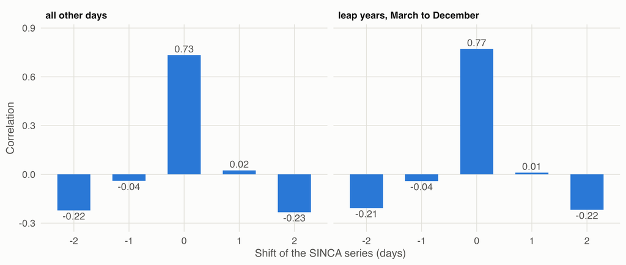

Figure 1: Correlation between day-to-day changes of CR2MET maximum temperature and SINCA station temperature, by shift of the SINCA series.

```r
lags <- read_table("temporal_alignment_lags.csv")
ggplot(lags, aes(factor(shift_days), correlation)) +
  geom_col(width = 0.6, fill = colour_method[["IDW"]]) +
  geom_text(aes(label = sprintf("%.2f", correlation), vjust = ifelse(correlation >= 0, -0.4, 1.3)),
            colour = ink$secondary, size = 3.2) +
  facet_wrap(~period) +
  scale_y_continuous(expand = expansion(mult = c(0.12, 0.15))) +
  labs(x = "Shift of the SINCA series (days)", y = "Correlation")
```

```r
kable(dcast(lags, period ~ shift_days, value.var = "correlation"), digits = 3)
```

Table 7: Values behind the figure.

| period | -2 | -1 | 0 | 1 | 2 |
| --- | --- | --- | --- | --- | --- |
| all other days | -0.222 | -0.040 | 0.733 | 0.024 | -0.233 |
| leap years, March to December | -0.208 | -0.041 | 0.772 | 0.011 | -0.218 |

The correlation peaks at a shift of zero in both periods: CR2MET dates are calendar dates and the only difference is the missing 29 February.

## 2.4 Temperature thresholds

*Script: `Code/10_exposure_temperature.R`. Table: `Output/Tables/temperature_thresholds.csv`.*

Percentiles of the daily maximum temperature of each municipality over 1990-2020. The reference code computes them over all days of the year (`percentile_season: all_year`, the value in use); the table also gives the thresholds that the warm-season days alone would produce.

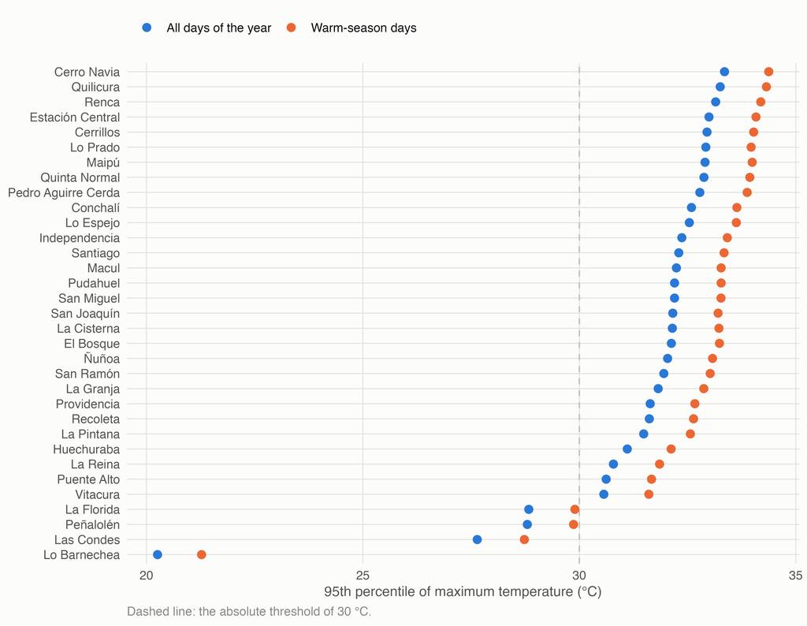

Figure 2: 95th percentile of daily maximum temperature by municipality, reference period 1990-2020, under the two season rules.

```r
thresholds <- read_table("temperature_thresholds.csv")
thresholds[, rule := fifelse(season_rule == "all_year", "All days of the year", "Warm-season days")]
order_mun <- thresholds[season_rule == "all_year"][order(p95), municipality]
ggplot(thresholds, aes(p95, factor(municipality, levels = order_mun), colour = rule)) +
  geom_vline(xintercept = get_param("temperature", "absolute_threshold_celsius"),
             colour = ink$axis, linetype = "dashed") +
  geom_point(size = 2.4) +
  scale_colour_manual(values = c("All days of the year" = "#2a78d6", "Warm-season days" = "#eb6834")) +
  labs(x = "95th percentile of maximum temperature (°C)", y = NULL, colour = NULL,
       caption = "Dashed line: the absolute threshold of 30 °C.")
```

```r
wide <- dcast(thresholds, com + municipality ~ season_rule, value.var = c("p90", "p95", "p99"))
kable(wide[order(com)], digits = 1,
      col.names = c("Code", "Municipality", "P90 all year", "P90 warm", "P95 all year",
                    "P95 warm", "P99 all year", "P99 warm"))
```

Table 8: Thresholds of maximum temperature by municipality (°C).

| Code | Municipality | P90 all year | P90 warm | P95 all year | P95 warm | P99 all year | P99 warm |
| --- | --- | --- | --- | --- | --- | --- | --- |
| 13101 | Santiago | 31.3 | 32.5 | 32.3 | 33.3 | 34.1 | 34.8 |
| 13102 | Cerrillos | 31.9 | 33.1 | 32.9 | 34.0 | 34.8 | 35.5 |
| 13103 | Cerro Navia | 32.3 | 33.5 | 33.4 | 34.4 | 35.2 | 35.9 |
| 13104 | Conchalí | 31.6 | 32.8 | 32.6 | 33.6 | 34.4 | 35.1 |
| 13105 | El Bosque | 31.1 | 32.4 | 32.1 | 33.2 | 34.0 | 34.7 |
| 13106 | Estación Central | 32.0 | 33.2 | 33.0 | 34.1 | 34.9 | 35.6 |
| 13107 | Huechuraba | 30.1 | 31.3 | 31.1 | 32.1 | 32.9 | 33.6 |
| 13108 | Independencia | 31.4 | 32.6 | 32.4 | 33.4 | 34.2 | 34.9 |
| 13109 | La Cisterna | 31.1 | 32.4 | 32.1 | 33.2 | 34.0 | 34.7 |
| 13110 | La Florida | 27.8 | 29.1 | 28.8 | 29.9 | 30.7 | 31.5 |
| 13111 | La Granja | 30.8 | 32.0 | 31.8 | 32.9 | 33.7 | 34.4 |
| 13112 | La Pintana | 30.4 | 31.7 | 31.5 | 32.6 | 33.4 | 34.0 |
| 13113 | La Reina | 29.8 | 31.0 | 30.8 | 31.9 | 32.6 | 33.4 |
| 13114 | Las Condes | 26.7 | 27.9 | 27.6 | 28.7 | 29.4 | 30.2 |
| 13115 | Lo Barnechea | 19.2 | 20.5 | 20.3 | 21.3 | 22.0 | 22.8 |
| 13116 | Lo Espejo | 31.5 | 32.8 | 32.5 | 33.6 | 34.4 | 35.1 |
| 13117 | Lo Prado | 31.9 | 33.1 | 32.9 | 34.0 | 34.7 | 35.5 |
| 13118 | Macul | 31.2 | 32.5 | 32.2 | 33.3 | 34.1 | 34.8 |
| 13119 | Maipú | 31.9 | 33.1 | 32.9 | 34.0 | 34.7 | 35.5 |
| 13120 | Ñuñoa | 31.0 | 32.3 | 32.0 | 33.1 | 33.8 | 34.6 |
| 13121 | Pedro Aguirre Cerda | 31.8 | 33.0 | 32.8 | 33.9 | 34.7 | 35.3 |
| 13122 | Peñalolén | 27.8 | 29.0 | 28.8 | 29.9 | 30.7 | 31.4 |
| 13123 | Providencia | 30.7 | 31.9 | 31.6 | 32.7 | 33.4 | 34.2 |
| 13124 | Pudahuel | 31.2 | 32.4 | 32.2 | 33.3 | 34.0 | 34.8 |
| 13125 | Quilicura | 32.3 | 33.5 | 33.3 | 34.3 | 35.1 | 35.8 |
| 13126 | Quinta Normal | 31.9 | 33.1 | 32.9 | 33.9 | 34.7 | 35.4 |
| 13127 | Recoleta | 30.6 | 31.8 | 31.6 | 32.6 | 33.4 | 34.1 |
| 13128 | Renca | 32.1 | 33.4 | 33.1 | 34.2 | 35.0 | 35.7 |
| 13129 | San Joaquín | 31.1 | 32.4 | 32.2 | 33.2 | 34.0 | 34.7 |
| 13130 | San Miguel | 31.2 | 32.4 | 32.2 | 33.3 | 34.1 | 34.7 |
| 13131 | San Ramón | 30.9 | 32.2 | 32.0 | 33.0 | 33.8 | 34.5 |
| 13132 | Vitacura | 29.6 | 30.8 | 30.6 | 31.6 | 32.3 | 33.1 |
| 13201 | Puente Alto | 29.6 | 30.8 | 30.6 | 31.7 | 32.5 | 33.3 |

The CR2MET municipal values describe the whole territory of the municipality (Temperature). Municipalities that reach into the Andes are therefore colder than their urban area: the 95th percentile ranges from 20.3 °C (Lo Barnechea) to 33.4 °C (Cerro Navia). A fixed threshold of 30 °C means very different things across municipalities, while the percentile thresholds adapt to each one.

## 2.5 Heatwave indicators

*Script: `Code/10_exposure_temperature.R` builds the indicators. The table and the figure are computed in this page from the exposure dataset (`Code/13_exposure_merge_qc.R`).*

A day is a heatwave day when it is at least the n-th consecutive day above the threshold (n = 2, 3, 4), or when the excess heat factor of the last n days is positive. The first n − 1 days of a hot spell are not flagged, as in the reference code. The formulas are in Heatwave definitions.

```r
hw_columns <- grep("^hw_", names(analysis), value = TRUE)
hw_table <- rbindlist(lapply(hw_columns, function(v) {
  per_mun <- analysis[, .(days = sum(get(v))), by = com]
  data.table(indicator = v, municipality_days = sum(per_mun$days),
             share_pct = 100 * sum(per_mun$days) / nrow(analysis),
             per_municipality_year = mean(per_mun$days) / 12,
             min_municipality = min(per_mun$days), max_municipality = max(per_mun$days))
}))
kable(hw_table, digits = c(0, 0, 1, 1, 0, 0), format.args = list(big.mark = ","),
      col.names = c("Indicator", "Municipality-days", "% of days", "Days per municipality and year",
                    "Fewest in a municipality (12 years)", "Most in a municipality (12 years)"))
```

Table 9: Heatwave days in the warm seasons of 2009-2020 under the 15 definitions.

| Indicator | Municipality-days | % of days | Days per municipality and year | Fewest in a municipality (12 years) | Most in a municipality (12 years) |
| --- | --- | --- | --- | --- | --- |
| hw_p90_2d | 10,820 | 18.1 | 27.3 | 309 | 362 |
| hw_p90_3d | 6,850 | 11.4 | 17.3 | 184 | 253 |
| hw_p90_4d | 4,929 | 8.2 | 12.4 | 124 | 195 |
| hw_p95_2d | 4,884 | 8.2 | 12.3 | 130 | 185 |
| hw_p95_3d | 2,635 | 4.4 | 6.7 | 62 | 123 |
| hw_p95_4d | 1,520 | 2.5 | 3.8 | 28 | 90 |
| hw_p99_2d | 670 | 1.1 | 1.7 | 14 | 37 |
| hw_p99_3d | 273 | 0.5 | 0.7 | 4 | 20 |
| hw_p99_4d | 109 | 0.2 | 0.3 | 1 | 10 |
| hw_30c_2d | 18,741 | 31.3 | 47.3 | 0 | 957 |
| hw_30c_3d | 14,098 | 23.5 | 35.6 | 0 | 788 |
| hw_30c_4d | 11,255 | 18.8 | 28.4 | 0 | 670 |
| hw_ehf_2d | 9,681 | 16.2 | 24.4 | 280 | 307 |
| hw_ehf_3d | 8,989 | 15.0 | 22.7 | 255 | 285 |
| hw_ehf_4d | 8,254 | 13.8 | 20.8 | 226 | 273 |

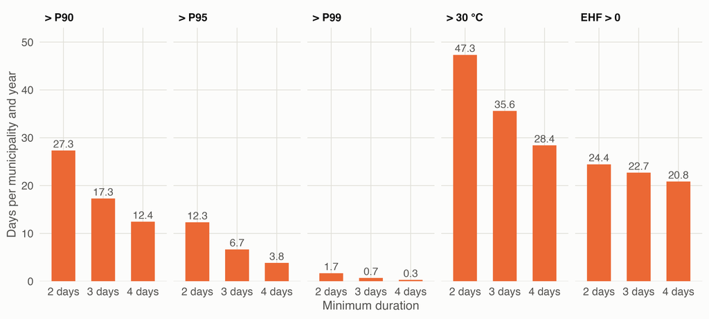

Figure 3: Heatwave days per municipality and year, by threshold and minimum duration.

```r
hw_table[, threshold := factor(sub("^hw_(.*)_[0-9]d$", "\\1", indicator),
                               levels = c("p90", "p95", "p99", "30c", "ehf"),
                               labels = c("> P90", "> P95", "> P99", "> 30 °C", "EHF > 0"))]
hw_table[, duration := paste0(sub(".*_([0-9])d$", "\\1", indicator), " days")]
ggplot(hw_table, aes(duration, per_municipality_year)) +
  geom_col(width = 0.6, fill = ramp_orange[4]) +
  geom_text(aes(label = sprintf("%.1f", per_municipality_year)), vjust = -0.4,
            colour = ink$secondary, size = 3) +
  facet_wrap(~threshold, nrow = 1) +
  scale_y_continuous(expand = expansion(mult = c(0, 0.12))) +
  labs(x = "Minimum duration", y = "Days per municipality and year")
```

### 2.5.1 Consecutive days must be counted within each municipality

*Computed in this page from the CR2MET file and the thresholds of `Code/10_exposure_temperature.R`.*

The reference script (`HeatWave_PretermBirth_Chile`, `Code/2.0 HW_process_data.R`) builds the indicators with `lag()` on a table that holds all municipalities stacked and sorted by date. As published, the previous row of a municipality is therefore another municipality on the same day, not the same municipality on the previous day. The chunk below applies that logic and the within-municipality logic to the same temperatures and thresholds.

```r
# All municipalities of the Metropolitan Region, in the column order of the file
raw <- fread(input_path("cr2met_tmax"), header = FALSE)
file_codes <- as.integer(unlist(raw[1, -(1:3)]))
rm_codes <- file_codes[file_codes >= 13000 & file_codes < 14000]
stacked <- read_cr2met(input_path("cr2met_tmax"), "tmax", rm_codes)
stacked[, file_order := match(com, rm_codes)]
p95 <- thresholds[season_rule == get_param("temperature", "percentile_season"), .(com, p95)]
stacked <- merge(stacked, p95, by = "com", all.x = TRUE)
stacked[, hot := as.integer(tmax > p95)]

# As published: rows sorted by date, municipalities stacked, lag over rows
setorder(stacked, date, file_order)
for (n in 2:4) {
  stacked[, (paste0("rows_", n, "d")) := as.integer(Reduce(`+`, shift(hot, 0:(n - 1))) >= n)]
}
# Within municipality, over consecutive calendar rows of the file
setorder(stacked, com, date)
for (n in 2:4) {
  stacked[, (paste0("within_", n, "d")) := as.integer(Reduce(`+`, shift(hot, 0:(n - 1))) >= n),
          by = com]
}
compare <- stacked[com %in% study_municipalities()$code & year(date) %in% 2009:2020 &
                     month(date) %in% get_param("study", "warm_season_months")]
for (v in grep("^(rows|within)_", names(compare), value = TRUE)) {
  set(compare, which(is.na(compare[[v]])), v, 0L)
}
lag_compare <- rbindlist(lapply(2:4, function(n) {
  a <- compare[[paste0("rows_", n, "d")]]
  b <- compare[[paste0("within_", n, "d")]]
  data.table(duration = paste(n, "days"), hot_days = sum(compare$hot),
             stacked_rows = sum(a), within_municipality = sum(b),
             flagged_only_by_stacked = sum(a == 1 & b == 0),
             flagged_only_within = sum(a == 0 & b == 1))
}))
kable(lag_compare, format.args = list(big.mark = ","),
      col.names = c("Minimum duration", "Days above P95", "Lag over stacked rows",
                    "Lag within municipality", "Flagged only by stacked rows",
                    "Flagged only within municipality"))
```

Table 10: Heatwave days (> P95) in the 33 municipalities, warm seasons 2009-2020: lag over stacked rows against lag within municipality.

| Minimum duration | Days above P95 | Lag over stacked rows | Lag within municipality | Flagged only by stacked rows | Flagged only within municipality |
| --- | --- | --- | --- | --- | --- |
| 2 days | 9,809 | 8,364 | 4,851 | 4,216 | 703 |
| 3 days | 9,809 | 7,823 | 2,602 | 5,760 | 539 |
| 4 days | 9,809 | 7,364 | 1,487 | 6,283 | 406 |

With the stacked-row lag, a single hot day is flagged as a heatwave whenever the neighbouring municipalities in the file are also hot that day, so the number of heatwave days barely falls as the required duration grows. Counting within each municipality gives the indicators used in this project. The published indicators of the reference repository should be checked against this before they are reused.

### 2.5.2 Why the number of heatwave days differs between municipalities

*Computed in this page from the exposure dataset (`Code/13_exposure_merge_qc.R`), the thresholds of `Code/10_exposure_temperature.R`, the header of the CR2MET file and the target points of the interpolation. The indicator is computed again here with `consecutive_flag()` and has to equal the one of the dataset.*

The threshold is a percentile of each municipality, so the number of days above it is nearly the same everywhere. The number of heatwave days is not. The table takes the indicators of the 95th percentile apart, municipality by municipality.

```r
main_rule <- get_param("temperature", "percentile_season")
other_rule <- setdiff(c("all_year", "warm_season"), main_rule)
rule_label <- c(all_year = "all the days of the year", warm_season = "the warm-season days")

# Hot spells: runs of consecutive days above the threshold, on the complete
# calendar of each municipality
calendar <- exposure[order(com, date), .(com, municipality, date, in_study_period, warm_season,
                                         tmax, hot_p95, hw_p95_2d, hw_p95_3d, hw_p95_4d)]
stopifnot(calendar[, all(diff(date) == 1), by = com]$V1)
calendar[, spell := rleid(hot_p95), by = com]
calendar[, change := tmax - shift(tmax), by = com]
# The indicator of the dataset is what the definition says
calendar[, check_2d := consecutive_flag(hot_p95, 2), by = com]
stopifnot(calendar[!is.na(check_2d), all(check_2d == hw_p95_2d)])
# The same count with the thresholds of the other season rule
calendar <- merge(calendar, thresholds[season_rule == other_rule, .(com, p95_other = p95)], by = "com")
setorder(calendar, com, date)
calendar[, hw_other_2d := consecutive_flag(as.integer(tmax > p95_other), 2), by = com]
season_days <- calendar[in_study_period == TRUE & warm_season == TRUE]
spells <- season_days[hot_p95 == 1, .(days = .N, first = min(date), last = max(date)),
                      by = .(com, spell)]

# Territory behind the temperature series, and distance from its centre to the
# point where ozone is interpolated. The header of the CR2MET file gives the
# code, the latitude, the longitude (to 0.01 degrees, about 1 km) and the area
# of each municipality.
cr2met_header <- fread(input_path("cr2met_tmax"), header = FALSE, nrows = 4)
territory <- data.table(com = as.integer(unlist(cr2met_header[1, -(1:3)])),
                        latitude = as.numeric(unlist(cr2met_header[2, -(1:3)])),
                        longitude = as.numeric(unlist(cr2met_header[3, -(1:3)])),
                        area_km2 = as.numeric(unlist(cr2met_header[4, -(1:3)])))
territory <- merge(study_municipalities()[, .(com = code, municipality = name)], territory, by = "com")
ozone_points <- new.env()
load(input_path("interpolation_locations"), envir = ozone_points)
ozone_points <- ozone_points$interpol
stopifnot(setequal(ozone_points$comuna, territory$municipality))
centres <- sf::st_transform(sf::st_as_sf(territory, coords = c("longitude", "latitude"), crs = 4326),
                            sf::st_crs(ozone_points))
territory[, distance_km := as.numeric(sf::st_distance(
  centres, ozone_points[match(municipality, ozone_points$comuna), ], by_element = TRUE)) / 1000]

by_municipality <- Reduce(function(a, b) merge(a, b, by = "com"), list(
  season_days[, .(tmax = mean(tmax), hot_days = sum(hot_p95), hw_2d = sum(hw_p95_2d),
                  hw_3d = sum(hw_p95_3d), hw_4d = sum(hw_p95_4d), hw_other_2d = sum(hw_other_2d),
                  sd_change = sd(change)), by = .(com, municipality)],
  spells[, .(spells = .N, mean_length = mean(days), longest = max(days)), by = com],
  thresholds[season_rule == main_rule, .(com, p95)],
  territory[, .(com, area_km2, distance_km)]))
stopifnot(nrow(by_municipality) == n_mun, !anyNA(by_municipality))
setorder(by_municipality, -hw_2d)
most <- by_municipality[1]
fewest <- by_municipality[.N]
longest_spell <- spells[com == most$com][which.max(days)]
others <- by_municipality[com != most$com]
# Series more than 2 °C colder than the median municipality
colder <- by_municipality[com != most$com & tmax < median(tmax) - 2][order(tmax), municipality]
# Quoted in "Points to settle", at the end of the page
andes_point <- sprintf(
  "In %s it is %s °C colder than in the median municipality and gives the most heatwave days of the 33: %d, against %d to %d in the others",
  most$municipality, fmt(median(by_municipality$tmax) - most$tmax, 1), most$hw_2d,
  min(others$hw_2d), max(others$hw_2d))
```

```r
kableExtra::scroll_box(
  kableExtra::kable_styling(
    kable(by_municipality[, .(municipality, area_km2, distance_km, tmax, p95, hot_days, spells,
                              mean_length, longest, hw_2d, hw_3d, hw_4d, hw_other_2d, sd_change)],
          format = "html", digits = c(0, 1, 1, 1, 1, 0, 0, 2, 0, 0, 0, 0, 0, 2),
          format.args = list(big.mark = ","),
          col.names = c("Municipality", "Territory of the temperature series (km²)",
                        "From its centre to the ozone point (km)", "Mean maximum temperature (°C)",
                        "95th percentile (°C)", "Days above the 95th percentile", "Hot spells",
                        "Mean length of the spells (days)", "Longest spell (days)",
                        "Heatwave days, 2 days or more", "3 days or more", "4 days or more",
                        paste("2 days or more, threshold from", rule_label[[other_rule]]),
                        "SD of the day-to-day change of temperature (°C)")),
    bootstrap_options = c("striped", "condensed"), font_size = 12),
  height = "420px"
)
```

Table 11: Days above the 95th percentile and heatwave days by municipality, warm seasons 2009-2020, with the territory behind each temperature series. Municipalities in order of heatwave days.

| Municipality | Territory of the temperature series (km²) | From its centre to the ozone point (km) | Mean maximum temperature (°C) | 95th percentile (°C) | Days above the 95th percentile | Hot spells | Mean length of the spells (days) | Longest spell (days) | Heatwave days, 2 days or more | 3 days or more | 4 days or more | 2 days or more, threshold from the warm-season days | SD of the day-to-day change of temperature (°C) |
| --- | --- | --- | --- | --- | --- | --- | --- | --- | --- | --- | --- | --- | --- |
| Lo Barnechea | 1,021.0 | 13.5 | 17.6 | 20.3 | 309 | 124 | 2.49 | 20 | 185 | 123 | 90 | 84 | 2.26 |
| Las Condes | 99.1 | 8.8 | 25.0 | 27.6 | 317 | 134 | 2.37 | 13 | 183 | 115 | 77 | 71 | 2.47 |
| La Reina | 22.7 | 1.8 | 28.1 | 30.8 | 306 | 138 | 2.22 | 12 | 168 | 101 | 67 | 62 | 2.47 |
| La Florida | 71.1 | 8.9 | 26.1 | 28.8 | 307 | 140 | 2.19 | 12 | 167 | 101 | 67 | 62 | 2.57 |
| Peñalolén | 55.7 | 4.2 | 26.1 | 28.8 | 306 | 139 | 2.20 | 12 | 167 | 101 | 66 | 65 | 2.51 |
| Vitacura | 28.9 | 3.5 | 27.9 | 30.6 | 304 | 141 | 2.16 | 12 | 163 | 97 | 62 | 58 | 2.47 |
| Puente Alto | 87.5 | 2.8 | 27.8 | 30.6 | 307 | 145 | 2.12 | 12 | 162 | 96 | 63 | 63 | 2.61 |
| Huechuraba | 44.4 | 1.8 | 28.4 | 31.1 | 303 | 145 | 2.09 | 12 | 158 | 90 | 55 | 60 | 2.54 |
| Ñuñoa | 13.4 | 0.9 | 29.3 | 32.0 | 300 | 144 | 2.08 | 10 | 156 | 89 | 56 | 56 | 2.55 |
| Macul | 14.4 | 0.8 | 29.5 | 32.2 | 298 | 146 | 2.04 | 10 | 152 | 85 | 51 | 56 | 2.59 |
| Providencia | 15.5 | 0.2 | 28.9 | 31.6 | 299 | 147 | 2.03 | 10 | 152 | 84 | 50 | 58 | 2.55 |
| Recoleta | 16.5 | 1.1 | 28.9 | 31.6 | 299 | 147 | 2.03 | 10 | 152 | 84 | 49 | 60 | 2.56 |
| La Granja | 10.3 | 1.9 | 29.0 | 31.8 | 297 | 148 | 2.01 | 10 | 149 | 81 | 47 | 56 | 2.67 |
| San Joaquín | 11.3 | 2.6 | 29.3 | 32.2 | 296 | 149 | 1.99 | 10 | 147 | 80 | 46 | 56 | 2.64 |
| Conchalí | 10.3 | 1.8 | 29.9 | 32.6 | 297 | 151 | 1.97 | 9 | 146 | 77 | 41 | 61 | 2.57 |
| La Pintana | 29.9 | 1.3 | 28.7 | 31.5 | 298 | 152 | 1.96 | 10 | 146 | 78 | 45 | 56 | 2.71 |
| Quilicura | 55.8 | 1.0 | 30.6 | 33.3 | 301 | 155 | 1.94 | 9 | 146 | 72 | 36 | 58 | 2.58 |
| Pudahuel | 201.2 | 8.1 | 29.5 | 32.2 | 297 | 152 | 1.95 | 9 | 145 | 72 | 38 | 61 | 2.59 |
| Independencia | 7.2 | 0.5 | 29.6 | 32.4 | 295 | 151 | 1.95 | 9 | 144 | 77 | 42 | 60 | 2.58 |
| Santiago | 22.7 | 1.7 | 29.5 | 32.3 | 292 | 149 | 1.96 | 9 | 143 | 76 | 42 | 58 | 2.60 |
| San Ramón | 7.2 | 0.5 | 29.1 | 32.0 | 297 | 154 | 1.93 | 9 | 143 | 70 | 36 | 57 | 2.69 |
| San Miguel | 9.3 | 1.6 | 29.4 | 32.2 | 291 | 153 | 1.90 | 9 | 138 | 68 | 36 | 58 | 2.64 |
| La Cisterna | 9.3 | 0.6 | 29.4 | 32.1 | 295 | 158 | 1.87 | 9 | 137 | 67 | 34 | 54 | 2.68 |
| Renca | 23.7 | 1.6 | 30.4 | 33.1 | 294 | 157 | 1.87 | 9 | 137 | 68 | 34 | 59 | 2.60 |
| Cerro Navia | 13.4 | 2.5 | 30.6 | 33.4 | 293 | 158 | 1.85 | 9 | 135 | 66 | 33 | 56 | 2.61 |
| El Bosque | 14.4 | 1.4 | 29.3 | 32.1 | 295 | 160 | 1.84 | 9 | 135 | 66 | 34 | 54 | 2.71 |
| Pedro Aguirre Cerda | 8.2 | 1.5 | 30.0 | 32.8 | 295 | 160 | 1.84 | 9 | 135 | 66 | 34 | 54 | 2.67 |
| Lo Prado | 5.2 | 0.3 | 30.2 | 32.9 | 293 | 159 | 1.84 | 9 | 134 | 66 | 33 | 54 | 2.61 |
| Quinta Normal | 13.4 | 2.2 | 30.2 | 32.9 | 291 | 157 | 1.85 | 9 | 134 | 67 | 34 | 58 | 2.60 |
| Estación Central | 14.4 | 2.0 | 30.3 | 33.0 | 292 | 159 | 1.84 | 9 | 133 | 65 | 33 | 55 | 2.64 |
| Cerrillos | 15.5 | 0.7 | 30.2 | 32.9 | 293 | 162 | 1.81 | 9 | 131 | 62 | 30 | 54 | 2.66 |
| Lo Espejo | 9.3 | 0.8 | 29.8 | 32.5 | 294 | 163 | 1.80 | 9 | 131 | 63 | 31 | 54 | 2.68 |
| Maipú | 136.1 | 5.9 | 30.1 | 32.9 | 291 | 161 | 1.81 | 9 | 130 | 62 | 28 | 50 | 2.64 |

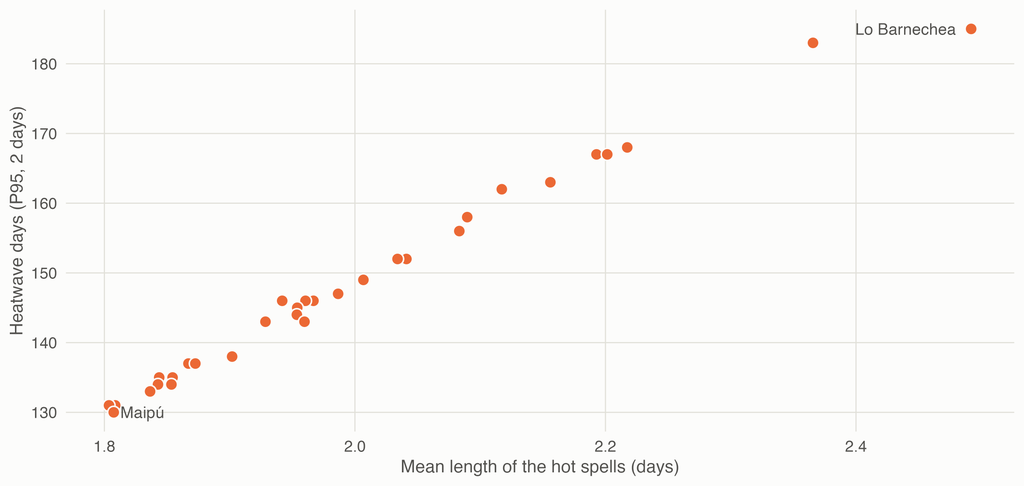

Figure 4: Heatwave days of each municipality against the mean length of its hot spells, warm seasons 2009-2020. One point per municipality.

```r
labelled <- by_municipality[com %in% c(most$com, fewest$com)]
ggplot(by_municipality, aes(mean_length, hw_2d)) +
  geom_point(shape = 21, size = 2.8, fill = ramp_orange[4], colour = ink$surface, stroke = 0.6) +
  geom_text(data = labelled, aes(label = municipality), colour = ink$secondary, size = 3.2,
            hjust = ifelse(labelled$com == most$com, 1.15, -0.15)) +
  labs(x = "Mean length of the hot spells (days)",
       y = sprintf("Heatwave days (%s)", heatwave_label("hw_p95_2d")))
```

- **The days above the threshold are almost the same.** Between 291 and 317 of the 1,815 days of analysis, in every municipality.
- **Their grouping is not.** A spell of five hot days has four heatwave days under the two-day definition, and five single hot days have none: hot days that come in fewer and longer spells give more heatwave days. Lo Barnechea has 309 hot days in 124 spells, 2.49 days long on average; the longest lasted 20 days, from 2019-01-21 to 2019-02-09. Maipú has 291 hot days in 161 spells of 1.81 days, none longer than 9 days. Across the 33 municipalities, the heatwave days and the mean length of the spells have a correlation of 0.99.
- **The difference grows with the duration.** With two days or more: 185 heatwave days in Lo Barnechea against 130 in Maipú; with four or more: 90 against 28.
- **It does not come from the season of the percentile.** With the threshold from the warm-season days the heatwave days are between 50 and 84, and Lo Barnechea still has the most.

**Why Lo Barnechea.** Its series is the coldest by far (mean maximum 17.6 °C, against 25.0 to 30.6 °C in the others) and the one that changes least from one day to the next: the standard deviation of the day-to-day change is 2.26 °C, against 2.47 to 2.71 °C. A hot day is therefore followed more often by another hot day. The series describes a territory of 1,021 km², 5 times the next largest, and the point where the ozone of the municipality is interpolated is 13.5 km from the centre of that territory (the median of the 33 municipalities is 1.7 km). The reading that follows is an interpretation, not a result: a value for a large mountain territory follows the slow changes of the air mass, and misses the day-to-day changes of the valley floor, where the people of the municipality live.

**What it means for the analysis.** Within a municipality the indicator is consistent: it marks the days that are hot for that series, and the health analysis compares days of the same municipality. What is not assured is that a heatwave day of the series is a heatwave day where people live. This concerns Lo Barnechea above all, and to a smaller degree the other series that are more than 2 °C colder than the median municipality (Las Condes, La Florida, Peñalolén). The options are in Points to settle.

## 2.6 Ozone and co-pollutants: delivered series

*Script: `Code/11_exposure_air_pollution.R`. Table: `Output/Tables/air_pollution_qc.csv`. The other tables and the figure are computed in this page from the exposure dataset and from `Data/Derived/exposure_air_pollution_all.csv`. How the series were built: The delivered series.*

```r
pollution_qc <- read_table("air_pollution_qc.csv")
kable(pollution_qc, format.args = list(big.mark = ","),
      col.names = c("Version", "Variable", "Method", "Rows", "Missing as delivered",
                    "Below zero, set to missing", "Fewer stations than the minimum, set to missing"))
```

Table 12: Quality rules applied to the delivered interpolated series, all days of the dataset.

| Version | Variable | Method | Rows | Missing as delivered | Below zero, set to missing | Fewer stations than the minimum, set to missing |
| --- | --- | --- | --- | --- | --- | --- |
| opr | o3 | idw | 144,738 | 0 | 0 | 0 |
| opr | o3 | ok | 144,738 | 0 | 40 | 0 |
| opr | pm25 | idw | 144,738 | 0 | 0 | 0 |
| opr | pm25 | ok | 144,738 | 0 | 5 | 0 |
| opr | no2 | idw | 144,738 | 26 | 0 | 0 |
| opr | no2 | ok | 144,738 | 0 | 3 | 0 |
| opr | hum | idw | 144,738 | 0 | 0 | 0 |
| opr | hum | ok | 144,738 | 0 | 0 | 0 |
| all | o3 | idw | 144,738 | 0 | 0 | 0 |
| all | o3 | ok | 144,738 | 0 | 20 | 0 |
| all | pm25 | idw | 144,738 | 0 | 0 | 0 |
| all | pm25 | ok | 144,738 | 0 | 1 | 0 |
| all | no2 | idw | 144,738 | 0 | 0 | 0 |
| all | no2 | ok | 144,738 | 0 | 1 | 0 |
| all | hum | idw | 144,738 | 0 | 0 | 0 |
| all | hum | ok | 144,738 | 0 | 0 | 0 |

```r
variables <- c(o3 = "Ozone, 24-hour mean (ppb)", pm25 = "PM2.5 (µg/m³)",
               no2 = "Nitrogen dioxide (ppb)", hum = "Relative humidity (%)")
pollution_summary <- rbindlist(lapply(names(variables), function(v) {
  idw <- analysis[[paste0(v, "_idw")]]
  ok <- analysis[[paste0(v, "_ok")]]
  st <- analysis[[paste0(v, "_n_stations")]]
  data.table(variable = variables[[v]], idw_mean = mean(idw, na.rm = TRUE),
             ok_mean = mean(ok, na.rm = TRUE), idw_missing = sum(is.na(idw)),
             ok_missing = sum(is.na(ok)), stations = sprintf("%d to %d", min(st), max(st)),
             correlation = cor(idw, ok, use = "complete.obs"),
             mean_abs_difference = mean(abs(idw - ok), na.rm = TRUE))
}))
kable(pollution_summary, digits = 2, format.args = list(big.mark = ","),
      col.names = c("Variable", "Mean, IDW", "Mean, kriging", "Missing, IDW", "Missing, kriging",
                    "Stations per day", "Correlation IDW-kriging", "Mean absolute difference"))
```

Table 13: Delivered series in the warm seasons of 2009-2020: distribution, stations and agreement between the two interpolation methods.

| Variable | Mean, IDW | Mean, kriging | Missing, IDW | Missing, kriging | Stations per day | Correlation IDW-kriging | Mean absolute difference |
| --- | --- | --- | --- | --- | --- | --- | --- |
| Ozone, 24-hour mean (ppb) | 19.90 | 20.08 | 0 | 10 | 8 to 11 | 0.90 | 1.25 |
| PM2.5 (µg/m³) | 18.67 | 18.30 | 0 | 1 | 10 to 11 | 0.97 | 1.13 |
| Nitrogen dioxide (ppb) | 16.05 | 14.79 | 23 | 1 | 3 to 11 | 0.92 | 1.93 |
| Relative humidity (%) | 50.51 | 51.34 | 0 | 0 | 9 to 11 | 0.98 | 1.62 |

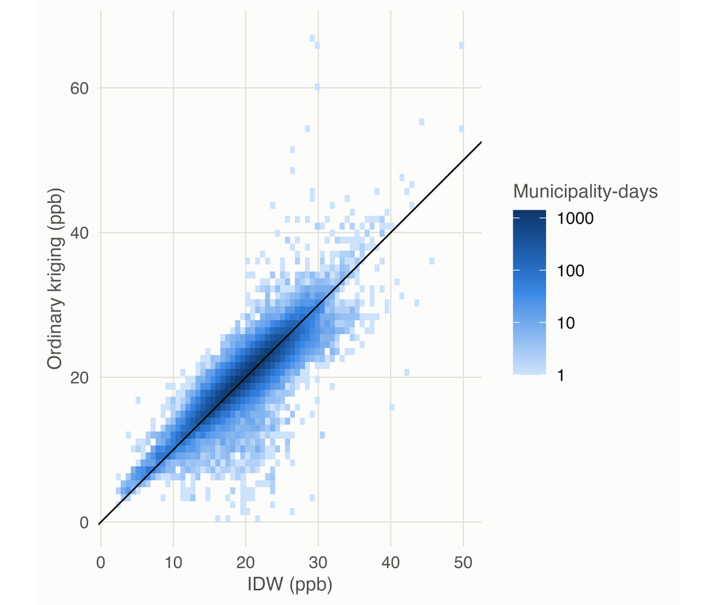

Figure 5: Ozone by ordinary kriging against ozone by IDW, delivered series, municipality-days of the warm seasons 2009-2020.

```r
ggplot(analysis[!is.na(o3_ok)], aes(o3_idw, o3_ok)) +
  geom_bin2d(bins = 70) +
  geom_abline(colour = ink$primary, linewidth = 0.4) +
  scale_fill_magnitude(name = "Municipality-days", trans = "log10") +
  coord_equal() +
  labs(x = "IDW (ppb)", y = "Ordinary kriging (ppb)") +
  theme(legend.position = "right", legend.justification = "center")
```

### 2.6.1 Version `opr` against version `all`

```r
all_version <- fread(derived_path("exposure_air_pollution_all.csv"), encoding = "UTF-8",
                     select = c("com", "date", "o3_idw", "o3_ok", "o3_n_stations"))
all_version[, date := as.Date(date)]
versions <- merge(analysis[, .(com, date, o3_idw, o3_ok, o3_n_stations)], all_version,
                  by = c("com", "date"), suffixes = c("_opr", "_all"))
version_table <- rbindlist(lapply(c("idw", "ok"), function(m) {
  a <- versions[[paste0("o3_", m, "_opr")]]
  b <- versions[[paste0("o3_", m, "_all")]]
  data.table(method = m, municipality_days = sum(!is.na(a) & !is.na(b)),
             identical_pct = 100 * mean(abs(a - b) < 1e-6, na.rm = TRUE),
             correlation = cor(a, b, use = "complete.obs"),
             mean_difference = mean(b - a, na.rm = TRUE),
             p95_abs_difference = quantile(abs(b - a), 0.95, na.rm = TRUE))
}))
kable(version_table, digits = c(0, 0, 1, 3, 2, 2), format.args = list(big.mark = ","),
      col.names = c("Method", "Municipality-days", "Identical (%)", "Correlation",
                    "Mean difference, all − opr (ppb)", "95th percentile of absolute difference (ppb)"))
```

Table 14: Ozone in the two delivered versions, warm seasons 2009-2020.

| Method | Municipality-days | Identical (%) | Correlation | Mean difference, all − opr (ppb) | 95th percentile of absolute difference (ppb) |
| --- | --- | --- | --- | --- | --- |
| idw | 59,895 | 74 | 0.988 | 0.02 | 0.74 |
| ok | 59,885 | 62 | 0.955 | -0.04 | 2.32 |

```r
station_counts <- rbind(
  versions[, .(version = "opr", stations = o3_n_stations_opr)],
  versions[, .(version = "all", stations = o3_n_stations_all)]
)[, .(n = .N), by = .(version, stations)]
station_counts[, share := 100 * n / sum(n), by = version]
kable(dcast(station_counts, stations ~ version, value.var = "share", fill = 0), digits = 1,
      col.names = c("Stations", "all", "opr"))
```

Table 15: Stations behind the ozone value, by version (share of municipality-days, %).

| Stations | all | opr |
| --- | --- | --- |
| 8 | 0 | 8.3 |
| 9 | 0 | 25.7 |
| 10 | 0 | 4.0 |
| 11 | 100 | 62.0 |

## 2.7 Ozone rebuilt from the hourly records

*Script: `Code/12_ozone_station_series.R`. Tables: `Output/Tables/ozone_station_hourly_status.csv` and `ozone_rebuilt_qc.csv`.*

Script 12 rebuilds the station series from the hourly SINCA records, with no trimming and no imputation, as a 24-hour mean (`o3obs`) and as the daily maximum 8-hour mean (`o3mda8`), and interpolates them with the data author’s model and parameters. The rules are in Ozone rebuilt from the hourly records; the reasons and the comparison with the delivered series are in the validation of the ozone exposure.

```r
status <- read_table("ozone_station_hourly_status.csv")
status_cols <- setdiff(names(status), c("sinca_id", "station"))
status[, total := rowSums(.SD), .SDcols = status_cols]
status_pct <- status[, c(.(station = station, hours = total),
                         lapply(.SD, function(x) 100 * x / total)), .SDcols = status_cols]
kable(status_pct, digits = 1, format.args = list(big.mark = ","))
```

Table 16: Hourly ozone records of the study period by validation status (% of hours).

| station | hours | no_record | not_validated | preliminary | validated |
| --- | --- | --- | --- | --- | --- |
| Independencia | 105,264 | 4.5 | 0.2 | 6.6 | 88.7 |
| La Florida | 105,264 | 6.0 | 2.7 | 1.1 | 90.2 |
| Las Condes | 105,264 | 2.7 | 0.0 | 0.6 | 96.7 |
| Parque O’Higgins | 105,264 | 4.2 | 0.4 | 4.3 | 91.1 |
| Pudahuel | 105,264 | 3.7 | 0.5 | 4.3 | 91.5 |
| Cerrillos I | 105,264 | 36.5 | 0.0 | 0.0 | 63.5 |
| El Bosque | 105,264 | 3.4 | 0.5 | 2.8 | 93.3 |
| Cerro Navia | 105,264 | 6.5 | 0.1 | 0.1 | 93.3 |
| Puente Alto | 105,264 | 6.9 | 0.2 | 1.0 | 91.8 |
| Talagante | 105,264 | 11.7 | 0.4 | 0.7 | 87.2 |
| Quilicura I | 105,264 | 40.2 | 0.0 | 0.6 | 59.2 |

```r
kable(read_table("ozone_rebuilt_qc.csv"), format.args = list(big.mark = ","),
      col.names = c("Series", "Method", "Rows", "Missing", "Below zero, set to missing",
                    "Days with fewer than 3 stations", "Days with a variogram warning",
                    "Days without a fitted variogram"))
```

Table 17: Rebuilt municipal series: missing values and kriging diagnostics, all days of the dataset.

[output not shown]

# 3 Exposure dataset, 2009-2020

*Script: `Code/13_exposure_merge_qc.R`, from the datasets of scripts 10, 11 and 12. Dataset: `Data/Derived/exposure_2009_2020.csv`. Table: `Output/Tables/exposure_codebook.csv`.*

`Data/Derived/exposure_2009_2020.csv` has 144,738 rows and 78 columns. The data folders are not tracked by git; the file is rebuilt by the scripts of this deliverable.

```r
codebook <- read_table("exposure_codebook.csv")
kableExtra::scroll_box(
  kableExtra::kable_styling(kable(codebook, format = "html", format.args = list(big.mark = ","),
                                  col.names = c("Variable", "Description", "Missing")),
                            bootstrap_options = c("striped", "condensed"), font_size = 12),
  height = "420px"
)
```

Table 18: Codebook of the exposure dataset. Missing counts refer to all days of the dataset.

| Variable | Description | Missing |
| --- | --- | --- |
| com | Municipality code (INE) | 0 |
| municipality | Municipality name | 0 |
| date | Calendar day | 0 |
| year | Calendar year | 0 |
| in_study_period | Day inside the study years (FALSE for the lag buffer days) | 0 |
| warm_season | Day between 1 November and 31 March | 0 |
| tmax | Daily maximum temperature, CR2MET v2.5 (degrees C) | 0 |
| tmin | Daily minimum temperature, CR2MET v2.5 (degrees C) | 0 |
| temp_filled | Temperature absent from CR2MET (29 February), filled as configured | 0 |
| hot_p90 | Maximum temperature above the threshold in the name (1/0) | 0 |
| hot_p95 | Maximum temperature above the threshold in the name (1/0) | 0 |
| hot_p99 | Maximum temperature above the threshold in the name (1/0) | 0 |
| hot_30c | Maximum temperature above the threshold in the name (1/0) | 0 |
| hw_p90_2d | Heatwave day: at least the n-th consecutive day above the threshold (1/0) | 0 |
| hw_p90_3d | Heatwave day: at least the n-th consecutive day above the threshold (1/0) | 0 |
| hw_p90_4d | Heatwave day: at least the n-th consecutive day above the threshold (1/0) | 0 |
| hw_p95_2d | Heatwave day: at least the n-th consecutive day above the threshold (1/0) | 0 |
| hw_p95_3d | Heatwave day: at least the n-th consecutive day above the threshold (1/0) | 0 |
| hw_p95_4d | Heatwave day: at least the n-th consecutive day above the threshold (1/0) | 0 |
| hw_p99_2d | Heatwave day: at least the n-th consecutive day above the threshold (1/0) | 0 |
| hw_p99_3d | Heatwave day: at least the n-th consecutive day above the threshold (1/0) | 0 |
| hw_p99_4d | Heatwave day: at least the n-th consecutive day above the threshold (1/0) | 0 |
| hw_30c_2d | Heatwave day: at least the n-th consecutive day above the threshold (1/0) | 0 |
| hw_30c_3d | Heatwave day: at least the n-th consecutive day above the threshold (1/0) | 0 |
| hw_30c_4d | Heatwave day: at least the n-th consecutive day above the threshold (1/0) | 0 |
| tad | Daily mean temperature: (tmax + next-day tmin) / 2 (degrees C) | 0 |
| ehf_2d | Excess heat factor, window in the name (degrees C squared) | 0 |
| hw_ehf_2d | Heatwave day: excess heat factor above zero, window in the name (1/0) | 0 |
| ehf_3d | Excess heat factor, window in the name (degrees C squared) | 0 |
| hw_ehf_3d | Heatwave day: excess heat factor above zero, window in the name (1/0) | 0 |
| ehf_4d | Excess heat factor, window in the name (degrees C squared) | 0 |
| hw_ehf_4d | Heatwave day: excess heat factor above zero, window in the name (1/0) | 0 |
| o3_idw | Ozone, 24-hour mean, delivered interpolated series (ppb) | 0 |
| o3_ok | Ozone, 24-hour mean, delivered interpolated series (ppb) | 40 |
| o3_ok_var | Ordinary kriging variance | 40 |
| o3_n_stations | Stations with a value that day | 0 |
| pm25_idw | PM2.5, delivered interpolated series (ug/m3) | 0 |
| pm25_ok | PM2.5, delivered interpolated series (ug/m3) | 5 |
| pm25_ok_var | Ordinary kriging variance | 5 |
| pm25_n_stations | Stations with a value that day | 0 |
| no2_idw | Nitrogen dioxide, delivered interpolated series (ppb) | 26 |
| no2_ok | Nitrogen dioxide, delivered interpolated series (ppb) | 3 |
| no2_ok_var | Ordinary kriging variance | 3 |
| no2_n_stations | Stations with a value that day | 0 |
| hum_idw | Relative humidity, delivered interpolated series (percent) | 0 |
| hum_ok | Relative humidity, delivered interpolated series (percent) | 0 |
| hum_ok_var | Ordinary kriging variance | 0 |
| hum_n_stations | Stations with a value that day | 0 |
| o3obs_n_stations | Stations with a value that day | 0 |
| o3obs_idw | Ozone, 24-hour mean rebuilt from hourly records without trimming or imputation (ppb) | 80 |
| o3obs_ok | Ozone, 24-hour mean rebuilt from hourly records without trimming or imputation (ppb) | 84 |
| o3obs_ok_var | Ordinary kriging variance | 84 |
| o3obs_ok_warning | Variogram fit raised a warning that day | 66 |
| o3obs_ok_failed | Variogram could not be fitted that day (too few stations); kriging value missing | 66 |
| o3mda8_n_stations | Stations with a value that day | 0 |
| o3mda8_idw | Ozone, daily maximum 8-hour mean rebuilt from hourly records (ppb) | 98 |
| o3mda8_ok | Ozone, daily maximum 8-hour mean rebuilt from hourly records (ppb) | 111 |
| o3mda8_ok_var | Ordinary kriging variance | 111 |
| o3mda8_ok_warning | Variogram fit raised a warning that day | 66 |
| o3mda8_ok_failed | Variogram could not be fitted that day (too few stations); kriging value missing | 66 |
| o3_idw_gt_p50 | Ozone above the municipality percentile in the name, warm-season days of the study years (1/0) | 0 |
| o3_idw_gt_p75 | Ozone above the municipality percentile in the name, warm-season days of the study years (1/0) | 0 |
| o3_idw_gt_p90 | Ozone above the municipality percentile in the name, warm-season days of the study years (1/0) | 0 |
| o3obs_idw_gt_p50 | Ozone above the municipality percentile in the name, warm-season days of the study years (1/0) | 80 |
| o3obs_idw_gt_p75 | Ozone above the municipality percentile in the name, warm-season days of the study years (1/0) | 80 |
| o3obs_idw_gt_p90 | Ozone above the municipality percentile in the name, warm-season days of the study years (1/0) | 80 |
| o3mda8_idw_gt_p50 | Ozone above the municipality percentile in the name, warm-season days of the study years (1/0) | 98 |
| o3mda8_idw_gt_p75 | Ozone above the municipality percentile in the name, warm-season days of the study years (1/0) | 98 |
| o3mda8_idw_gt_p90 | Ozone above the municipality percentile in the name, warm-season days of the study years (1/0) | 98 |
| o3_ok_gt_p50 | Ozone above the municipality percentile in the name, warm-season days of the study years (1/0) | 40 |
| o3_ok_gt_p75 | Ozone above the municipality percentile in the name, warm-season days of the study years (1/0) | 40 |
| o3_ok_gt_p90 | Ozone above the municipality percentile in the name, warm-season days of the study years (1/0) | 40 |
| o3obs_ok_gt_p50 | Ozone above the municipality percentile in the name, warm-season days of the study years (1/0) | 84 |
| o3obs_ok_gt_p75 | Ozone above the municipality percentile in the name, warm-season days of the study years (1/0) | 84 |
| o3obs_ok_gt_p90 | Ozone above the municipality percentile in the name, warm-season days of the study years (1/0) | 84 |
| o3mda8_ok_gt_p50 | Ozone above the municipality percentile in the name, warm-season days of the study years (1/0) | 111 |
| o3mda8_ok_gt_p75 | Ozone above the municipality percentile in the name, warm-season days of the study years (1/0) | 111 |
| o3mda8_ok_gt_p90 | Ozone above the municipality percentile in the name, warm-season days of the study years (1/0) | 111 |

# 4 Validation of the ozone exposure

## 4.1 What is validated

*Scripts: `Code/12_ozone_station_series.R` (station series and rebuilt municipal series), `Code/14_interpolation_validation.R` (cross-validation predictions), `Code/16_reanalysis_comparison.R` (reanalysis) and `Code/17_validation_summary.R` (tables). Each part names its tables.*

The ozone exposure of the study is a daily value per municipality, interpolated from the monitoring stations of the SINCA network. Three things can go wrong on the way from the monitors to that value, and each is examined here:

A. **The station inputs.** Are the station series that feed the interpolation faithful to the measurements? B. **The interpolation model.** How well do inverse distance weighting (IDW) and ordinary kriging predict ozone at a place without a monitor? C. **The municipal series.** How much do the delivered series differ from series rebuilt from the measurements, in particular on high-ozone days?

A last section compares the series with an independent source, the CAMS reanalysis, which assimilates satellite ozone retrievals.

The delivered series comes from `pollution-interpolation-kriging-idw`. Its station inputs are hourly SINCA records trimmed at their 1st and 99th percentiles, averaged over the day when at least 12 hours are valid, and completed by imputation. Its interpolation uses IDW (power 2, at most 5 stations within 15 km) and ordinary kriging with a variogram fitted every day. The validation uses the hourly SINCA records as published, with the validation status of every record, for the 11 ozone stations of the Metropolitan Region.

## 4.2 A. Station inputs

*Script: `Code/17_validation_summary.R`, from `Data/Derived/ozone_station_daily.csv` (`Code/12_ozone_station_series.R`) and the station series of the data author. Tables: `Output/Tables/validation_inputs_by_station.csv` and `validation_inputs_by_level.csv`. The scatter plot is computed in this page from the same two series.*

The station series published with the interpolation code (2009-2020) are compared, station by station and day by day, with the 24-hour mean computed from the validated hourly records with the same rule of at least 12 valid hours. A station-day is *identical* when the two values agree, *modified* when both exist and differ, and has *no validated daily mean* when the author’s series holds a value that the validated records cannot produce (imputed, or built on records never validated).

```r
kable(by_station[period == "warm season",
                 .(station, station_days, identical_pct, modified_pct, no_validated_mean_pct,
                   mean_observed, mean_author_same_days, mean_change_when_modified)],
      digits = 1, format.args = list(big.mark = ","),
      col.names = c("Station", "Station-days", "Identical (%)", "Modified (%)",
                    "No validated daily mean (%)", "Observed mean (ppb)",
                    "Author's mean, same days (ppb)", "Mean change when modified (ppb)"))
```

Table 19: Author’s station series against the validated hourly records, warm seasons 2009-2020.

| Station | Station-days | Identical (%) | Modified (%) | No validated daily mean (%) | Observed mean (ppb) | Author’s mean, same days (ppb) | Mean change when modified (ppb) |
| --- | --- | --- | --- | --- | --- | --- | --- |
| Cerrillos I | 1,221 | 84.8 | 14.3 | 0.8 | 22.1 | 21.4 | -4.8 |
| Cerro Navia | 1,815 | 86.7 | 7.2 | 6.1 | 20.8 | 20.4 | -4.7 |
| El Bosque | 1,815 | 89.4 | 6.9 | 3.6 | 18.6 | 18.2 | -4.9 |
| Independencia | 1,815 | 78.9 | 13.7 | 7.4 | 17.9 | 17.3 | -4.5 |
| La Florida | 1,815 | 77.9 | 20.9 | 1.3 | 19.8 | 18.6 | -5.9 |
| Las Condes | 1,815 | 36.3 | 60.8 | 2.9 | 25.7 | 20.9 | -7.7 |
| Parque O’Higgins | 1,815 | 71.8 | 17.8 | 10.4 | 21.3 | 20.4 | -4.6 |
| Pudahuel | 1,815 | 83.1 | 4.7 | 12.1 | 19.5 | 19.3 | -3.8 |
| Puente Alto | 1,815 | 76.6 | 15.8 | 7.7 | 22.9 | 22.0 | -5.2 |
| Quilicura I | 1,149 | 86.4 | 8.5 | 5.0 | 21.0 | 20.6 | -4.5 |
| Talagante | 1,815 | 85.9 | 1.9 | 12.2 | 18.6 | 18.5 | -7.0 |
| All stations | 18,705 | 77.5 | 16.0 | 6.5 | 20.7 | 19.7 | -6.0 |

In the warm season 16.0% of the station-days were modified and 6.5% have no validated daily mean. The modifications are not spread evenly: they concentrate on the days with most ozone.

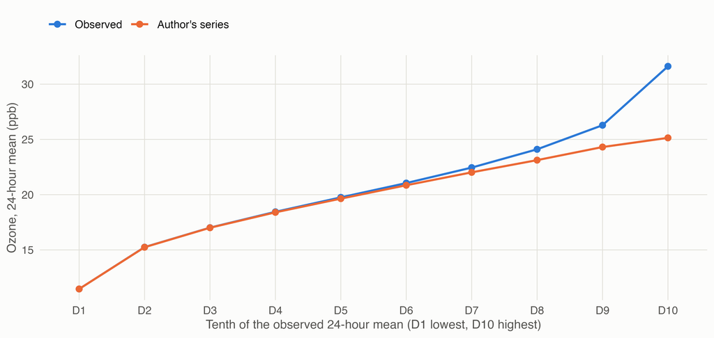

Figure 6: Author’s station series against the observed 24-hour mean, by tenths of the observed value. Warm-season station-days with both values.

```r
level_long <- melt(by_level[, .(level, `Observed` = observed_mean24, `Author's series` = author_mean)],
                   id.vars = "level", variable.name = "series", value.name = "ozone")
level_long[, level := factor(level, levels = paste0("D", 1:10))]
ggplot(level_long, aes(level, ozone, colour = series, group = series)) +
  geom_line(linewidth = 0.8) +
  geom_point(size = 2) +
  scale_colour_manual(values = c("Observed" = "#2a78d6", "Author's series" = "#eb6834")) +
  labs(x = "Tenth of the observed 24-hour mean (D1 lowest, D10 highest)",
       y = "Ozone, 24-hour mean (ppb)", colour = NULL)
```

```r
kable(by_level, digits = 1, format.args = list(big.mark = ","),
      col.names = c("Tenth", "Station-days", "Observed 24-hour mean (ppb)", "Observed MDA8 (ppb)",
                    "Author's mean (ppb)", "Difference (ppb)", "Modified (%)"))
```

Table 20: Values behind the figure, with the observed MDA8 of the same days and the share of modified station-days.

| Tenth | Station-days | Observed 24-hour mean (ppb) | Observed MDA8 (ppb) | Author’s mean (ppb) | Difference (ppb) | Modified (%) |
| --- | --- | --- | --- | --- | --- | --- |
| D1 | 1,763 | 11.5 | 23.6 | 11.5 | 0.0 | 0.1 |
| D2 | 1,746 | 15.3 | 31.0 | 15.2 | 0.0 | 0.3 |
| D3 | 1,736 | 17.0 | 34.2 | 17.0 | 0.0 | 0.5 |
| D4 | 1,753 | 18.4 | 36.8 | 18.4 | 0.0 | 1.9 |
| D5 | 1,744 | 19.8 | 39.3 | 19.6 | -0.1 | 3.6 |
| D6 | 1,748 | 21.0 | 41.6 | 20.9 | -0.2 | 6.5 |
| D7 | 1,760 | 22.5 | 44.6 | 22.0 | -0.4 | 12.2 |
| D8 | 1,757 | 24.1 | 47.9 | 23.1 | -1.0 | 24.9 |
| D9 | 1,729 | 26.3 | 52.0 | 24.3 | -2.0 | 43.4 |
| D10 | 1,747 | 31.6 | 61.3 | 25.1 | -6.5 | 78.1 |

On the tenth of station-days with most ozone the author’s series is 6.5 ppb lower than the measurements (25.1 against 31.6 ppb, a 20% reduction), and 78% of those station-days were modified. This is what trimming the hourly values at their 99th percentile does to ozone: the hours it removes are the afternoon peaks of the hottest days, so the daily mean of exactly those days is pulled down. The trimming flattens the upper tail of the exposure that the study is about.

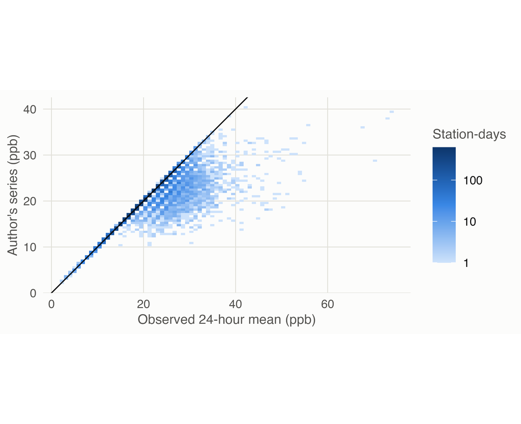

Figure 7: Author’s station series against the observed 24-hour mean, warm-season station-days 2009-2020. The line is equality.

```r
both <- inputs[warm_season == TRUE & !is.na(author_o3) & !is.na(mean24)]
ggplot(both, aes(mean24, author_o3)) +
  geom_bin2d(bins = 80) +
  geom_abline(colour = ink$primary, linewidth = 0.4) +
  scale_fill_magnitude(name = "Station-days", trans = "log10") +
  coord_equal() +
  labs(x = "Observed 24-hour mean (ppb)", y = "Author's series (ppb)") +
  theme(legend.position = "right", legend.justification = "center")
```

### 4.2.1 Records that were never validated

*Computed in this page from the hourly file of the station, with `read_sinca_hourly()` and `daily_from_hourly()` of `Code/01_functions.R`.*

SINCA marks every hourly record as validated, preliminary or not validated. Most records of the study period are validated, but some station-periods were never validated, and one of them is an evident instrument failure.

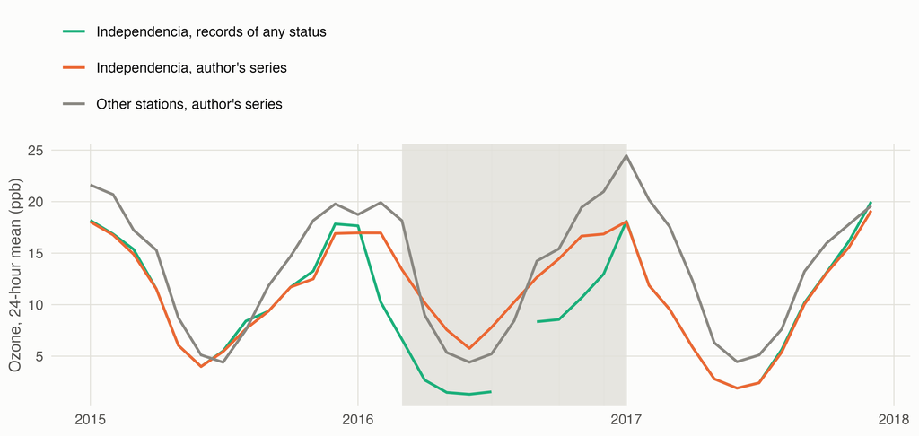

Figure 8: Independencia, 2015-2017, monthly mean of the 24-hour ozone: hourly records of any status, the author’s series, and the mean of the other stations in the author’s series. Shaded: months in which Independencia has no validated record.

```r
rules <- get_param("station_series")
codes <- fread(here::here(rules$stations_file), encoding = "UTF-8")
any_status <- daily_from_hourly(
  read_sinca_hourly(file.path(input_path("sinca_hourly_dir"),
                              sprintf(rules$hourly_file_pattern, codes[station == "Independencia", sinca_id])),
                    accepted_status = c("validated", "preliminary", "not_validated")),
  min_hours = rules$min_valid_hours_day, mda8_min_hours = rules$mda8_min_hours_window,
  mda8_min_windows = rules$mda8_min_windows_day
)[, .(date, any_status = mean24)]
window <- merge(inputs[date >= as.Date("2015-01-01") & date <= as.Date("2017-12-31")],
                any_status, by = "date", all.x = TRUE)
window[, month_start := as.Date(format(date, "%Y-%m-01"))]
monthly <- window[, .(
  `Independencia, records of any status` = mean(any_status[station == "Independencia"], na.rm = TRUE),
  `Independencia, author's series` = mean(author_o3[station == "Independencia"], na.rm = TRUE),
  `Other stations, author's series` = mean(author_o3[station != "Independencia"], na.rm = TRUE),
  validated_days = sum(station == "Independencia" & !is.na(mean24))
), by = month_start]
shade <- monthly[validated_days == 0, .(xmin = month_start, xmax = month_start + 31)]
monthly_long <- melt(monthly, id.vars = "month_start", measure.vars = 2:4,
                     variable.name = "series", value.name = "ozone")
no_validated <- inputs[station == "Independencia" & year(date) == 2016 & is.na(mean24) & !is.na(author_o3), .N]
ggplot(monthly_long) +
  geom_rect(data = shade, aes(xmin = xmin, xmax = xmax, ymin = -Inf, ymax = Inf),
            fill = ink$grid, alpha = 0.8) +
  geom_line(aes(month_start, ozone, colour = series), linewidth = 0.8) +
  scale_colour_manual(values = c("Independencia, records of any status" = "#1baf7a",
                                 "Independencia, author's series" = "#eb6834",
                                 "Other stations, author's series" = ink$muted)) +
  labs(x = NULL, y = "Ozone, 24-hour mean (ppb)", colour = NULL) +
  guides(colour = guide_legend(nrow = 3))
```

## 4.3 B. The interpolation model

*Scripts: `Code/14_interpolation_validation.R` (predictions, in `Data/Derived/validation_loso_predictions.csv`) and `Code/17_validation_summary.R`. Tables: `Output/Tables/validation_loso_overall.csv`, `validation_loso_common.csv`, `validation_loso_by_station.csv` and `validation_loso_high_ozone.csv`.*

Leave-one-station-out cross-validation: for every warm-season day of 2009-2020 each station is removed in turn, the model is fitted to the remaining stations with the author’s function and parameters, and the removed station is predicted. The observed values are the validated 24-hour mean and MDA8.

```r
loso_table <- copy(loso)[, `:=`(metric = metric_label[metric], method = method_label[method])]
kable(loso_table[, .(metric, method, n, mean_observed, bias, mae, rmse, nrmse_pct, pearson_r, r2,
                     not_predicted_pct, interval_coverage_pct)],
      digits = c(0, 0, 0, 1, 2, 2, 2, 1, 3, 3, 1, 1), format.args = list(big.mark = ","),
      col.names = c("Metric", "Method", "Station-days", "Observed mean (ppb)", "Bias (ppb)",
                    "MAE (ppb)", "RMSE (ppb)", "RMSE (% of mean)", "Pearson r", "R²",
                    "Not predicted (%)", "Inside the 95% kriging interval (%)"))
```

Table 21: Leave-one-station-out cross-validation, warm seasons 2009-2020. R² is the coefficient of determination against the 1:1 line.

| Metric | Method | Station-days | Observed mean (ppb) | Bias (ppb) | MAE (ppb) | RMSE (ppb) | RMSE (% of mean) | Pearson r | R² | Not predicted (%) | Inside the 95% kriging interval (%) |
| --- | --- | --- | --- | --- | --- | --- | --- | --- | --- | --- | --- |
| MDA8 | IDW | 15,491 | 41.9 | -1.66 | 5.30 | 7.59 | 18.1 | 0.768 | 0.558 | 10.0 |  |
| MDA8 | Ordinary kriging | 17,195 | 41.2 | -0.23 | 5.68 | 7.89 | 19.2 | 0.744 | 0.541 | 0.2 | 75.4 |
| 24-hour mean | IDW | 15,757 | 20.9 | -0.91 | 3.37 | 4.61 | 22.0 | 0.647 | 0.357 | 9.8 |  |
| 24-hour mean | Ordinary kriging | 17,460 | 20.7 | -0.03 | 3.02 | 4.08 | 19.7 | 0.711 | 0.493 | 0.1 | 83.6 |

IDW gives no value when no station lies within its 15 km radius, which is always the case for Talagante and sometimes for other stations when their neighbours have no validated record; kriging always gives one. The table above therefore compares the methods on different station-days. On the station-days that both methods predict:

```r
common_table <- copy(loso_common)[, `:=`(metric = metric_label[metric], method = method_label[method])]
kable(common_table[order(metric, method), .(metric, method, n, bias, mae, rmse, nrmse_pct, pearson_r, r2)],
      digits = c(0, 0, 0, 2, 2, 2, 1, 3, 3), format.args = list(big.mark = ","),
      col.names = c("Metric", "Method", "Station-days", "Bias (ppb)", "MAE (ppb)", "RMSE (ppb)",
                    "RMSE (% of mean)", "Pearson r", "R²"))
```

Table 22: The two methods on the same station-days.

| Metric | Method | Station-days | Bias (ppb) | MAE (ppb) | RMSE (ppb) | RMSE (% of mean) | Pearson r | R² |
| --- | --- | --- | --- | --- | --- | --- | --- | --- |
| 24-hour mean | IDW | 15,741 | -0.91 | 3.37 | 4.61 | 22.0 | 0.646 | 0.357 |
| 24-hour mean | Ordinary kriging | 15,741 | -0.20 | 2.95 | 4.00 | 19.1 | 0.725 | 0.515 |
| MDA8 | IDW | 15,466 | -1.66 | 5.30 | 7.59 | 18.1 | 0.768 | 0.558 |
| MDA8 | Ordinary kriging | 15,466 | -1.01 | 5.21 | 7.35 | 17.5 | 0.776 | 0.586 |

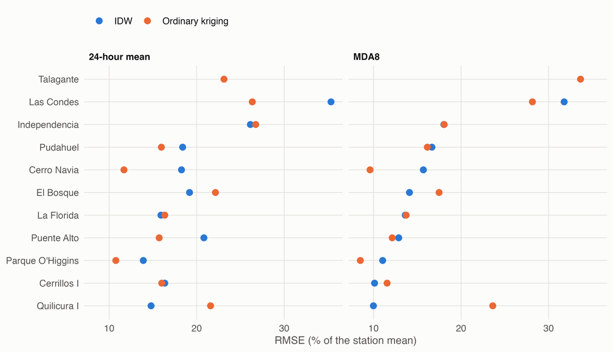

Figure 9: Cross-validation error by station: RMSE as a percentage of the station mean.

```r
station_plot <- copy(loso_station)[, `:=`(metric = metric_label[metric], method = method_label[method])]
order_station <- station_plot[metric == "MDA8" & method == "IDW"][order(nrmse_pct), station]
ggplot(station_plot, aes(nrmse_pct, factor(station, levels = order_station), colour = method)) +
  geom_point(size = 2.4) +
  facet_wrap(~metric) +
  scale_colour_manual(values = colour_method) +
  labs(x = "RMSE (% of the station mean)", y = NULL, colour = NULL)
```

```r
kableExtra::scroll_box(
  kableExtra::kable_styling(
    kable(station_plot[order(metric, station, method),
                       .(metric, station, method, n, mean_observed, bias, rmse, pearson_r, r2)],
          format = "html", digits = c(0, 0, 0, 0, 1, 2, 2, 3, 3), format.args = list(big.mark = ","),
          col.names = c("Metric", "Station", "Method", "Station-days", "Observed mean (ppb)",
                        "Bias (ppb)", "RMSE (ppb)", "Pearson r", "R²")),
    bootstrap_options = c("striped", "condensed"), font_size = 12),
  height = "380px"
)
```

Table 23: Cross-validation by station.

| Metric | Station | Method | Station-days | Observed mean (ppb) | Bias (ppb) | RMSE (ppb) | Pearson r | R² |
| --- | --- | --- | --- | --- | --- | --- | --- | --- |
| 24-hour mean | Cerrillos I | IDW | 1,211 | 22.1 | -2.30 | 3.62 | 0.836 | 0.493 |
| 24-hour mean | Cerrillos I | Ordinary kriging | 1,208 | 22.1 | -1.69 | 3.54 | 0.795 | 0.512 |
| 24-hour mean | Cerro Navia | IDW | 1,704 | 20.8 | -1.18 | 3.79 | 0.728 | 0.423 |
| 24-hour mean | Cerro Navia | Ordinary kriging | 1,702 | 20.8 | -0.26 | 2.43 | 0.878 | 0.763 |
| 24-hour mean | El Bosque | IDW | 1,747 | 18.6 | 2.55 | 3.57 | 0.859 | 0.410 |
| 24-hour mean | El Bosque | Ordinary kriging | 1,746 | 18.6 | 3.08 | 4.12 | 0.841 | 0.214 |
| 24-hour mean | Independencia | IDW | 1,681 | 17.9 | 3.30 | 4.69 | 0.771 | 0.123 |
| 24-hour mean | Independencia | Ordinary kriging | 1,677 | 17.9 | 3.43 | 4.79 | 0.766 | 0.082 |
| 24-hour mean | La Florida | IDW | 1,792 | 19.8 | 0.81 | 3.16 | 0.832 | 0.670 |
| 24-hour mean | La Florida | Ordinary kriging | 1,792 | 19.8 | 1.13 | 3.25 | 0.833 | 0.652 |
| 24-hour mean | Las Condes | IDW | 1,634 | 25.5 | -7.62 | 9.03 | 0.735 | -0.602 |
| 24-hour mean | Las Condes | Ordinary kriging | 1,759 | 25.7 | -5.37 | 6.77 | 0.859 | 0.122 |
| 24-hour mean | Parque O'Higgins | IDW | 1,627 | 21.3 | -1.84 | 2.96 | 0.881 | 0.634 |
| 24-hour mean | Parque O'Higgins | Ordinary kriging | 1,624 | 21.3 | -0.79 | 2.29 | 0.899 | 0.781 |
| 24-hour mean | Pudahuel | IDW | 1,595 | 19.5 | 1.24 | 3.59 | 0.751 | 0.438 |
| 24-hour mean | Pudahuel | Ordinary kriging | 1,595 | 19.5 | 1.13 | 3.12 | 0.811 | 0.576 |
| 24-hour mean | Puente Alto | IDW | 1,675 | 22.9 | -3.73 | 4.77 | 0.836 | 0.218 |
| 24-hour mean | Puente Alto | Ordinary kriging | 1,672 | 22.9 | -2.31 | 3.60 | 0.859 | 0.554 |
| 24-hour mean | Quilicura I | IDW | 1,091 | 21.0 | -1.18 | 3.11 | 0.843 | 0.660 |
| 24-hour mean | Quilicura I | Ordinary kriging | 1,091 | 21.0 | -1.73 | 4.54 | 0.679 | 0.277 |
| 24-hour mean | Talagante | IDW | 0 |  |  |  |  |  |
| 24-hour mean | Talagante | Ordinary kriging | 1,594 | 18.6 | 2.19 | 4.31 | 0.685 | 0.100 |
| MDA8 | Cerrillos I | IDW | 1,196 | 41.6 | -1.69 | 4.21 | 0.929 | 0.837 |
| MDA8 | Cerrillos I | Ordinary kriging | 1,193 | 41.6 | -0.98 | 4.81 | 0.893 | 0.787 |
| MDA8 | Cerro Navia | IDW | 1,696 | 40.1 | -1.67 | 6.29 | 0.806 | 0.591 |
| MDA8 | Cerro Navia | Ordinary kriging | 1,693 | 40.1 | 0.75 | 3.85 | 0.926 | 0.847 |
| MDA8 | El Bosque | IDW | 1,716 | 38.1 | 4.15 | 5.38 | 0.937 | 0.679 |
| MDA8 | El Bosque | Ordinary kriging | 1,715 | 38.1 | 4.83 | 6.67 | 0.897 | 0.506 |
| MDA8 | Independencia | IDW | 1,630 | 38.4 | 3.24 | 6.93 | 0.820 | 0.569 |
| MDA8 | Independencia | Ordinary kriging | 1,622 | 38.4 | 3.62 | 6.94 | 0.832 | 0.568 |
| MDA8 | La Florida | IDW | 1,769 | 42.6 | -1.22 | 5.80 | 0.877 | 0.756 |
| MDA8 | La Florida | Ordinary kriging | 1,768 | 42.6 | -1.29 | 5.84 | 0.876 | 0.752 |
| MDA8 | Las Condes | IDW | 1,568 | 53.1 | -14.62 | 16.86 | 0.779 | -0.587 |
| MDA8 | Las Condes | Ordinary kriging | 1,737 | 53.4 | -13.26 | 15.02 | 0.877 | -0.219 |
| MDA8 | Parque O'Higgins | IDW | 1,602 | 43.0 | -3.21 | 4.74 | 0.937 | 0.775 |
| MDA8 | Parque O'Higgins | Ordinary kriging | 1,596 | 43.0 | -2.04 | 3.65 | 0.954 | 0.867 |
| MDA8 | Pudahuel | IDW | 1,573 | 37.9 | 2.27 | 6.32 | 0.806 | 0.547 |
| MDA8 | Pudahuel | Ordinary kriging | 1,573 | 37.9 | 2.86 | 6.12 | 0.838 | 0.575 |
| MDA8 | Puente Alto | IDW | 1,659 | 44.4 | -3.93 | 5.72 | 0.918 | 0.676 |
| MDA8 | Puente Alto | Ordinary kriging | 1,657 | 44.4 | -3.34 | 5.39 | 0.908 | 0.712 |
| MDA8 | Quilicura I | IDW | 1,082 | 39.5 | -0.11 | 3.95 | 0.919 | 0.843 |
| MDA8 | Quilicura I | Ordinary kriging | 1,082 | 39.5 | -2.46 | 9.34 | 0.682 | 0.122 |
| MDA8 | Talagante | IDW | 0 |  |  |  |  |  |
| MDA8 | Talagante | Ordinary kriging | 1,559 | 32.8 | 9.01 | 11.02 | 0.775 | -0.553 |

### 4.3.1 High-ozone days

The analysis classifies days as high ozone against a percentile of each place. The same is done here with the predictions: a station-day is predicted high when the prediction exceeds the percentile of the predictions at that station.

```r
high_table <- copy(loso_high)[, `:=`(metric = metric_label[metric], method = method_label[method])]
kable(high_table[order(metric, percentile, method),
                 .(metric, percentile = paste0("> P", percentile), method, n,
                   sensitivity = 100 * sensitivity, specificity = 100 * specificity,
                   agreement = 100 * agreement, kappa)],
      digits = c(0, 0, 0, 0, 1, 1, 1, 2), format.args = list(big.mark = ","),
      col.names = c("Metric", "Cut-off", "Method", "Station-days", "Sensitivity (%)",
                    "Specificity (%)", "Agreement (%)", "Kappa"))
```

Table 24: High-ozone days: predicted against observed classification at the station left out.

| Metric | Cut-off | Method | Station-days | Sensitivity (%) | Specificity (%) | Agreement (%) | Kappa |
| --- | --- | --- | --- | --- | --- | --- | --- |
| 24-hour mean | > P50 | IDW | 15,757 | 81.0 | 81.0 | 81.0 | 0.62 |
| 24-hour mean | > P50 | Ordinary kriging | 17,460 | 81.5 | 81.5 | 81.5 | 0.63 |
| 24-hour mean | > P75 | IDW | 15,757 | 68.9 | 89.6 | 84.4 | 0.58 |
| 24-hour mean | > P75 | Ordinary kriging | 17,460 | 69.0 | 89.7 | 84.5 | 0.59 |
| 24-hour mean | > P90 | IDW | 15,757 | 58.5 | 95.4 | 91.7 | 0.54 |
| 24-hour mean | > P90 | Ordinary kriging | 17,460 | 59.3 | 95.5 | 91.8 | 0.55 |
| MDA8 | > P50 | IDW | 15,491 | 84.9 | 84.7 | 84.8 | 0.70 |
| MDA8 | > P50 | Ordinary kriging | 17,195 | 85.0 | 84.8 | 84.9 | 0.70 |
| MDA8 | > P75 | IDW | 15,491 | 74.8 | 91.6 | 87.4 | 0.66 |
| MDA8 | > P75 | Ordinary kriging | 17,195 | 74.4 | 91.4 | 87.2 | 0.66 |
| MDA8 | > P90 | IDW | 15,491 | 65.3 | 96.1 | 93.0 | 0.61 |
| MDA8 | > P90 | Ordinary kriging | 17,195 | 63.5 | 95.9 | 92.7 | 0.59 |

## 4.4 C. Delivered and rebuilt municipal series

*Scripts: `Code/12_ozone_station_series.R` (rebuilt series) and `Code/17_validation_summary.R`. Tables: `Output/Tables/validation_reproduction.csv`, `validation_municipal_by_level.csv` and `validation_municipal_flags.csv`.*

Script 12 interpolates the validated station values to the 33 municipalities with the same model: `o3obs` is the 24-hour mean and `o3mda8` the daily maximum 8-hour mean.

First, a reproduction test. On the days when every station value of the author’s series equals the validated 24-hour mean, the two municipal series have the same inputs and should coincide if this project runs the same interpolation.

```r
reproduction <- read_table("validation_reproduction.csv")
kable(reproduction[, .(method = method_label[method], days, municipality_days, within_0.001_ppb_pct,
                       median_abs_difference, max_abs_difference)],
      digits = c(0, 0, 0, 1, 6, 4), format.args = list(big.mark = ","),
      col.names = c("Method", "Days", "Municipality-days", "Within 0.001 ppb (%)",
                    "Median absolute difference (ppb)", "Largest absolute difference (ppb)"))
```

Table 25: Rebuilt against delivered municipal ozone on the warm-season days with identical station inputs.

| Method | Days | Municipality-days | Within 0.001 ppb (%) | Median absolute difference (ppb) | Largest absolute difference (ppb) |
| --- | --- | --- | --- | --- | --- |
| IDW | 420 | 13,860 | 100.0 | 5e-06 | 0.0001 |
| Ordinary kriging | 420 | 13,860 | 98.8 | 2e-06 | 0.5174 |

With the same inputs this project returns the delivered values: all of the IDW values and nearly all of the kriging values agree to the third decimal (the daily variogram fit makes kriging sensitive to the last digits of its inputs). The differences shown in the rest of this section therefore come from the station inputs.

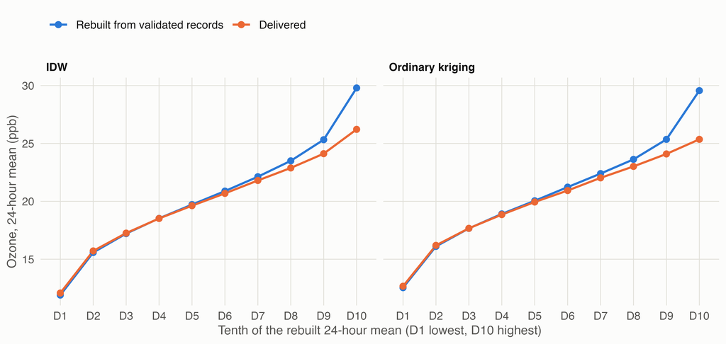

Figure 10: Delivered against rebuilt 24-hour mean by tenths of the rebuilt value, municipality-days of the warm seasons 2009-2020.

```r
ml <- melt(municipal_level[, .(method = method_label[method], level,
                               `Rebuilt from validated records` = rebuilt_mean24,
                               `Delivered` = delivered_mean24)],
           id.vars = c("method", "level"), variable.name = "series", value.name = "ozone")
ml[, level := factor(level, levels = paste0("D", 1:10))]
ggplot(ml, aes(level, ozone, colour = series, group = series)) +
  geom_line(linewidth = 0.8) +
  geom_point(size = 2) +
  facet_wrap(~method) +
  scale_colour_manual(values = c("Rebuilt from validated records" = "#2a78d6", "Delivered" = "#eb6834")) +
  labs(x = "Tenth of the rebuilt 24-hour mean (D1 lowest, D10 highest)",
       y = "Ozone, 24-hour mean (ppb)", colour = NULL)
```

```r
kable(municipal_level[, .(method = method_label[method], level, municipality_days, rebuilt_mean24,
                          delivered_mean24, difference, rebuilt_mda8)],
      digits = 1, format.args = list(big.mark = ","),
      col.names = c("Method", "Tenth", "Municipality-days", "Rebuilt 24-hour mean (ppb)",
                    "Delivered (ppb)", "Difference (ppb)", "Rebuilt MDA8 (ppb)"))
```

Table 26: Values behind the figure, with the rebuilt MDA8 of the same municipality-days.

| Method | Tenth | Municipality-days | Rebuilt 24-hour mean (ppb) | Delivered (ppb) | Difference (ppb) | Rebuilt MDA8 (ppb) |
| --- | --- | --- | --- | --- | --- | --- |
| IDW | D1 | 5,983 | 11.9 | 12.1 | 0.2 | 24.8 |
| IDW | D2 | 5,982 | 15.6 | 15.7 | 0.1 | 32.1 |
| IDW | D3 | 5,982 | 17.2 | 17.3 | 0.0 | 35.1 |
| IDW | D4 | 5,982 | 18.5 | 18.5 | 0.0 | 37.8 |
| IDW | D5 | 5,983 | 19.7 | 19.6 | -0.1 | 40.1 |
| IDW | D6 | 5,982 | 20.9 | 20.7 | -0.2 | 42.5 |
| IDW | D7 | 5,982 | 22.1 | 21.8 | -0.3 | 44.8 |
| IDW | D8 | 5,982 | 23.5 | 22.9 | -0.6 | 47.4 |
| IDW | D9 | 5,982 | 25.3 | 24.1 | -1.2 | 51.0 |
| IDW | D10 | 5,983 | 29.8 | 26.2 | -3.6 | 58.6 |
| Ordinary kriging | D1 | 5,982 | 12.5 | 12.7 | 0.1 | 25.7 |
| Ordinary kriging | D2 | 5,982 | 16.1 | 16.2 | 0.1 | 32.8 |
| Ordinary kriging | D3 | 5,982 | 17.7 | 17.7 | 0.0 | 35.5 |
| Ordinary kriging | D4 | 5,982 | 18.9 | 18.9 | -0.1 | 37.7 |
| Ordinary kriging | D5 | 5,982 | 20.0 | 19.9 | -0.1 | 40.6 |
| Ordinary kriging | D6 | 5,981 | 21.2 | 20.9 | -0.3 | 42.9 |
| Ordinary kriging | D7 | 5,982 | 22.4 | 22.0 | -0.4 | 45.0 |
| Ordinary kriging | D8 | 5,982 | 23.6 | 23.0 | -0.6 | 47.2 |
| Ordinary kriging | D9 | 5,982 | 25.4 | 24.1 | -1.3 | 50.6 |
| Ordinary kriging | D10 | 5,982 | 29.6 | 25.4 | -4.2 | 58.1 |

### 4.4.1 Does the choice of series change who is exposed?

```r
series_label <- c(o3 = "Delivered 24-hour mean", o3obs = "Rebuilt 24-hour mean", o3mda8 = "Rebuilt MDA8")
flags <- copy(municipal_flags)[, `:=`(reference = series_label[reference], compared = series_label[compared],
                                      method = method_label[method])]
kable(flags[, .(reference, compared, method, percentile = paste0("> P", percentile), pearson_r,
                sensitivity = 100 * sensitivity, specificity = 100 * specificity,
                agreement = 100 * agreement, kappa)],
      digits = c(0, 0, 0, 0, 2, 1, 1, 1, 2),
      col.names = c("Reference", "Compared", "Method", "Cut-off", "Pearson r", "Sensitivity (%)",
                    "Specificity (%)", "Agreement (%)", "Kappa"))
```

Table 27: Agreement of the high-ozone flags between series, municipality-days of the warm seasons 2009-2020. Sensitivity and specificity take the first series as reference.

| Reference | Compared | Method | Cut-off | Pearson r | Sensitivity (%) | Specificity (%) | Agreement (%) | Kappa |
| --- | --- | --- | --- | --- | --- | --- | --- | --- |
| Rebuilt 24-hour mean | Delivered 24-hour mean | IDW | > P50 | 0.92 | 94.3 | 94.4 | 94.4 | 0.89 |
| Rebuilt 24-hour mean | Delivered 24-hour mean | IDW | > P75 | 0.92 | 82.5 | 94.2 | 91.3 | 0.77 |
| Rebuilt 24-hour mean | Delivered 24-hour mean | IDW | > P90 | 0.92 | 63.5 | 95.9 | 92.7 | 0.59 |
| Rebuilt 24-hour mean | Delivered 24-hour mean | Ordinary kriging | > P50 | 0.84 | 91.1 | 91.2 | 91.1 | 0.82 |
| Rebuilt 24-hour mean | Delivered 24-hour mean | Ordinary kriging | > P75 | 0.84 | 78.2 | 92.7 | 89.1 | 0.71 |
| Rebuilt 24-hour mean | Delivered 24-hour mean | Ordinary kriging | > P90 | 0.84 | 58.7 | 95.4 | 91.7 | 0.54 |
| Rebuilt MDA8 | Delivered 24-hour mean | IDW | > P50 | 0.82 | 84.6 | 84.7 | 84.6 | 0.69 |
| Rebuilt MDA8 | Delivered 24-hour mean | IDW | > P75 | 0.82 | 67.3 | 89.1 | 83.7 | 0.56 |
| Rebuilt MDA8 | Delivered 24-hour mean | IDW | > P90 | 0.82 | 42.3 | 93.6 | 88.4 | 0.36 |
| Rebuilt MDA8 | Delivered 24-hour mean | Ordinary kriging | > P50 | 0.74 | 81.8 | 82.0 | 81.9 | 0.64 |
| Rebuilt MDA8 | Delivered 24-hour mean | Ordinary kriging | > P75 | 0.74 | 64.6 | 88.2 | 82.3 | 0.53 |
| Rebuilt MDA8 | Delivered 24-hour mean | Ordinary kriging | > P90 | 0.74 | 41.2 | 93.4 | 88.2 | 0.35 |
| Rebuilt MDA8 | Rebuilt 24-hour mean | IDW | > P50 | 0.91 | 87.5 | 87.6 | 87.6 | 0.75 |
| Rebuilt MDA8 | Rebuilt 24-hour mean | IDW | > P75 | 0.91 | 79.0 | 93.0 | 89.5 | 0.72 |
| Rebuilt MDA8 | Rebuilt 24-hour mean | IDW | > P90 | 0.91 | 72.9 | 97.0 | 94.6 | 0.70 |
| Rebuilt MDA8 | Rebuilt 24-hour mean | Ordinary kriging | > P50 | 0.90 | 86.8 | 86.9 | 86.8 | 0.74 |
| Rebuilt MDA8 | Rebuilt 24-hour mean | Ordinary kriging | > P75 | 0.90 | 78.0 | 92.7 | 89.1 | 0.71 |
| Rebuilt MDA8 | Rebuilt 24-hour mean | Ordinary kriging | > P90 | 0.90 | 72.8 | 97.0 | 94.5 | 0.70 |

## 4.5 An independent source: the CAMS reanalysis

*Script: `Code/16_reanalysis_comparison.R`. Tables: `Output/Tables/validation_cams_correlation.csv` and `validation_cams_cells.csv` (the cells of the reanalysis that hold the municipalities).*

No satellite measures ozone at the surface with the resolution of a city: the ozone column seen from space is dominated by the stratosphere. The closest independent source is a reanalysis that assimilates the satellite retrievals into a chemistry model. CAMS EAC4 has cells of 0.75 degrees, so the 33 municipalities fall in two cells and the comparison says nothing about differences between municipalities. What it can check is whether the day-to-day course of ozone over the city in the station-based series is also seen by a source that does not use the monitors.

```r
cams_series <- c(o3_idw = "Delivered 24-hour mean, IDW", o3_ok = "Delivered 24-hour mean, kriging",
                 o3obs_idw = "Rebuilt 24-hour mean, IDW", o3obs_ok = "Rebuilt 24-hour mean, kriging",
                 o3mda8_idw = "Rebuilt MDA8, IDW", o3mda8_ok = "Rebuilt MDA8, kriging")
cams_table <- copy(cams)[, `:=`(series = cams_series[series],
                                cams = fifelse(cams == "cams_mean24", "Daily mean", "Afternoon (15 and 18 h)"))]
kable(cams_table, digits = c(0, 0, 0, 1, 1, 2, 2), format.args = list(big.mark = ","),
      col.names = c("Station-based series", "CAMS value", "Days", "Series mean (ppb)",
                    "CAMS mean (ppb)", "Correlation, daily values", "Correlation, anomalies"))
```

Table 28: City-wide daily ozone against CAMS EAC4, warm seasons 2009-2020. Anomalies are deviations from the mean of each calendar month.

| Station-based series | CAMS value | Days | Series mean (ppb) | CAMS mean (ppb) | Correlation, daily values | Correlation, anomalies |
| --- | --- | --- | --- | --- | --- | --- |
| Delivered 24-hour mean, IDW | Daily mean | 1,815 | 19.9 | 35.6 | 0.33 | 0.17 |
| Delivered 24-hour mean, kriging | Daily mean | 1,815 | 20.1 | 35.6 | 0.31 | 0.17 |
| Rebuilt 24-hour mean, IDW | Daily mean | 1,813 | 20.5 | 35.6 | 0.36 | 0.23 |
| Rebuilt 24-hour mean, kriging | Daily mean | 1,813 | 20.7 | 35.6 | 0.37 | 0.24 |
| Rebuilt MDA8, IDW | Afternoon (15 and 18 h) | 1,813 | 41.4 | 59.1 | 0.42 | 0.41 |
| Rebuilt MDA8, kriging | Afternoon (15 and 18 h) | 1,812 | 41.6 | 59.1 | 0.44 | 0.42 |

CAMS is a weak reference for surface ozone in a basin that one of its cells covers almost entirely, mountains included: its values are much higher than the monitors and the correlations are modest. Within those limits, the series rebuilt from validated records follow it more closely than the delivered series, and the MDA8 more closely than the 24-hour mean.

## 4.6 What this means for the analysis

*Drawn from the tables of the parts above; the number of stations behind the delivered series comes from the exposure dataset.*

```r
# Stations behind the delivered ozone on the days of analysis
stations_per_day <- fread(derived_path("exposure_2009_2020.csv"),
                          select = c("in_study_period", "warm_season", "o3_n_stations"))[
  in_study_period == TRUE & warm_season == TRUE, range(o3_n_stations)]
common_wide <- dcast(loso_common, metric ~ method, value.var = c("rmse", "r2"))
mda8_flags <- municipal_flags[reference == "o3mda8" & compared == "o3" & method == "idw"]
coverage <- loso[method == "ok", .(metric, interval_coverage_pct)]
las_condes <- loso_station[station == "Las Condes" & metric == "mda8" & method == "ok"]
top_municipal <- municipal_level[method == "idw" & level == "D10"]
```

1. **The delivered series understates the days with most ozone.** Its station inputs are 6.5 ppb below the measurements on the highest tenth of station-days, and its municipal values are 3.6 ppb below the rebuilt ones on the highest tenth of municipality-days. A study of high-ozone days and of their interaction with heat should not use inputs trimmed at the 99th percentile.
2. **Station-days without a validated measurement are estimates.** In the delivered series 6.5% of the warm-season station-days have no validated daily mean; the Independencia monitor, which failed in 2016, is carried by imputed values for most of that year. The rebuilt series use validated records only.
3. **The metric matters.** The plan names the MDA8; the delivered series is a 24-hour mean. Among the municipality-days above the 75th percentile of MDA8, the delivered 24-hour mean flags 67% as high ozone (kappa 0.56).
4. **Interpolation method.** On the same station-days ordinary kriging has the lower cross-validation error for both metrics: RMSE 4.00 against 4.61 ppb for the 24-hour mean and 7.35 against 7.59 ppb for the MDA8. The difference is clear for the 24-hour mean and small for the MDA8. The kriging intervals contain the left-out observation 75% of the time for the MDA8 and 84% of the time for the 24-hour mean, against a nominal 95%, so they should not be read as measurement uncertainty. The working value of the configuration is still IDW; this result argues for kriging and the choice is open.
5. **What interpolation cannot fix.** Between 8 and 11 monitors a day describe 33 municipalities in the delivered series, and the error is far from uniform. Las Condes, the station with most ozone, cannot be predicted from the others (bias -13.3 ppb when it is left out): the eastern municipalities depend on that single monitor. The cross-validation error is the error at a monitored site when its own monitor is ignored; it is the best available estimate of the error in municipalities without a monitor, not a guarantee.

The exposure dataset keeps the three series (`o3`, `o3obs`, `o3mda8`) so that the choice can be made by the principal investigator and its effect shown as a sensitivity analysis. The working value in the configuration is still the delivered series.

# 5 Municipal maps and time series of single and compound exposure

## 5.1 Scope

Distribution of the single exposures (temperature, heatwaves, ozone) and of the compound exposure (a heatwave day with high ozone) across the 33 municipalities and the warm seasons of 2009 to 2020. All figures use the days between 1 November and 31 March.

Where one definition has to be shown, this section uses the working definitions of `config/config.yml`: heatwave hw_p95_2d, ozone series o3_idw, high ozone above the 75th percentile of the municipality. They are working values, not final choices; the grid of definitions covers every combination.

The first sections describe the municipalities as a group. The series of every municipality, and of the mean of the 33, over the whole study period are in Time series of every municipality and of their mean.

## 5.2 Single exposures

*Computed in this page from the exposure dataset (`Code/13_exposure_merge_qc.R`). The maps use the municipal polygons of the interpolation repository.*

```r
variables <- c(tmax = "Maximum temperature (°C)", tmin = "Minimum temperature (°C)",
               o3_idw = "Ozone, delivered 24-hour mean, IDW (ppb)",
               o3_ok = "Ozone, delivered 24-hour mean, kriging (ppb)",
               o3obs_idw = "Ozone, rebuilt 24-hour mean, IDW (ppb)",
               o3mda8_idw = "Ozone, rebuilt MDA8, IDW (ppb)",
               o3mda8_ok = "Ozone, rebuilt MDA8, kriging (ppb)",
               pm25_idw = "PM2.5, IDW (µg/m³)", no2_idw = "Nitrogen dioxide, IDW (ppb)",
               hum_idw = "Relative humidity, IDW (%)")
descriptive <- rbindlist(lapply(names(variables), function(v) {
  x <- analysis[[v]]
  q <- quantile(x, c(0.05, 0.25, 0.5, 0.75, 0.95), na.rm = TRUE)
  data.table(variable = variables[[v]], n = sum(!is.na(x)), missing = sum(is.na(x)),
             mean = mean(x, na.rm = TRUE), sd = sd(x, na.rm = TRUE),
             p5 = q[1], p25 = q[2], median = q[3], p75 = q[4], p95 = q[5])
}))
kable(descriptive, digits = 1, format.args = list(big.mark = ","),
      col.names = c("Variable", "N", "Missing", "Mean", "SD", "P5", "P25", "Median", "P75", "P95"))
```

Table 29: Exposure variables over the municipality-days of the warm seasons 2009-2020.

| Variable | N | Missing | Mean | SD | P5 | P25 | Median | P75 | P95 |
| --- | --- | --- | --- | --- | --- | --- | --- | --- | --- |
| Maximum temperature (°C) | 59,895 | 0 | 28.7 | 3.9 | 20.8 | 27.0 | 29.4 | 31.4 | 33.8 |
| Minimum temperature (°C) | 59,895 | 0 | 11.4 | 2.1 | 7.7 | 10.1 | 11.5 | 12.8 | 14.5 |
| Ozone, delivered 24-hour mean, IDW (ppb) | 59,895 | 0 | 19.9 | 4.3 | 12.8 | 17.2 | 20.0 | 22.7 | 26.6 |
| Ozone, delivered 24-hour mean, kriging (ppb) | 59,885 | 10 | 20.1 | 4.3 | 12.9 | 17.5 | 20.2 | 22.9 | 26.4 |
| Ozone, rebuilt 24-hour mean, IDW (ppb) | 59,823 | 72 | 20.5 | 5.1 | 12.7 | 17.2 | 20.3 | 23.5 | 28.6 |
| Ozone, rebuilt MDA8, IDW (ppb) | 59,815 | 80 | 41.4 | 10.5 | 24.9 | 34.5 | 41.3 | 48.1 | 58.2 |
| Ozone, rebuilt MDA8, kriging (ppb) | 59,795 | 100 | 41.6 | 10.1 | 25.5 | 34.9 | 41.6 | 48.1 | 57.6 |
| PM2.5, IDW (µg/m³) | 59,895 | 0 | 18.7 | 7.1 | 9.9 | 14.1 | 17.6 | 21.8 | 31.3 |
| Nitrogen dioxide, IDW (ppb) | 59,872 | 23 | 16.1 | 5.8 | 8.3 | 12.0 | 15.2 | 19.2 | 26.6 |
| Relative humidity, IDW (%) | 59,895 | 0 | 50.5 | 10.5 | 35.1 | 42.5 | 49.5 | 57.6 | 69.3 |

### 5.2.1 Maps

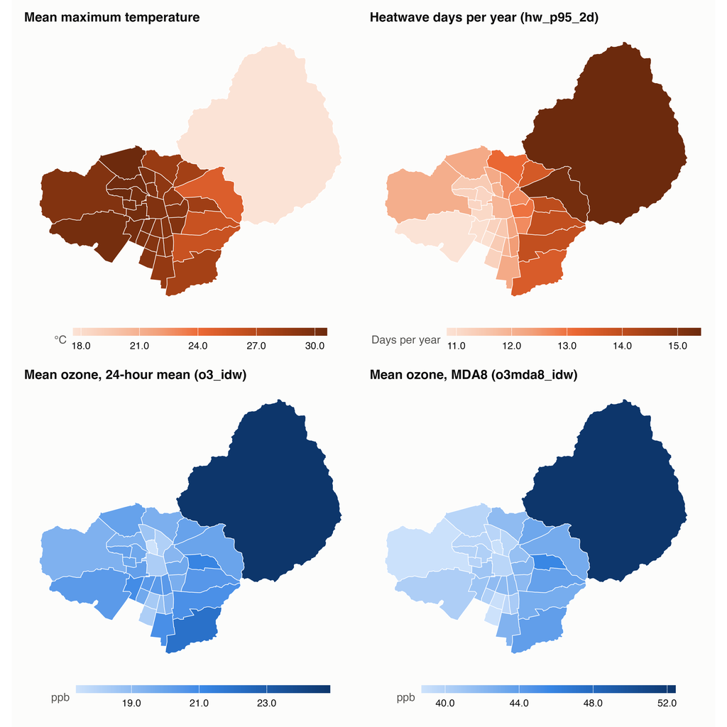

Figure 11: Mean maximum temperature, heatwave days per year and mean ozone by municipality, warm seasons 2009-2020.

```r
by_mun <- analysis[, .(
  tmax = mean(tmax), hw_days = sum(get(heatwave_main)) / 12,
  hot30 = sum(hot_30c) / 12,
  o3 = mean(get(ozone_main), na.rm = TRUE), mda8 = mean(o3mda8_idw, na.rm = TRUE)
), by = com]
patchwork::wrap_plots(
  map_values(by_mun, "tmax", "Mean maximum temperature", "°C", hue = "orange"),
  map_values(by_mun, "hw_days", paste0("Heatwave days per year (", heatwave_main, ")"),
             "Days per year", hue = "orange"),
  map_values(by_mun, "o3", paste0("Mean ozone, 24-hour mean (", ozone_main, ")"), "ppb"),
  map_values(by_mun, "mda8", "Mean ozone, MDA8 (o3mda8_idw)", "ppb"),
  ncol = 2
)
```

```r
table_mun <- merge(study_municipalities(), by_mun, by.x = "code", by.y = "com")
kableExtra::scroll_box(
  kableExtra::kable_styling(
    kable(table_mun, format = "html", digits = 1,
          col.names = c("Code", "Municipality", "Mean maximum temperature (°C)",
                        "Heatwave days per year", "Days above 30 °C per year",
                        "Ozone, 24-hour mean (ppb)", "Ozone, MDA8 (ppb)")),
    bootstrap_options = c("striped", "condensed"), font_size = 12),
  height = "380px"
)
```

Table 30: Values of the maps, with the number of days above 30 °C per year.

| Code | Municipality | Mean maximum temperature (°C) | Heatwave days per year | Days above 30 °C per year | Ozone, 24-hour mean (ppb) | Ozone, MDA8 (ppb) |
| --- | --- | --- | --- | --- | --- | --- |
| 13101 | Santiago | 29.5 | 11.9 | 75.5 | 18.3 | 39.7 |
| 13102 | Cerrillos | 30.2 | 10.9 | 88.9 | 20.9 | 41.1 |
| 13103 | Cerro Navia | 30.6 | 11.2 | 97.7 | 20.1 | 40.0 |
| 13104 | Conchalí | 29.9 | 12.2 | 83.7 | 18.6 | 39.7 |
| 13105 | El Bosque | 29.3 | 11.2 | 70.8 | 18.2 | 38.7 |
| 13106 | Estación Central | 30.3 | 11.1 | 90.8 | 20.2 | 41.0 |
| 13107 | Huechuraba | 28.4 | 13.2 | 48.7 | 19.5 | 41.8 |
| 13108 | Independencia | 29.6 | 12.0 | 77.9 | 17.4 | 38.9 |
| 13109 | La Cisterna | 29.4 | 11.4 | 71.2 | 18.4 | 38.9 |
| 13110 | La Florida | 26.1 | 13.9 | 11.2 | 20.8 | 42.9 |
| 13111 | La Granja | 29.0 | 12.4 | 62.4 | 19.3 | 40.5 |
| 13112 | La Pintana | 28.7 | 12.2 | 54.8 | 20.8 | 42.4 |
| 13113 | La Reina | 28.1 | 14.0 | 41.9 | 21.2 | 45.6 |
| 13114 | Las Condes | 25.0 | 15.2 | 3.1 | 20.0 | 43.0 |
| 13115 | Lo Barnechea | 17.6 | 15.4 | 0.0 | 24.9 | 52.4 |
| 13116 | Lo Espejo | 29.8 | 10.9 | 80.6 | 19.8 | 40.2 |
| 13117 | Lo Prado | 30.2 | 11.2 | 89.2 | 19.9 | 39.9 |
| 13118 | Macul | 29.5 | 12.7 | 73.3 | 19.6 | 41.9 |
| 13119 | Maipú | 30.1 | 10.8 | 88.1 | 20.4 | 40.3 |
| 13120 | Ñuñoa | 29.3 | 13.0 | 70.2 | 19.8 | 42.3 |
| 13121 | Pedro Aguirre Cerda | 30.0 | 11.2 | 86.2 | 20.4 | 41.7 |
| 13122 | Peñalolén | 26.1 | 13.9 | 11.2 | 20.5 | 43.7 |
| 13123 | Providencia | 28.9 | 12.7 | 59.6 | 19.2 | 41.4 |
| 13124 | Pudahuel | 29.5 | 12.1 | 74.5 | 19.4 | 38.9 |
| 13125 | Quilicura | 30.6 | 12.2 | 97.8 | 20.1 | 39.8 |
| 13126 | Quinta Normal | 30.2 | 11.2 | 89.0 | 19.8 | 40.2 |
| 13127 | Recoleta | 28.9 | 12.7 | 59.7 | 18.1 | 39.7 |
| 13128 | Renca | 30.4 | 11.4 | 94.7 | 19.5 | 39.7 |
| 13129 | San Joaquín | 29.3 | 12.2 | 71.2 | 20.4 | 42.0 |
| 13130 | San Miguel | 29.4 | 11.5 | 73.1 | 20.4 | 41.9 |
| 13131 | San Ramón | 29.1 | 11.9 | 65.7 | 18.7 | 39.6 |
| 13132 | Vitacura | 27.9 | 13.6 | 37.2 | 20.1 | 43.3 |
| 13201 | Puente Alto | 27.8 | 13.5 | 36.7 | 22.0 | 43.9 |

### 5.2.2 Time series

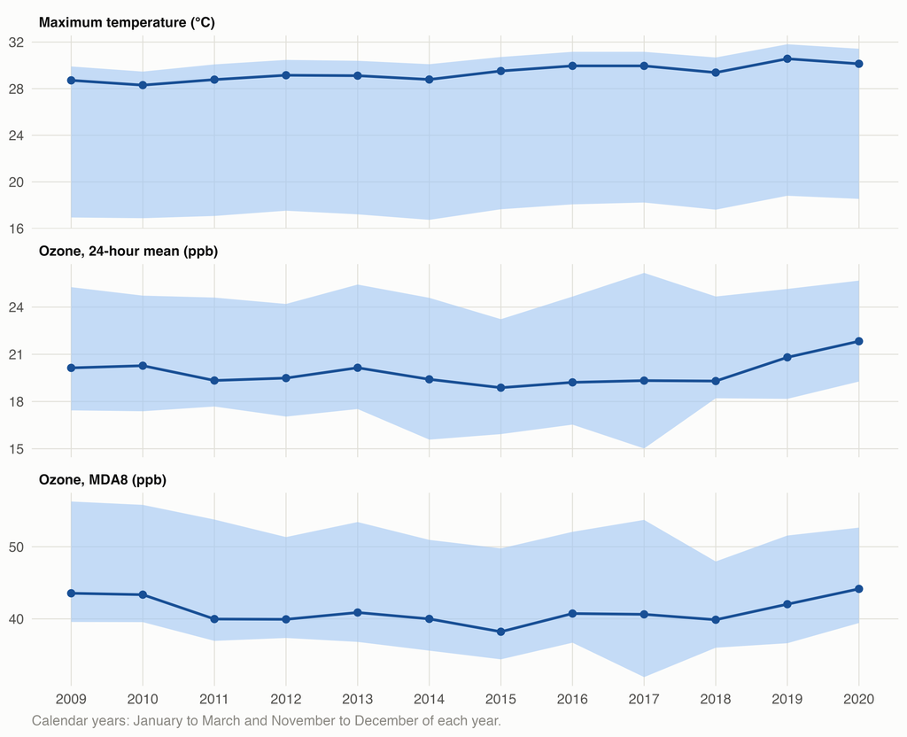

Figure 12: Warm-season means by calendar year. Line: median of the 33 municipalities; band: range between municipalities.

```r
annual <- analysis[, .(tmax = mean(tmax), o3 = mean(get(ozone_main), na.rm = TRUE),
                       mda8 = mean(o3mda8_idw, na.rm = TRUE)), by = .(com, year)]
annual_long <- melt(annual, id.vars = c("com", "year"))
annual_long[, variable := factor(variable, levels = c("tmax", "o3", "mda8"),
  labels = c("Maximum temperature (°C)", "Ozone, 24-hour mean (ppb)", "Ozone, MDA8 (ppb)"))]
bands <- annual_long[, .(median = median(value), low = min(value), high = max(value)),
                     by = .(variable, year)]
ggplot(bands, aes(year)) +
  geom_ribbon(aes(ymin = low, ymax = high), fill = ramp_blue[2], alpha = 0.6) +
  geom_line(aes(y = median), colour = ramp_blue[6], linewidth = 0.8) +
  geom_point(aes(y = median), colour = ramp_blue[6], size = 1.8) +
  facet_wrap(~variable, ncol = 1, scales = "free_y") +
  scale_x_continuous(breaks = 2009:2020) +
  labs(x = NULL, y = NULL,
       caption = "Calendar years: January to March and November to December of each year.")
```

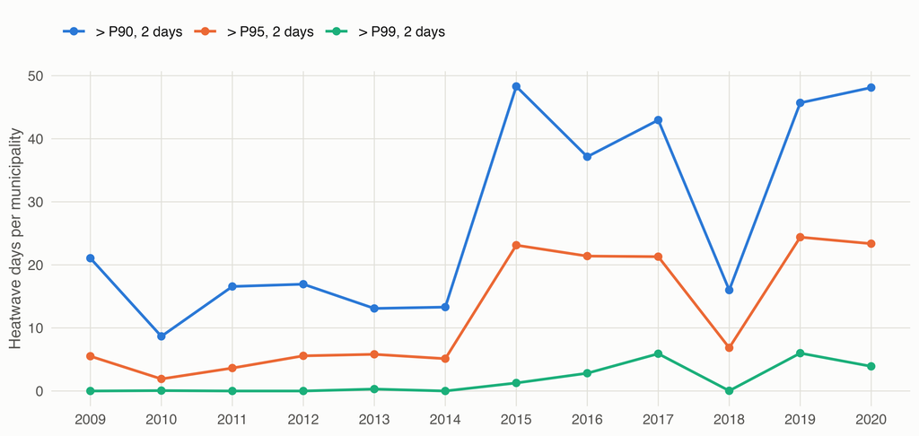

Figure 13: Heatwave days per municipality by calendar year, percentile definitions with two or more consecutive days.

```r
hw_years <- melt(analysis[, lapply(.SD, function(x) sum(x) / uniqueN(com)), by = year,
                          .SDcols = c("hw_p90_2d", "hw_p95_2d", "hw_p99_2d")],
                 id.vars = "year", variable.name = "indicator", value.name = "days")
hw_years[, indicator := factor(indicator, levels = c("hw_p90_2d", "hw_p95_2d", "hw_p99_2d"),
                               labels = c("> P90, 2 days", "> P95, 2 days", "> P99, 2 days"))]
ggplot(hw_years, aes(year, days, colour = indicator)) +
  geom_line(linewidth = 0.8) +
  geom_point(size = 1.8) +
  scale_colour_manual(values = c("> P90, 2 days" = "#2a78d6", "> P95, 2 days" = "#eb6834",
                                 "> P99, 2 days" = "#1baf7a")) +
  scale_x_continuous(breaks = 2009:2020) +
  labs(x = NULL, y = "Heatwave days per municipality", colour = NULL)
```

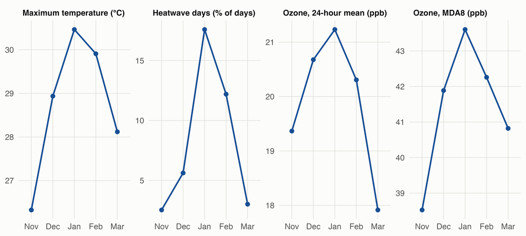

Figure 14: Seasonal profile: mean of the 33 municipalities by month of the warm season, 2009-2020.

```r
monthly <- analysis[, .(tmax = mean(tmax), o3 = mean(get(ozone_main), na.rm = TRUE),
                        mda8 = mean(o3mda8_idw, na.rm = TRUE),
                        hw = 100 * mean(get(heatwave_main))), by = .(month = month(date))]
monthly_long <- melt(monthly, id.vars = "month")
monthly_long[, month := factor(month, levels = c(11, 12, 1, 2, 3),
                               labels = c("Nov", "Dec", "Jan", "Feb", "Mar"))]
monthly_long[, variable := factor(variable, levels = c("tmax", "hw", "o3", "mda8"),
  labels = c("Maximum temperature (°C)", "Heatwave days (% of days)",
             "Ozone, 24-hour mean (ppb)", "Ozone, MDA8 (ppb)"))]
ggplot(monthly_long, aes(month, value, group = 1)) +
  geom_line(colour = ramp_blue[6], linewidth = 0.8) +
  geom_point(colour = ramp_blue[6], size = 1.8) +
  facet_wrap(~variable, nrow = 1, scales = "free_y") +
  labs(x = NULL, y = NULL)
```

## 5.3 Compound exposure

*Computed in this page from the exposure dataset, with `compound_category()` of `Code/01_functions.R`. The definition is in Compound exposure.*

A municipality-day belongs to one of four categories: neither exposure (E00), heatwave only (E10), high ozone only (E01), or both (E11).

```r
analysis[, category := compound_category(get(heatwave_main), get(ozone_flag_main))]
labels <- c(E00 = "Neither", E01 = "High ozone only", E10 = "Heatwave only",
            E11 = "Heatwave and high ozone")
analysis[, category_label := factor(labels[as.character(category)], levels = labels)]
overall <- analysis[!is.na(category), .(days = .N), keyby = category_label]
overall[, share := 100 * days / sum(days)]
p_hw <- analysis[!is.na(category), mean(get(heatwave_main))]
p_oz <- analysis[!is.na(category), mean(get(ozone_flag_main))]
p_both <- analysis[!is.na(category), mean(category == "E11")]
```

```r
kable(overall, digits = 1, format.args = list(big.mark = ","),
      col.names = c("Category", "Municipality-days", "%"))
```

Table 31: Municipality-days by compound exposure category, working definitions, warm seasons 2009-2020.

| Category | Municipality-days | % |
| --- | --- | --- |
| Neither | 42,886 | 71.6 |
| High ozone only | 12,125 | 20.2 |
| Heatwave only | 2,027 | 3.4 |
| Heatwave and high ozone | 2,857 | 4.8 |

Heatwave days are 8.2% of the municipality-days and high-ozone days 25.0%. If the two were independent, 2.0% of the days would have both; the observed share is 4.8%, 2.3 times the expected one. 58% of the heatwave days are also high-ozone days.

### 5.3.1 Maps

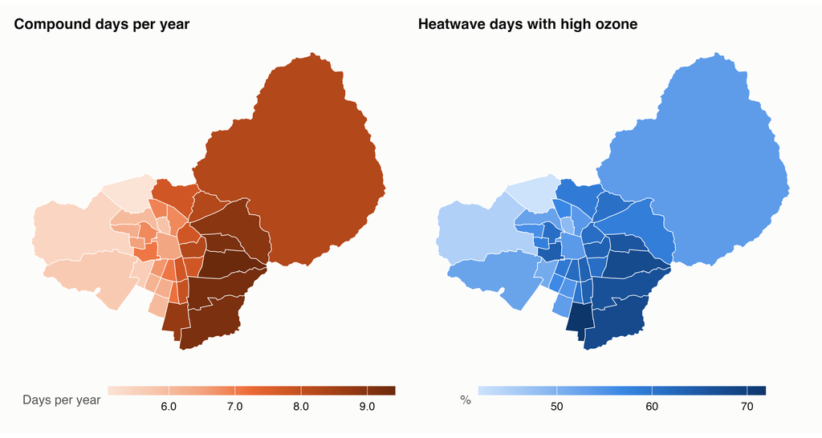

Figure 15: Compound exposure by municipality, working definitions, warm seasons 2009-2020. Left: days per year with a heatwave and high ozone. Right: share of heatwave days that are also high-ozone days.

```r
compound_mun <- analysis[!is.na(category), .(
  compound_days = sum(category == "E11") / 12,
  share_of_heatwave = 100 * sum(category == "E11") / sum(get(heatwave_main))
), by = com]
patchwork::wrap_plots(
  map_values(compound_mun, "compound_days", "Compound days per year", "Days per year",
             hue = "orange"),
  map_values(compound_mun, "share_of_heatwave", "Heatwave days with high ozone", "%",
             digits = 0),
  ncol = 2
)
```

### 5.3.2 By year

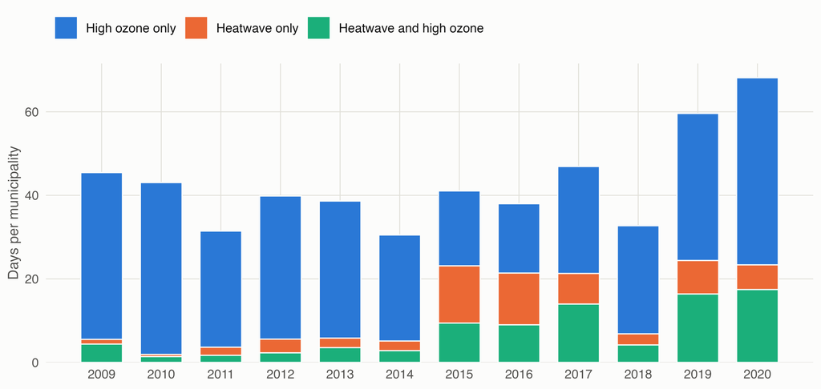

Figure 16: Exposed municipality-days by calendar year and category, working definitions, as days per municipality.

```r
by_year <- analysis[!is.na(category) & category != "E00",
                    .(days = .N / uniqueN(analysis$com)), by = .(year, category_label)]
ggplot(by_year, aes(year, days, fill = category_label)) +
  geom_col(width = 0.7, colour = ink$surface, linewidth = 0.4) +
  scale_fill_manual(values = colour_compound, drop = TRUE) +
  scale_x_continuous(breaks = 2009:2020) +
  scale_y_continuous(expand = expansion(mult = c(0, 0.05))) +
  labs(x = NULL, y = "Days per municipality", fill = NULL)
```

```r
kable(dcast(by_year, year ~ category_label, value.var = "days", fill = 0), digits = 1)
```

Table 32: Days per municipality by calendar year and category.

| year | High ozone only | Heatwave only | Heatwave and high ozone |
| --- | --- | --- | --- |
| 2009 | 39.9 | 1.1 | 4.4 |
| 2010 | 41.2 | 0.5 | 1.4 |
| 2011 | 27.8 | 1.9 | 1.7 |
| 2012 | 34.3 | 3.3 | 2.3 |
| 2013 | 32.8 | 2.3 | 3.5 |
| 2014 | 25.4 | 2.3 | 2.8 |
| 2015 | 17.9 | 13.7 | 9.4 |
| 2016 | 16.6 | 12.4 | 9.0 |
| 2017 | 25.6 | 7.3 | 14.0 |
| 2018 | 25.9 | 2.7 | 4.2 |
| 2019 | 35.2 | 8.0 | 16.4 |
| 2020 | 44.8 | 5.9 | 17.5 |

### 5.3.3 Across the grid of definitions

*Script: `Code/13_exposure_merge_qc.R`. Tables: `Output/Tables/compound_frequency_by_municipality.csv` and `compound_frequency_by_year.csv`.*

Share of municipality-days with both exposures, for the 15 heatwave definitions and the three ozone cut-offs, with the ozone series in use (o3_idw).

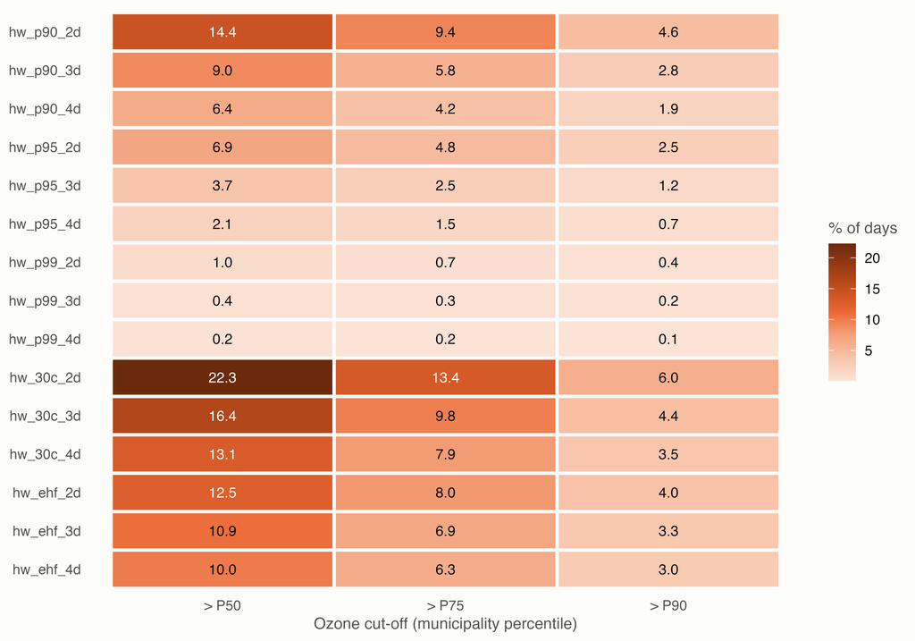

Figure 17: Compound days (% of municipality-days) by heatwave definition and ozone cut-off.

```r
grid <- read_table("compound_frequency_by_municipality.csv")
grid <- grid[grepl(paste0("^", ozone_main, "_gt_p"), ozone),
             .(e11 = sum(e11), e10 = sum(e10), e01 = sum(e01), classified = sum(days - not_classified)),
             by = .(heatwave, ozone)]
grid[, `:=`(share = 100 * e11 / classified,
            ratio = (e11 / classified) / (((e11 + e10) / classified) * ((e11 + e01) / classified)),
            cutoff = paste0("> P", sub(".*_gt_p", "", ozone)))]
grid[, heatwave := factor(heatwave, levels = rev(unique(heatwave)))]
ggplot(grid, aes(cutoff, heatwave, fill = share)) +
  geom_tile(colour = ink$surface, linewidth = 1) +
  geom_text(aes(label = sprintf("%.1f", share),
                colour = share > max(share) * 0.55), size = 3.2, show.legend = FALSE) +
  scale_colour_manual(values = c(`TRUE` = "#ffffff", `FALSE` = ink$primary)) +
  scale_fill_magnitude(name = "% of days", hue = "orange") +
  labs(x = "Ozone cut-off (municipality percentile)", y = NULL) +
  theme(panel.grid.major = element_blank(), legend.position = "right",
        legend.justification = "center")
```

```r
kableExtra::scroll_box(
  kableExtra::kable_styling(
    kable(grid[order(-as.integer(heatwave), cutoff),
               .(heatwave, cutoff, e11, share, e10, e01, ratio)],
          format = "html", digits = c(0, 0, 0, 2, 0, 0, 2), format.args = list(big.mark = ","),
          col.names = c("Heatwave", "Ozone cut-off", "Compound days (E11)", "% of days",
                        "Heatwave only (E10)", "High ozone only (E01)",
                        "Observed / expected")),
    bootstrap_options = c("striped", "condensed"), font_size = 12),
  height = "420px"
)
```

Table 33: Compound exposure across the grid: days with both exposures, and the ratio of the observed share to the share expected if heatwaves and high ozone were independent.

| Heatwave | Ozone cut-off | Compound days (E11) | % of days | Heatwave only (E10) | High ozone only (E01) | Observed / expected |
| --- | --- | --- | --- | --- | --- | --- |
| hw_p90_2d | > P50 | 8,652 | 14.45 | 2,168 | 21,279 | 1.60 |
| hw_p90_2d | > P75 | 5,614 | 9.37 | 5,206 | 9,368 | 2.07 |
| hw_p90_2d | > P90 | 2,743 | 4.58 | 8,077 | 3,263 | 2.53 |
| hw_p90_3d | > P50 | 5,367 | 8.96 | 1,483 | 24,564 | 1.57 |
| hw_p90_3d | > P75 | 3,461 | 5.78 | 3,389 | 11,521 | 2.02 |
| hw_p90_3d | > P90 | 1,687 | 2.82 | 5,163 | 4,319 | 2.46 |
| hw_p90_4d | > P50 | 3,850 | 6.43 | 1,079 | 26,081 | 1.56 |
| hw_p90_4d | > P75 | 2,489 | 4.16 | 2,440 | 12,493 | 2.02 |
| hw_p90_4d | > P90 | 1,167 | 1.95 | 3,762 | 4,839 | 2.36 |
| hw_p95_2d | > P50 | 4,157 | 6.94 | 727 | 25,774 | 1.70 |
| hw_p95_2d | > P75 | 2,857 | 4.77 | 2,027 | 12,125 | 2.34 |
| hw_p95_2d | > P90 | 1,514 | 2.53 | 3,370 | 4,492 | 3.09 |
| hw_p95_3d | > P50 | 2,227 | 3.72 | 408 | 27,704 | 1.69 |
| hw_p95_3d | > P75 | 1,498 | 2.50 | 1,137 | 13,484 | 2.27 |
| hw_p95_3d | > P90 | 746 | 1.25 | 1,889 | 5,260 | 2.82 |
| hw_p95_4d | > P50 | 1,284 | 2.14 | 236 | 28,647 | 1.69 |
| hw_p95_4d | > P75 | 893 | 1.49 | 627 | 14,089 | 2.35 |
| hw_p95_4d | > P90 | 444 | 0.74 | 1,076 | 5,562 | 2.91 |
| hw_p99_2d | > P50 | 597 | 1.00 | 73 | 29,334 | 1.78 |
| hw_p99_2d | > P75 | 414 | 0.69 | 256 | 14,568 | 2.47 |
| hw_p99_2d | > P90 | 211 | 0.35 | 459 | 5,795 | 3.14 |
| hw_p99_3d | > P50 | 240 | 0.40 | 33 | 29,691 | 1.76 |
| hw_p99_3d | > P75 | 182 | 0.30 | 91 | 14,800 | 2.67 |
| hw_p99_3d | > P90 | 108 | 0.18 | 165 | 5,898 | 3.95 |
| hw_p99_4d | > P50 | 104 | 0.17 | 5 | 29,827 | 1.91 |
| hw_p99_4d | > P75 | 94 | 0.16 | 15 | 14,888 | 3.45 |
| hw_p99_4d | > P90 | 65 | 0.11 | 44 | 5,941 | 5.95 |
| hw_30c_2d | > P50 | 13,342 | 22.28 | 5,399 | 16,589 | 1.42 |
| hw_30c_2d | > P75 | 7,999 | 13.36 | 10,742 | 6,983 | 1.71 |
| hw_30c_2d | > P90 | 3,577 | 5.97 | 15,164 | 2,429 | 1.90 |
| hw_30c_3d | > P50 | 9,805 | 16.37 | 4,293 | 20,126 | 1.39 |
| hw_30c_3d | > P75 | 5,840 | 9.75 | 8,258 | 9,142 | 1.66 |
| hw_30c_3d | > P90 | 2,646 | 4.42 | 11,452 | 3,360 | 1.87 |
| hw_30c_4d | > P50 | 7,846 | 13.10 | 3,409 | 22,085 | 1.39 |
| hw_30c_4d | > P75 | 4,710 | 7.86 | 6,545 | 10,272 | 1.67 |
| hw_30c_4d | > P90 | 2,100 | 3.51 | 9,155 | 3,906 | 1.86 |
| hw_ehf_2d | > P50 | 7,489 | 12.50 | 2,192 | 22,442 | 1.55 |
| hw_ehf_2d | > P75 | 4,799 | 8.01 | 4,882 | 10,183 | 1.98 |
| hw_ehf_2d | > P90 | 2,407 | 4.02 | 7,274 | 3,599 | 2.48 |
| hw_ehf_3d | > P50 | 6,502 | 10.86 | 2,487 | 23,429 | 1.45 |
| hw_ehf_3d | > P75 | 4,109 | 6.86 | 4,880 | 10,873 | 1.83 |
| hw_ehf_3d | > P90 | 1,998 | 3.34 | 6,991 | 4,008 | 2.22 |
| hw_ehf_4d | > P50 | 5,983 | 9.99 | 2,271 | 23,948 | 1.45 |
| hw_ehf_4d | > P75 | 3,768 | 6.29 | 4,486 | 11,214 | 1.83 |
| hw_ehf_4d | > P90 | 1,809 | 3.02 | 6,445 | 4,197 | 2.19 |

The frequency tables for every ozone series, by municipality and by year, are in `Output/Tables/compound_frequency_by_municipality.csv` and `Output/Tables/compound_frequency_by_year.csv`.

## 5.4 Time series of every municipality and of their mean

*Script: `Code/18_exposure_time_series.R`. Tables, in `Output/Tables`: `series_daily_all_municipalities.csv`, `series_monthly_by_municipality.csv` and `series_annual_by_municipality.csv`. Figures, in `Output/Figures`: `series_1_daily_temperature_ozone` to `series_7_municipalities_heatwave_days`, each as PDF and as PNG at 600 dpi. The script writes the tables and draws every figure from them; this page shows the files.*

The figures and the tables above describe the municipalities as a group. This section follows every municipality, and the mean of the 33, over the whole study period: the 1,815 days of the warm seasons of 2009 to 2020, by day, by month and by calendar year.

- **Definitions.** The working definitions of `config/config.yml`: heatwave hw_p95_2d (P95, 2 days), ozone series o3_idw, high ozone above the 75th percentile of the municipality. The daily maximum 8-hour mean is the series rebuilt from the validated hourly records (`o3mda8_idw`).
- **Mean of the 33 municipalities.** The plain mean of the 33 municipal values: every municipality counts the same, whatever its population or its area.
- **Days without a value.** The delivered ozone has a value on every day of analysis. The rebuilt MDA8 is missing in at least one municipality on 14 days, on 2 of them in all: the means are taken over the municipalities, or the days, that have a value, and the tables written by the script give their number.

### 5.4.1 Day by day

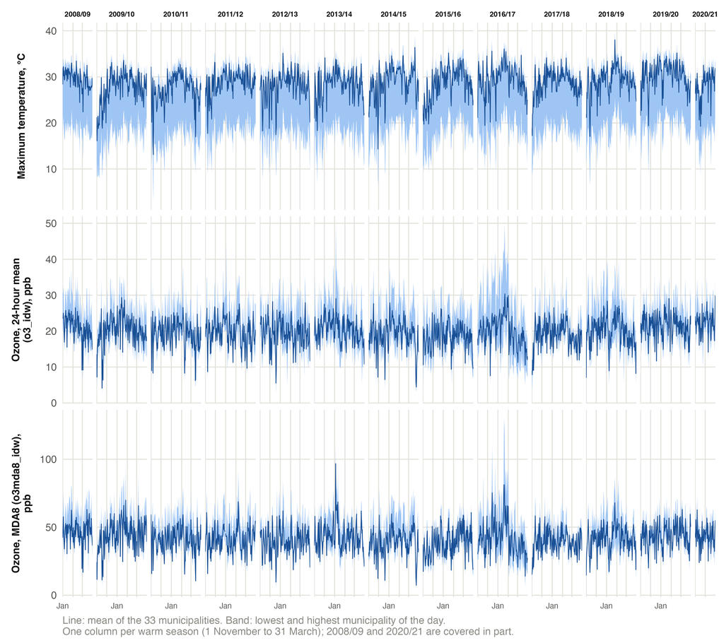

Figure 18: Daily maximum temperature and ozone over the whole study period. Line: mean of the 33 municipalities. Band: the lowest and the highest municipality of each day. One column per warm season. File `series_1_daily_temperature_ozone.png`.

```r
knitr::include_graphics(series_figure("series_1_daily_temperature_ozone"))
```

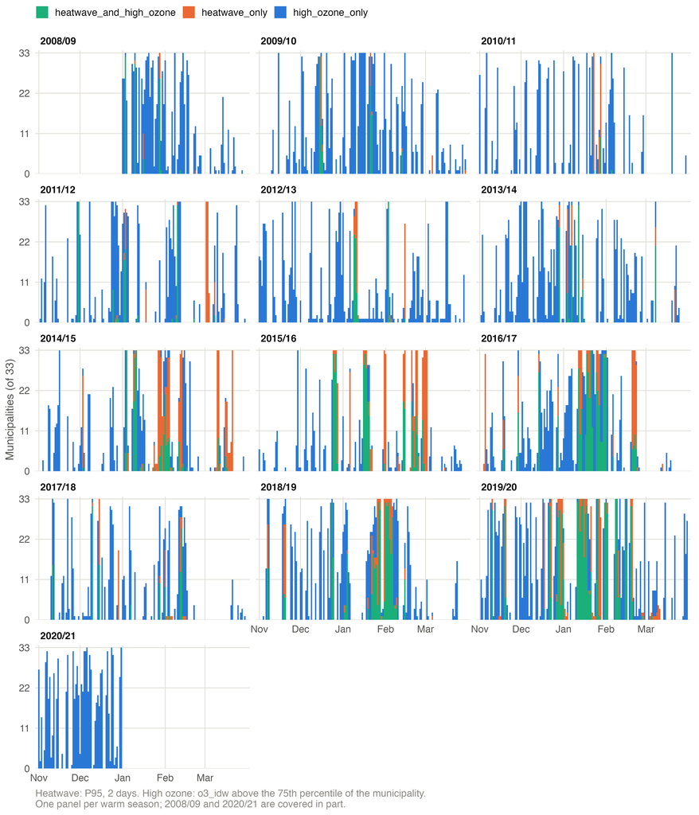

Figure 19: Municipalities with a heatwave, with high ozone or with both, day by day, in each warm season of the study period (working definitions). File `series_2_daily_compound_exposure.png`.

```r
knitr::include_graphics(series_figure("series_2_daily_compound_exposure"))
```

```r
by_season <- series_daily[, .(
  days = .N, tmax = mean(tmax_mean), o3 = mean(o3_mean, na.rm = TRUE),
  mda8 = mean(mda8_mean, na.rm = TRUE),
  heatwave_any = sum(with_heatwave > 0), heatwave_all = sum(with_heatwave == municipalities),
  compound_any = sum(heatwave_and_high_ozone > 0),
  compound_all = sum(heatwave_and_high_ozone == municipalities)
), by = season]
kable(by_season, digits = c(0, 0, 1, 1, 1, 0, 0, 0, 0),
      col.names = c("Warm season", "Days", "Maximum temperature (°C)", "Ozone, 24-hour mean (ppb)",
                    "Ozone, MDA8 (ppb)", "Heatwave in 1 or more municipalities (days)",
                    "Heatwave in all 33 (days)", "Heatwave and high ozone in 1 or more (days)",
                    "Heatwave and high ozone in all 33 (days)"))
```

Table 34: The warm seasons of the study period: days of analysis, mean of the daily means of the 33 municipalities, and days on which a heatwave, or a heatwave with high ozone, reaches at least one municipality and all of them (working definitions).

| Warm season | Days | Maximum temperature (°C) | Ozone, 24-hour mean (ppb) | Ozone, MDA8 (ppb) | Heatwave in 1 or more municipalities (days) | Heatwave in all 33 (days) | Heatwave and high ozone in 1 or more (days) | Heatwave and high ozone in all 33 (days) |
| --- | --- | --- | --- | --- | --- | --- | --- | --- |
| 2008/09 | 90 | 29.5 | 20.9 | 46.4 | 7 | 1 | 6 | 0 |
| 2009/10 | 151 | 27.6 | 20.3 | 44.0 | 8 | 1 | 6 | 0 |
| 2010/11 | 151 | 27.4 | 19.3 | 40.2 | 4 | 1 | 3 | 0 |
| 2011/12 | 152 | 28.9 | 19.6 | 41.0 | 18 | 4 | 12 | 1 |
| 2012/13 | 151 | 28.1 | 19.4 | 39.5 | 8 | 3 | 7 | 1 |
| 2013/14 | 151 | 28.4 | 20.4 | 43.1 | 8 | 0 | 7 | 0 |
| 2014/15 | 151 | 29.0 | 19.1 | 38.8 | 40 | 9 | 24 | 2 |
| 2015/16 | 152 | 28.7 | 18.5 | 38.6 | 30 | 14 | 19 | 0 |
| 2016/17 | 151 | 29.5 | 20.0 | 41.9 | 30 | 12 | 26 | 1 |
| 2017/18 | 151 | 28.7 | 19.0 | 39.3 | 17 | 1 | 9 | 0 |
| 2018/19 | 151 | 29.2 | 20.0 | 41.5 | 30 | 9 | 28 | 0 |
| 2019/20 | 152 | 30.3 | 21.6 | 44.0 | 56 | 22 | 39 | 6 |
| 2020/21 | 61 | 28.1 | 22.4 | 43.5 | 0 | 0 | 0 | 0 |

The seasons 2008/09 and 2020/21 are covered in part: the study period starts on 1 January 2009 and ends on 31 December 2020.

### 5.4.2 Month by month

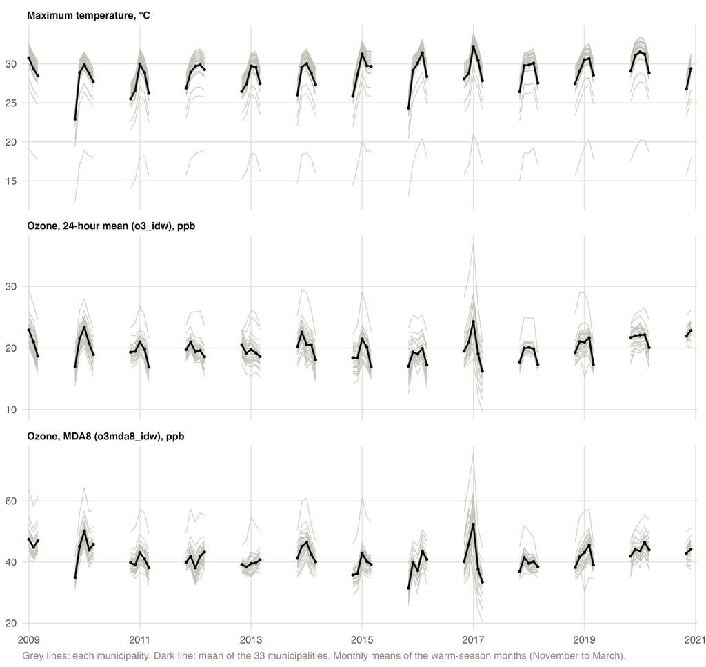

Figure 20: Monthly means of maximum temperature and ozone, warm-season months of 2009 to 2020. Grey lines: each municipality. Dark line: mean of the 33 municipalities. File `series_3_monthly_by_municipality.png`.

```r
knitr::include_graphics(series_figure("series_3_monthly_by_municipality"))
```

```r
long_table(kable(
  monthly_mean[order(year, month), .(year, month = month.name[month], days, tmax, o3, mda8,
                                     heatwave_days, high_ozone_days, compound_days)],
  format = "html", digits = c(0, 0, 0, 1, 1, 1, 1, 1, 1),
  col.names = c("Year", "Month", "Days", "Maximum temperature (°C)", "Ozone, 24-hour mean (ppb)",
                "Ozone, MDA8 (ppb)", "Heatwave days", "High-ozone days",
                "Days with heatwave and high ozone")))
```

Table 35: Mean of the 33 municipalities by month: means of temperature and ozone, and days of exposure per municipality (working definitions).

| Year | Month | Days | Maximum temperature (°C) | Ozone, 24-hour mean (ppb) | Ozone, MDA8 (ppb) | Heatwave days | High-ozone days | Days with heatwave and high ozone |
| --- | --- | --- | --- | --- | --- | --- | --- | --- |
| 2009 | January | 31 | 30.8 | 22.9 | 47.4 | 3.3 | 19.5 | 2.8 |
| 2009 | February | 28 | 29.4 | 21.0 | 44.8 | 0.1 | 9.1 | 0.0 |
| 2009 | March | 31 | 28.5 | 18.7 | 46.9 | 0.0 | 2.1 | 0.0 |
| 2009 | November | 30 | 22.9 | 17.0 | 34.9 | 0.0 | 3.1 | 0.0 |
| 2009 | December | 31 | 28.9 | 21.5 | 45.0 | 2.2 | 10.6 | 1.5 |
| 2010 | January | 31 | 29.9 | 23.3 | 50.1 | 1.5 | 18.5 | 1.2 |
| 2010 | February | 28 | 28.8 | 20.8 | 43.9 | 0.2 | 8.6 | 0.2 |
| 2010 | March | 31 | 27.8 | 18.9 | 45.8 | 0.2 | 2.8 | 0.0 |
| 2010 | November | 30 | 25.5 | 19.3 | 39.8 | 0.0 | 5.3 | 0.0 |
| 2010 | December | 31 | 26.6 | 19.5 | 39.0 | 0.0 | 7.4 | 0.0 |
| 2011 | January | 31 | 30.0 | 21.0 | 43.0 | 2.2 | 8.1 | 0.3 |
| 2011 | February | 28 | 28.8 | 19.8 | 41.0 | 0.0 | 6.0 | 0.0 |
| 2011 | March | 31 | 26.2 | 16.9 | 38.2 | 0.0 | 1.2 | 0.0 |
| 2011 | November | 30 | 26.9 | 19.7 | 39.9 | 1.0 | 5.6 | 1.0 |
| 2011 | December | 31 | 28.9 | 21.0 | 41.8 | 0.4 | 8.6 | 0.3 |
| 2012 | January | 31 | 29.7 | 19.4 | 38.1 | 1.8 | 6.5 | 1.2 |
| 2012 | February | 29 | 29.9 | 19.6 | 41.8 | 1.1 | 8.3 | 1.1 |
| 2012 | March | 31 | 29.3 | 18.6 | 43.3 | 2.6 | 4.2 | 0.1 |
| 2012 | November | 30 | 26.5 | 20.5 | 39.2 | 0.0 | 10.0 | 0.0 |
| 2012 | December | 31 | 27.4 | 19.2 | 38.4 | 0.0 | 7.6 | 0.0 |
| 2013 | January | 31 | 29.7 | 19.7 | 39.5 | 2.9 | 5.4 | 1.7 |
| 2013 | February | 28 | 29.6 | 19.2 | 39.7 | 1.9 | 5.9 | 1.1 |
| 2013 | March | 31 | 27.5 | 18.6 | 40.7 | 0.0 | 4.4 | 0.0 |
| 2013 | November | 30 | 26.0 | 20.2 | 41.2 | 0.0 | 6.4 | 0.0 |
| 2013 | December | 31 | 29.6 | 22.6 | 45.1 | 1.0 | 14.3 | 0.8 |
| 2014 | January | 31 | 30.0 | 20.6 | 46.4 | 3.3 | 9.9 | 2.2 |
| 2014 | February | 28 | 28.8 | 20.5 | 42.4 | 0.0 | 7.3 | 0.0 |
| 2014 | March | 31 | 27.3 | 18.1 | 40.1 | 1.1 | 2.3 | 0.6 |
| 2014 | November | 30 | 25.9 | 18.4 | 35.8 | 0.0 | 4.4 | 0.0 |
| 2014 | December | 31 | 28.6 | 18.4 | 36.3 | 0.8 | 4.3 | 0.0 |
| 2015 | January | 31 | 31.3 | 21.4 | 42.8 | 8.6 | 10.1 | 4.4 |
| 2015 | February | 28 | 29.8 | 20.1 | 40.2 | 6.0 | 6.8 | 1.8 |
| 2015 | March | 31 | 29.7 | 17.0 | 39.2 | 4.8 | 1.2 | 0.4 |
| 2015 | November | 30 | 24.3 | 17.0 | 31.5 | 0.0 | 2.3 | 0.0 |
| 2015 | December | 31 | 29.2 | 19.3 | 39.9 | 3.7 | 7.0 | 2.8 |
| 2016 | January | 31 | 30.1 | 19.0 | 37.2 | 6.3 | 6.2 | 3.8 |
| 2016 | February | 29 | 31.4 | 19.9 | 43.5 | 9.1 | 4.6 | 3.3 |
| 2016 | March | 31 | 28.4 | 17.2 | 40.9 | 2.0 | 1.4 | 0.0 |
| 2016 | November | 30 | 28.1 | 19.5 | 40.1 | 2.2 | 3.5 | 0.7 |
| 2016 | December | 31 | 28.8 | 20.9 | 45.8 | 1.7 | 9.8 | 1.3 |
| 2017 | January | 31 | 32.2 | 24.3 | 52.4 | 13.1 | 20.8 | 10.2 |
| 2017 | February | 28 | 30.4 | 19.1 | 37.5 | 5.2 | 5.5 | 2.0 |
| 2017 | March | 31 | 27.8 | 16.2 | 33.5 | 0.1 | 0.3 | 0.0 |
| 2017 | November | 30 | 26.4 | 17.7 | 37.0 | 0.5 | 5.5 | 0.5 |
| 2017 | December | 31 | 29.8 | 20.0 | 41.5 | 2.5 | 7.5 | 1.4 |
| 2018 | January | 31 | 29.9 | 20.1 | 39.5 | 0.5 | 5.9 | 0.4 |
| 2018 | February | 28 | 30.1 | 19.9 | 40.1 | 2.5 | 6.7 | 1.5 |
| 2018 | March | 31 | 27.6 | 17.3 | 38.4 | 0.0 | 0.8 | 0.0 |
| 2018 | November | 30 | 27.5 | 19.3 | 38.2 | 2.4 | 6.3 | 0.8 |
| 2018 | December | 31 | 29.1 | 21.0 | 41.7 | 1.5 | 10.3 | 1.5 |
| 2019 | January | 31 | 30.5 | 20.9 | 43.1 | 7.4 | 11.2 | 4.6 |
| 2019 | February | 28 | 30.7 | 21.7 | 45.5 | 6.8 | 12.0 | 5.6 |
| 2019 | March | 31 | 28.6 | 17.3 | 39.1 | 0.0 | 1.3 | 0.0 |
| 2019 | November | 30 | 29.1 | 21.7 | 41.9 | 3.1 | 12.5 | 2.0 |
| 2019 | December | 31 | 31.1 | 22.0 | 44.1 | 7.2 | 14.6 | 4.1 |
| 2020 | January | 31 | 31.5 | 22.1 | 43.6 | 14.5 | 14.1 | 10.5 |
| 2020 | February | 29 | 31.2 | 22.1 | 46.5 | 8.4 | 13.0 | 6.9 |
| 2020 | March | 31 | 28.8 | 20.1 | 44.0 | 0.5 | 5.9 | 0.0 |
| 2020 | November | 30 | 26.8 | 22.0 | 42.8 | 0.0 | 12.7 | 0.0 |
| 2020 | December | 31 | 29.4 | 22.8 | 44.1 | 0.0 | 16.6 | 0.0 |

### 5.4.3 Year by year

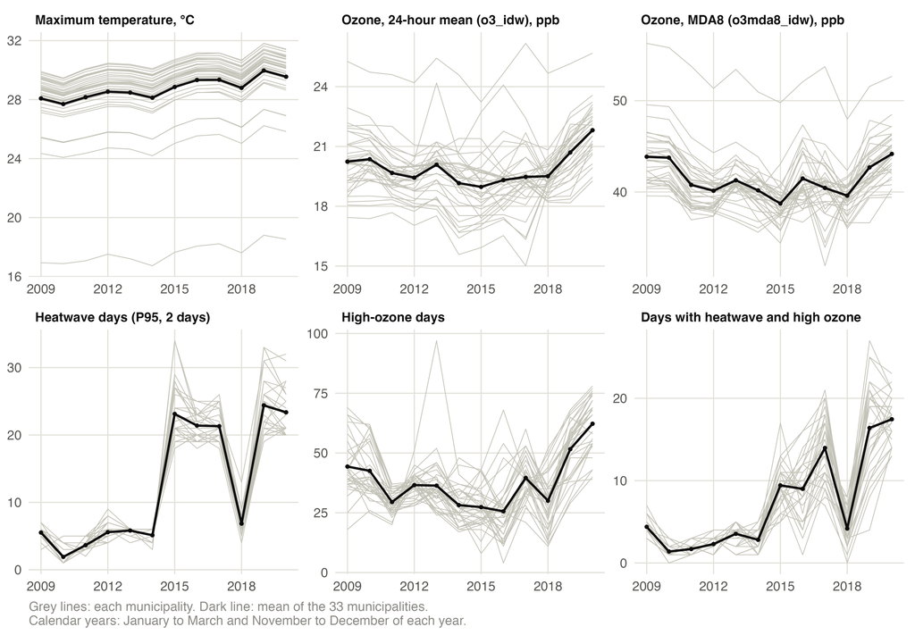

Figure 21: Annual means and days of exposure by calendar year (January to March and November to December). Grey lines: each municipality. Dark line: mean of the 33 municipalities. File `series_4_annual_by_municipality.png`.

```r
knitr::include_graphics(series_figure("series_4_annual_by_municipality"))
```

```r
kable(annual_mean[order(year), .(year, days, tmax, o3, mda8, heatwave_days, high_ozone_days,
                                 heatwave_only_days, compound_days)],
      digits = c(0, 0, 1, 1, 1, 1, 1, 1, 1),
      col.names = c("Year", "Days", "Maximum temperature (°C)", "Ozone, 24-hour mean (ppb)",
                    "Ozone, MDA8 (ppb)", "Heatwave days", "High-ozone days", "Heatwave-only days",
                    "Days with heatwave and high ozone"))
```

Table 36: Mean of the 33 municipalities by calendar year: means of temperature and ozone, and days of exposure per municipality (working definitions).

| Year | Days | Maximum temperature (°C) | Ozone, 24-hour mean (ppb) | Ozone, MDA8 (ppb) | Heatwave days | High-ozone days | Heatwave-only days | Days with heatwave and high ozone |
| --- | --- | --- | --- | --- | --- | --- | --- | --- |
| 2009 | 151 | 28.1 | 20.2 | 43.9 | 5.5 | 44.3 | 1.1 | 4.4 |
| 2010 | 151 | 27.7 | 20.4 | 43.7 | 1.9 | 42.5 | 0.5 | 1.4 |
| 2011 | 151 | 28.2 | 19.7 | 40.8 | 3.6 | 29.5 | 1.9 | 1.7 |
| 2012 | 152 | 28.5 | 19.4 | 40.1 | 5.6 | 36.6 | 3.3 | 2.3 |
| 2013 | 151 | 28.5 | 20.1 | 41.3 | 5.8 | 36.4 | 2.3 | 3.5 |
| 2014 | 151 | 28.1 | 19.2 | 40.2 | 5.1 | 28.2 | 2.3 | 2.8 |
| 2015 | 151 | 28.9 | 19.0 | 38.7 | 23.1 | 27.4 | 13.7 | 9.4 |
| 2016 | 152 | 29.3 | 19.3 | 41.5 | 21.4 | 25.6 | 12.4 | 9.0 |
| 2017 | 151 | 29.3 | 19.5 | 40.4 | 21.3 | 39.6 | 7.3 | 14.0 |
| 2018 | 151 | 28.8 | 19.5 | 39.6 | 6.8 | 30.1 | 2.7 | 4.2 |
| 2019 | 151 | 30.0 | 20.7 | 42.7 | 24.4 | 51.6 | 8.0 | 16.4 |
| 2020 | 152 | 29.6 | 21.8 | 44.2 | 23.4 | 62.2 | 5.9 | 17.5 |

The values of every municipality, one table per variable; the last row of each is the mean of the 33 municipalities.

**Maximum temperature**

```r
wide_by_year("tmax", 1)
```

Table 37: Mean maximum temperature (°C) by municipality and calendar year, warm-season days.

| Municipality | 2009 | 2010 | 2011 | 2012 | 2013 | 2014 | 2015 | 2016 | 2017 | 2018 | 2019 | 2020 |
| --- | --- | --- | --- | --- | --- | --- | --- | --- | --- | --- | --- | --- |
| Santiago | 28.9 | 28.5 | 29.0 | 29.3 | 29.3 | 28.9 | 29.7 | 30.1 | 30.1 | 29.6 | 30.7 | 30.3 |
| Cerrillos | 29.5 | 29.0 | 29.6 | 30.0 | 30.0 | 29.7 | 30.3 | 30.8 | 30.7 | 30.2 | 31.4 | 30.9 |
| Cerro Navia | 29.9 | 29.5 | 30.1 | 30.5 | 30.4 | 30.1 | 30.7 | 31.2 | 31.2 | 30.7 | 31.8 | 31.4 |
| Conchalí | 29.2 | 28.8 | 29.3 | 29.7 | 29.6 | 29.3 | 30.0 | 30.4 | 30.5 | 29.9 | 31.1 | 30.7 |
| El Bosque | 28.6 | 28.2 | 28.7 | 29.1 | 29.1 | 28.8 | 29.5 | 30.0 | 29.9 | 29.3 | 30.5 | 30.1 |
| Estación Central | 29.6 | 29.1 | 29.7 | 30.1 | 30.0 | 29.7 | 30.4 | 30.8 | 30.8 | 30.3 | 31.4 | 31.0 |
| Huechuraba | 27.7 | 27.4 | 27.8 | 28.2 | 28.1 | 27.8 | 28.5 | 28.9 | 29.0 | 28.5 | 29.7 | 29.3 |
| Independencia | 29.0 | 28.6 | 29.1 | 29.4 | 29.4 | 29.0 | 29.7 | 30.2 | 30.2 | 29.7 | 30.9 | 30.5 |
| La Cisterna | 28.7 | 28.3 | 28.8 | 29.2 | 29.1 | 28.8 | 29.5 | 30.0 | 29.9 | 29.4 | 30.5 | 30.1 |
| La Florida | 25.4 | 25.1 | 25.4 | 25.8 | 25.7 | 25.3 | 26.2 | 26.7 | 26.7 | 26.1 | 27.3 | 26.9 |
| La Granja | 28.4 | 28.0 | 28.4 | 28.7 | 28.7 | 28.4 | 29.1 | 29.6 | 29.6 | 29.0 | 30.2 | 29.8 |
| La Pintana | 28.0 | 27.6 | 28.0 | 28.4 | 28.4 | 28.0 | 28.8 | 29.3 | 29.2 | 28.7 | 29.9 | 29.5 |
| La Reina | 27.5 | 27.2 | 27.5 | 27.8 | 27.8 | 27.4 | 28.2 | 28.7 | 28.8 | 28.2 | 29.4 | 28.9 |
| Las Condes | 24.3 | 24.1 | 24.4 | 24.7 | 24.6 | 24.2 | 25.0 | 25.5 | 25.6 | 25.0 | 26.2 | 25.8 |
| Lo Barnechea | 16.9 | 16.9 | 17.1 | 17.5 | 17.2 | 16.7 | 17.6 | 18.1 | 18.2 | 17.6 | 18.8 | 18.5 |
| Lo Espejo | 29.1 | 28.7 | 29.2 | 29.6 | 29.5 | 29.2 | 29.9 | 30.4 | 30.3 | 29.8 | 30.9 | 30.5 |
| Lo Prado | 29.5 | 29.1 | 29.7 | 30.0 | 30.0 | 29.7 | 30.3 | 30.8 | 30.7 | 30.2 | 31.4 | 31.0 |
| Macul | 28.8 | 28.4 | 28.8 | 29.2 | 29.2 | 28.8 | 29.6 | 30.1 | 30.1 | 29.5 | 30.7 | 30.3 |
| Maipú | 29.4 | 29.0 | 29.6 | 30.0 | 29.9 | 29.7 | 30.3 | 30.8 | 30.7 | 30.2 | 31.4 | 30.9 |
| Ñuñoa | 28.7 | 28.3 | 28.7 | 29.1 | 29.0 | 28.6 | 29.4 | 29.9 | 29.9 | 29.4 | 30.5 | 30.1 |
| Pedro Aguirre Cerda | 29.4 | 28.9 | 29.4 | 29.8 | 29.8 | 29.4 | 30.1 | 30.6 | 30.6 | 30.0 | 31.2 | 30.8 |
| Peñalolén | 25.4 | 25.1 | 25.4 | 25.8 | 25.8 | 25.3 | 26.2 | 26.7 | 26.8 | 26.1 | 27.3 | 26.9 |
| Providencia | 28.3 | 27.9 | 28.3 | 28.7 | 28.6 | 28.3 | 29.0 | 29.5 | 29.5 | 29.0 | 30.2 | 29.7 |
| Pudahuel | 28.7 | 28.3 | 28.9 | 29.3 | 29.2 | 29.0 | 29.6 | 30.1 | 30.1 | 29.7 | 30.8 | 30.3 |
| Quilicura | 29.8 | 29.4 | 30.0 | 30.4 | 30.3 | 30.0 | 30.6 | 31.1 | 31.2 | 30.6 | 31.8 | 31.4 |
| Quinta Normal | 29.5 | 29.0 | 29.6 | 30.0 | 29.9 | 29.6 | 30.3 | 30.7 | 30.7 | 30.2 | 31.3 | 30.9 |
| Recoleta | 28.2 | 27.9 | 28.3 | 28.7 | 28.6 | 28.3 | 29.0 | 29.5 | 29.5 | 29.0 | 30.1 | 29.7 |
| Renca | 29.7 | 29.3 | 29.9 | 30.3 | 30.2 | 29.9 | 30.5 | 31.0 | 31.0 | 30.5 | 31.6 | 31.2 |
| San Joaquín | 28.7 | 28.3 | 28.7 | 29.1 | 29.1 | 28.7 | 29.5 | 29.9 | 30.0 | 29.4 | 30.6 | 30.1 |
| San Miguel | 28.8 | 28.4 | 28.8 | 29.2 | 29.2 | 28.8 | 29.6 | 30.0 | 30.0 | 29.4 | 30.6 | 30.2 |
| San Ramón | 28.5 | 28.1 | 28.5 | 28.9 | 28.9 | 28.5 | 29.3 | 29.7 | 29.7 | 29.1 | 30.3 | 29.9 |
| Vitacura | 27.3 | 27.0 | 27.3 | 27.7 | 27.6 | 27.2 | 28.0 | 28.5 | 28.5 | 28.0 | 29.2 | 28.8 |
| Puente Alto | 27.1 | 26.8 | 27.2 | 27.5 | 27.5 | 27.1 | 28.0 | 28.5 | 28.5 | 27.8 | 29.1 | 28.6 |
| Mean of the 33 municipalities | 28.1 | 27.7 | 28.2 | 28.5 | 28.5 | 28.1 | 28.9 | 29.3 | 29.3 | 28.8 | 30.0 | 29.6 |

**Ozone, 24-hour mean**

```r
wide_by_year("o3", 1)
```

Table 38: Mean ozone, 24-hour mean of the delivered series (ppb), by municipality and calendar year, warm-season days.

| Municipality | 2009 | 2010 | 2011 | 2012 | 2013 | 2014 | 2015 | 2016 | 2017 | 2018 | 2019 | 2020 |
| --- | --- | --- | --- | --- | --- | --- | --- | --- | --- | --- | --- | --- |
| Santiago | 18.2 | 18.3 | 18.3 | 17.9 | 18.4 | 16.9 | 17.1 | 17.4 | 16.3 | 19.2 | 19.9 | 21.0 |
| Cerrillos | 22.9 | 22.5 | 21.0 | 20.5 | 20.8 | 21.4 | 21.4 | 19.8 | 19.2 | 19.4 | 20.3 | 22.0 |
| Cerro Navia | 18.7 | 19.3 | 19.0 | 19.6 | 21.2 | 19.6 | 18.9 | 19.5 | 21.7 | 19.3 | 22.1 | 22.1 |
| Conchalí | 18.5 | 18.5 | 18.4 | 18.3 | 19.3 | 17.5 | 17.5 | 17.6 | 17.2 | 19.3 | 20.1 | 21.1 |
| El Bosque | 18.5 | 19.9 | 18.5 | 18.0 | 17.8 | 16.4 | 17.0 | 18.0 | 19.1 | 18.2 | 18.2 | 19.3 |
| Estación Central | 20.1 | 20.3 | 19.7 | 19.8 | 20.4 | 19.9 | 19.8 | 19.4 | 19.3 | 19.8 | 20.9 | 22.5 |
| Huechuraba | 19.5 | 19.3 | 19.3 | 19.3 | 20.4 | 18.7 | 18.3 | 18.6 | 18.4 | 20.0 | 20.7 | 21.8 |
| Independencia | 17.4 | 17.4 | 17.7 | 17.0 | 17.5 | 15.6 | 15.9 | 16.5 | 15.0 | 18.9 | 19.3 | 20.1 |
| La Cisterna | 18.8 | 20.0 | 18.6 | 18.1 | 18.0 | 16.7 | 17.3 | 18.1 | 19.2 | 18.3 | 18.4 | 19.5 |
| La Florida | 21.8 | 21.6 | 20.6 | 19.9 | 20.0 | 19.8 | 19.9 | 21.3 | 21.1 | 19.1 | 21.7 | 22.5 |
| La Granja | 20.1 | 20.7 | 19.3 | 18.8 | 18.8 | 18.0 | 18.0 | 19.0 | 19.7 | 18.5 | 19.7 | 20.7 |
| La Pintana | 21.1 | 21.5 | 20.8 | 20.0 | 20.0 | 19.6 | 20.6 | 21.8 | 21.3 | 19.4 | 21.4 | 22.3 |
| La Reina | 22.2 | 21.7 | 20.9 | 20.5 | 21.2 | 20.7 | 19.3 | 20.4 | 21.3 | 20.8 | 22.4 | 23.2 |
| Las Condes | 20.1 | 20.0 | 19.8 | 19.5 | 20.1 | 19.1 | 18.5 | 19.2 | 19.2 | 20.3 | 21.4 | 22.3 |
| Lo Barnechea | 25.3 | 24.7 | 24.6 | 24.2 | 25.4 | 24.6 | 23.2 | 24.7 | 26.2 | 24.7 | 25.2 | 25.7 |
| Lo Espejo | 21.1 | 21.3 | 19.9 | 19.5 | 19.6 | 19.4 | 19.4 | 19.1 | 19.3 | 18.7 | 19.3 | 20.6 |
| Lo Prado | 19.3 | 19.8 | 19.2 | 19.4 | 20.8 | 19.5 | 19.2 | 19.4 | 20.5 | 19.1 | 21.0 | 21.8 |
| Macul | 21.1 | 20.7 | 19.1 | 18.8 | 19.1 | 18.9 | 17.4 | 18.4 | 19.4 | 18.7 | 21.1 | 21.9 |
| Maipú | 21.9 | 21.8 | 20.5 | 20.0 | 20.5 | 20.6 | 20.7 | 19.6 | 19.0 | 19.0 | 19.6 | 21.3 |
| Ñuñoa | 20.4 | 20.3 | 19.5 | 19.2 | 19.7 | 19.0 | 18.2 | 18.9 | 19.2 | 19.7 | 21.1 | 22.2 |
| Pedro Aguirre Cerda | 20.7 | 20.8 | 20.0 | 20.0 | 20.1 | 20.2 | 19.8 | 19.5 | 19.7 | 20.0 | 21.3 | 22.9 |
| Peñalolén | 21.8 | 21.3 | 20.1 | 19.7 | 20.2 | 19.9 | 18.4 | 19.7 | 20.5 | 19.6 | 21.9 | 22.7 |
| Providencia | 19.3 | 19.3 | 19.1 | 18.8 | 19.3 | 18.2 | 17.9 | 18.4 | 18.1 | 19.7 | 20.8 | 21.8 |
| Pudahuel | 19.8 | 20.4 | 19.2 | 18.9 | 20.3 | 19.2 | 19.7 | 19.3 | 18.5 | 18.5 | 18.5 | 21.1 |
| Quilicura | 20.4 | 19.7 | 19.2 | 20.4 | 24.2 | 20.5 | 19.2 | 17.8 | 18.9 | 19.0 | 20.1 | 21.5 |
| Quinta Normal | 19.5 | 19.9 | 19.3 | 19.4 | 20.4 | 19.4 | 19.3 | 19.2 | 19.6 | 19.3 | 20.7 | 21.8 |
| Recoleta | 18.1 | 18.0 | 18.1 | 17.7 | 18.5 | 16.7 | 16.8 | 17.4 | 16.4 | 19.3 | 19.9 | 20.8 |
| Renca | 19.2 | 19.3 | 18.9 | 19.1 | 20.8 | 19.0 | 18.7 | 18.5 | 19.0 | 19.1 | 20.4 | 21.5 |
| San Joaquín | 20.4 | 20.6 | 19.9 | 20.0 | 20.2 | 20.2 | 19.7 | 19.5 | 19.7 | 20.1 | 21.5 | 23.1 |
| San Miguel | 20.5 | 20.7 | 19.9 | 20.0 | 20.1 | 20.1 | 19.7 | 19.4 | 19.7 | 20.0 | 21.4 | 23.0 |
| San Ramón | 19.2 | 20.3 | 18.9 | 18.4 | 18.3 | 17.2 | 17.6 | 18.5 | 19.4 | 18.4 | 18.9 | 19.9 |
| Vitacura | 20.2 | 20.1 | 19.9 | 19.6 | 20.3 | 19.1 | 18.6 | 19.3 | 19.3 | 20.5 | 21.5 | 22.3 |
| Puente Alto | 22.0 | 22.1 | 22.0 | 21.1 | 21.0 | 20.7 | 22.7 | 24.1 | 22.4 | 20.0 | 22.7 | 23.6 |
| Mean of the 33 municipalities | 20.2 | 20.4 | 19.7 | 19.4 | 20.1 | 19.2 | 19.0 | 19.3 | 19.5 | 19.5 | 20.7 | 21.8 |

**Ozone, MDA8**

```r
wide_by_year("mda8", 1)
```

Table 39: Mean ozone, daily maximum 8-hour mean rebuilt from the validated records (ppb), by municipality and calendar year, warm-season days.

| Municipality | 2009 | 2010 | 2011 | 2012 | 2013 | 2014 | 2015 | 2016 | 2017 | 2018 | 2019 | 2020 |
| --- | --- | --- | --- | --- | --- | --- | --- | --- | --- | --- | --- | --- |
| Santiago | 41.6 | 41.5 | 39.1 | 38.7 | 40.7 | 38.3 | 35.8 | 40.8 | 33.9 | 40.1 | 41.6 | 44.0 |
| Cerrillos | 44.6 | 43.8 | 40.0 | 40.2 | 40.0 | 42.2 | 41.1 | 38.1 | 39.8 | 39.2 | 41.0 | 43.2 |
| Cerro Navia | 39.6 | 39.5 | 37.9 | 38.5 | 41.1 | 38.9 | 37.2 | 38.0 | 44.5 | 38.9 | 43.6 | 42.0 |
| Conchalí | 41.3 | 41.1 | 38.5 | 38.2 | 41.1 | 38.8 | 36.3 | 40.4 | 35.7 | 39.9 | 41.4 | 44.0 |
| El Bosque | 41.0 | 41.9 | 38.2 | 37.7 | 36.8 | 35.6 | 37.4 | 40.5 | 40.9 | 36.0 | 39.4 | 39.4 |
| Estación Central | 42.7 | 42.8 | 40.0 | 39.9 | 40.9 | 40.8 | 39.6 | 39.1 | 39.8 | 40.1 | 41.9 | 44.2 |
| Huechuraba | 43.5 | 43.3 | 40.7 | 40.3 | 43.1 | 40.7 | 38.2 | 44.5 | 38.1 | 40.9 | 42.6 | 45.1 |
| Independencia | 41.0 | 40.6 | 38.4 | 37.9 | 40.6 | 37.0 | 34.4 | 40.7 | 31.9 | 39.9 | 41.1 | 43.7 |
| La Cisterna | 41.3 | 42.2 | 38.5 | 38.0 | 37.1 | 36.0 | 37.6 | 40.2 | 40.7 | 36.2 | 39.6 | 39.8 |
| La Florida | 46.6 | 45.9 | 42.9 | 41.0 | 40.5 | 39.8 | 39.3 | 44.1 | 42.9 | 39.2 | 46.0 | 46.4 |
| La Granja | 43.8 | 44.0 | 40.3 | 39.3 | 38.7 | 37.9 | 37.7 | 41.3 | 41.4 | 37.5 | 42.0 | 42.5 |
| La Pintana | 44.8 | 44.7 | 42.3 | 40.6 | 39.9 | 39.1 | 40.8 | 44.9 | 42.8 | 39.1 | 45.3 | 44.9 |
| La Reina | 49.6 | 49.3 | 46.0 | 44.3 | 45.5 | 43.8 | 40.4 | 45.9 | 45.2 | 42.4 | 46.7 | 48.5 |
| Las Condes | 45.4 | 45.4 | 42.7 | 41.8 | 43.6 | 41.5 | 38.9 | 44.5 | 40.2 | 41.5 | 44.3 | 46.2 |
| Lo Barnechea | 56.3 | 55.8 | 53.8 | 51.3 | 53.4 | 51.0 | 49.8 | 52.1 | 53.7 | 48.0 | 51.6 | 52.7 |
| Lo Espejo | 43.4 | 43.4 | 39.6 | 39.5 | 39.0 | 39.7 | 39.4 | 39.1 | 40.4 | 37.3 | 40.2 | 41.4 |
| Lo Prado | 40.4 | 40.4 | 38.2 | 38.4 | 40.9 | 39.3 | 38.0 | 38.6 | 42.1 | 38.5 | 41.6 | 42.2 |
| Macul | 46.5 | 46.1 | 41.9 | 40.5 | 40.7 | 40.0 | 35.8 | 40.8 | 41.6 | 39.1 | 44.1 | 45.9 |
| Maipú | 43.5 | 43.1 | 39.4 | 39.5 | 39.9 | 41.2 | 40.4 | 38.2 | 38.9 | 38.0 | 39.6 | 41.7 |
| Ñuñoa | 45.6 | 45.6 | 42.2 | 41.2 | 42.0 | 40.8 | 37.9 | 42.0 | 40.6 | 40.5 | 43.8 | 45.8 |
| Pedro Aguirre Cerda | 44.2 | 44.4 | 41.1 | 40.8 | 40.6 | 41.3 | 39.9 | 39.5 | 41.2 | 40.4 | 42.9 | 44.6 |
| Peñalolén | 48.3 | 47.9 | 44.1 | 42.4 | 42.9 | 41.6 | 37.8 | 43.2 | 43.2 | 40.4 | 45.8 | 47.2 |
| Providencia | 43.7 | 43.7 | 41.0 | 40.3 | 42.0 | 40.0 | 37.3 | 42.3 | 37.6 | 40.7 | 43.1 | 45.2 |
| Pudahuel | 40.5 | 40.8 | 37.7 | 37.4 | 40.6 | 39.2 | 39.0 | 39.9 | 37.6 | 36.6 | 36.6 | 40.3 |
| Quilicura | 42.4 | 40.7 | 36.9 | 37.3 | 43.5 | 42.5 | 37.5 | 36.7 | 38.6 | 38.6 | 40.2 | 42.5 |
| Quinta Normal | 41.3 | 41.2 | 38.8 | 38.8 | 40.8 | 39.7 | 38.3 | 38.9 | 40.5 | 39.0 | 41.3 | 43.2 |
| Recoleta | 41.3 | 41.1 | 38.6 | 38.3 | 41.1 | 38.2 | 35.8 | 41.7 | 34.5 | 40.1 | 41.6 | 44.2 |
| Renca | 41.0 | 40.8 | 38.1 | 38.2 | 41.3 | 39.7 | 37.5 | 38.7 | 39.0 | 38.9 | 40.9 | 42.9 |
| San Joaquín | 44.2 | 44.6 | 41.4 | 41.0 | 40.9 | 41.5 | 39.7 | 40.1 | 41.1 | 40.7 | 43.1 | 45.1 |
| San Miguel | 44.2 | 44.6 | 41.3 | 40.9 | 40.7 | 41.3 | 39.6 | 39.9 | 41.3 | 40.5 | 43.0 | 44.9 |
| San Ramón | 42.2 | 42.8 | 39.2 | 38.5 | 37.7 | 36.7 | 37.7 | 40.7 | 41.2 | 36.7 | 40.6 | 40.8 |
| Vitacura | 45.6 | 45.5 | 42.9 | 42.0 | 44.1 | 41.7 | 39.1 | 45.7 | 40.4 | 41.7 | 44.4 | 46.3 |
| Puente Alto | 46.1 | 45.4 | 44.0 | 41.6 | 40.9 | 40.1 | 43.1 | 47.4 | 43.3 | 40.3 | 47.8 | 47.1 |
| Mean of the 33 municipalities | 43.9 | 43.7 | 40.8 | 40.1 | 41.3 | 40.2 | 38.7 | 41.5 | 40.4 | 39.6 | 42.7 | 44.2 |

**Heatwave days**

```r
wide_by_year("heatwave_days", 1)
```

Table 40: Heatwave days by municipality and calendar year (working definition).

| Municipality | 2009 | 2010 | 2011 | 2012 | 2013 | 2014 | 2015 | 2016 | 2017 | 2018 | 2019 | 2020 |
| --- | --- | --- | --- | --- | --- | --- | --- | --- | --- | --- | --- | --- |
| Santiago | 5.0 | 2.0 | 3.0 | 5.0 | 6.0 | 5.0 | 21.0 | 21.0 | 21.0 | 6.0 | 25.0 | 23.0 |
| Cerrillos | 5.0 | 1.0 | 5.0 | 5.0 | 6.0 | 6.0 | 19.0 | 20.0 | 19.0 | 5.0 | 19.0 | 21.0 |
| Cerro Navia | 5.0 | 1.0 | 5.0 | 6.0 | 6.0 | 6.0 | 21.0 | 18.0 | 20.0 | 6.0 | 20.0 | 21.0 |
| Conchalí | 5.0 | 2.0 | 3.0 | 7.0 | 6.0 | 5.0 | 23.0 | 19.0 | 19.0 | 8.0 | 26.0 | 23.0 |
| El Bosque | 6.0 | 1.0 | 4.0 | 4.0 | 6.0 | 5.0 | 23.0 | 20.0 | 19.0 | 5.0 | 21.0 | 21.0 |
| Estación Central | 5.0 | 1.0 | 5.0 | 4.0 | 6.0 | 6.0 | 19.0 | 20.0 | 20.0 | 6.0 | 20.0 | 21.0 |
| Huechuraba | 5.0 | 2.0 | 3.0 | 6.0 | 5.0 | 6.0 | 24.0 | 24.0 | 21.0 | 8.0 | 26.0 | 28.0 |
| Independencia | 5.0 | 2.0 | 3.0 | 5.0 | 6.0 | 5.0 | 21.0 | 21.0 | 19.0 | 8.0 | 26.0 | 23.0 |
| La Cisterna | 6.0 | 1.0 | 4.0 | 4.0 | 6.0 | 5.0 | 23.0 | 20.0 | 21.0 | 6.0 | 21.0 | 20.0 |
| La Florida | 6.0 | 4.0 | 3.0 | 6.0 | 5.0 | 4.0 | 29.0 | 23.0 | 25.0 | 5.0 | 31.0 | 26.0 |
| La Granja | 6.0 | 2.0 | 3.0 | 5.0 | 6.0 | 5.0 | 24.0 | 23.0 | 21.0 | 9.0 | 25.0 | 20.0 |
| La Pintana | 6.0 | 1.0 | 3.0 | 4.0 | 6.0 | 5.0 | 27.0 | 22.0 | 21.0 | 8.0 | 22.0 | 21.0 |
| La Reina | 6.0 | 3.0 | 3.0 | 6.0 | 5.0 | 4.0 | 26.0 | 25.0 | 25.0 | 6.0 | 33.0 | 26.0 |
| Las Condes | 6.0 | 4.0 | 4.0 | 6.0 | 6.0 | 4.0 | 34.0 | 23.0 | 26.0 | 6.0 | 33.0 | 31.0 |
| Lo Barnechea | 3.0 | 5.0 | 5.0 | 8.0 | 6.0 | 3.0 | 34.0 | 22.0 | 23.0 | 13.0 | 31.0 | 32.0 |
| Lo Espejo | 5.0 | 1.0 | 4.0 | 5.0 | 6.0 | 6.0 | 20.0 | 20.0 | 19.0 | 5.0 | 20.0 | 20.0 |
| Lo Prado | 5.0 | 1.0 | 5.0 | 6.0 | 6.0 | 6.0 | 19.0 | 19.0 | 20.0 | 6.0 | 20.0 | 21.0 |
| Macul | 7.0 | 2.0 | 3.0 | 5.0 | 6.0 | 5.0 | 22.0 | 23.0 | 22.0 | 9.0 | 25.0 | 23.0 |
| Maipú | 5.0 | 1.0 | 4.0 | 8.0 | 6.0 | 5.0 | 18.0 | 20.0 | 18.0 | 4.0 | 20.0 | 21.0 |
| Ñuñoa | 7.0 | 2.0 | 3.0 | 5.0 | 6.0 | 5.0 | 22.0 | 23.0 | 24.0 | 9.0 | 26.0 | 24.0 |
| Pedro Aguirre Cerda | 6.0 | 1.0 | 4.0 | 4.0 | 6.0 | 5.0 | 21.0 | 20.0 | 21.0 | 6.0 | 21.0 | 20.0 |
| Peñalolén | 6.0 | 4.0 | 2.0 | 6.0 | 5.0 | 4.0 | 27.0 | 23.0 | 25.0 | 6.0 | 33.0 | 26.0 |
| Providencia | 6.0 | 2.0 | 3.0 | 5.0 | 6.0 | 6.0 | 22.0 | 23.0 | 21.0 | 8.0 | 26.0 | 24.0 |
| Pudahuel | 4.0 | 1.0 | 4.0 | 9.0 | 6.0 | 6.0 | 21.0 | 19.0 | 21.0 | 7.0 | 22.0 | 25.0 |
| Quilicura | 6.0 | 1.0 | 4.0 | 7.0 | 6.0 | 6.0 | 20.0 | 20.0 | 20.0 | 7.0 | 21.0 | 28.0 |
| Quinta Normal | 5.0 | 1.0 | 5.0 | 5.0 | 6.0 | 5.0 | 18.0 | 20.0 | 20.0 | 6.0 | 20.0 | 23.0 |
| Recoleta | 5.0 | 2.0 | 3.0 | 5.0 | 6.0 | 6.0 | 24.0 | 23.0 | 21.0 | 8.0 | 26.0 | 23.0 |
| Renca | 5.0 | 1.0 | 5.0 | 7.0 | 6.0 | 6.0 | 20.0 | 19.0 | 19.0 | 6.0 | 20.0 | 23.0 |
| San Joaquín | 5.0 | 2.0 | 3.0 | 5.0 | 6.0 | 5.0 | 22.0 | 23.0 | 21.0 | 9.0 | 25.0 | 21.0 |
| San Miguel | 6.0 | 1.0 | 3.0 | 5.0 | 6.0 | 5.0 | 21.0 | 22.0 | 21.0 | 6.0 | 22.0 | 20.0 |
| San Ramón | 6.0 | 1.0 | 3.0 | 5.0 | 6.0 | 5.0 | 23.0 | 22.0 | 21.0 | 8.0 | 23.0 | 20.0 |
| Vitacura | 6.0 | 3.0 | 3.0 | 6.0 | 4.0 | 5.0 | 27.0 | 25.0 | 24.0 | 5.0 | 28.0 | 27.0 |
| Puente Alto | 7.0 | 4.0 | 3.0 | 5.0 | 6.0 | 4.0 | 28.0 | 21.0 | 25.0 | 6.0 | 28.0 | 25.0 |
| Mean of the 33 municipalities | 5.5 | 1.9 | 3.6 | 5.6 | 5.8 | 5.1 | 23.1 | 21.4 | 21.3 | 6.8 | 24.4 | 23.4 |

**High-ozone days**

```r
wide_by_year("high_ozone_days", 1)
```

Table 41: High-ozone days by municipality and calendar year (working definition).

| Municipality | 2009 | 2010 | 2011 | 2012 | 2013 | 2014 | 2015 | 2016 | 2017 | 2018 | 2019 | 2020 |
| --- | --- | --- | --- | --- | --- | --- | --- | --- | --- | --- | --- | --- |
| Santiago | 39.0 | 36.0 | 34.0 | 35.0 | 33.0 | 19.0 | 23.0 | 12.0 | 31.0 | 48.0 | 67.0 | 77.0 |
| Cerrillos | 69.0 | 60.0 | 33.0 | 41.0 | 31.0 | 48.0 | 42.0 | 25.0 | 21.0 | 11.0 | 30.0 | 43.0 |
| Cerro Navia | 18.0 | 26.0 | 21.0 | 41.0 | 46.0 | 30.0 | 25.0 | 35.0 | 60.0 | 29.0 | 65.0 | 58.0 |
| Conchalí | 36.0 | 34.0 | 32.0 | 37.0 | 40.0 | 21.0 | 26.0 | 11.0 | 34.0 | 44.0 | 63.0 | 76.0 |
| El Bosque | 43.0 | 61.0 | 37.0 | 38.0 | 25.0 | 17.0 | 20.0 | 32.0 | 53.0 | 36.0 | 39.0 | 53.0 |
| Estación Central | 38.0 | 40.0 | 28.0 | 41.0 | 34.0 | 37.0 | 34.0 | 12.0 | 33.0 | 29.0 | 56.0 | 72.0 |
| Huechuraba | 37.0 | 31.0 | 26.0 | 39.0 | 45.0 | 27.0 | 28.0 | 20.0 | 33.0 | 43.0 | 57.0 | 68.0 |
| Independencia | 39.0 | 34.0 | 36.0 | 36.0 | 39.0 | 18.0 | 18.0 | 12.0 | 29.0 | 52.0 | 66.0 | 75.0 |
| La Cisterna | 43.0 | 61.0 | 36.0 | 38.0 | 26.0 | 18.0 | 21.0 | 32.0 | 53.0 | 33.0 | 40.0 | 53.0 |
| La Florida | 58.0 | 48.0 | 31.0 | 31.0 | 27.0 | 25.0 | 27.0 | 48.0 | 39.0 | 13.0 | 52.0 | 55.0 |
| La Granja | 51.0 | 56.0 | 31.0 | 36.0 | 26.0 | 22.0 | 20.0 | 32.0 | 49.0 | 23.0 | 49.0 | 59.0 |
| La Pintana | 39.0 | 45.0 | 34.0 | 35.0 | 25.0 | 24.0 | 37.0 | 54.0 | 40.0 | 18.0 | 49.0 | 54.0 |
| La Reina | 55.0 | 36.0 | 25.0 | 29.0 | 35.0 | 27.0 | 22.0 | 29.0 | 47.0 | 32.0 | 55.0 | 62.0 |
| Las Condes | 44.0 | 35.0 | 29.0 | 32.0 | 35.0 | 27.0 | 23.0 | 23.0 | 39.0 | 42.0 | 57.0 | 68.0 |
| Lo Barnechea | 43.0 | 30.0 | 29.0 | 30.0 | 41.0 | 37.0 | 35.0 | 44.0 | 53.0 | 35.0 | 38.0 | 39.0 |
| Lo Espejo | 63.0 | 62.0 | 33.0 | 39.0 | 29.0 | 34.0 | 32.0 | 27.0 | 36.0 | 20.0 | 36.0 | 43.0 |
| Lo Prado | 25.0 | 36.0 | 26.0 | 40.0 | 43.0 | 31.0 | 33.0 | 28.0 | 49.0 | 26.0 | 55.0 | 62.0 |
| Macul | 66.0 | 53.0 | 26.0 | 28.0 | 32.0 | 25.0 | 8.0 | 20.0 | 43.0 | 24.0 | 60.0 | 69.0 |
| Maipú | 66.0 | 61.0 | 33.0 | 41.0 | 33.0 | 45.0 | 43.0 | 23.0 | 28.0 | 12.0 | 29.0 | 40.0 |
| Ñuñoa | 51.0 | 41.0 | 28.0 | 29.0 | 34.0 | 24.0 | 20.0 | 24.0 | 39.0 | 37.0 | 55.0 | 72.0 |
| Pedro Aguirre Cerda | 44.0 | 43.0 | 25.0 | 37.0 | 31.0 | 35.0 | 27.0 | 16.0 | 39.0 | 28.0 | 57.0 | 72.0 |
| Peñalolén | 62.0 | 41.0 | 27.0 | 28.0 | 35.0 | 25.0 | 13.0 | 32.0 | 45.0 | 22.0 | 58.0 | 66.0 |
| Providencia | 41.0 | 34.0 | 29.0 | 34.0 | 35.0 | 24.0 | 23.0 | 19.0 | 34.0 | 44.0 | 63.0 | 74.0 |
| Pudahuel | 47.0 | 55.0 | 35.0 | 37.0 | 46.0 | 32.0 | 43.0 | 27.0 | 32.0 | 14.0 | 32.0 | 54.0 |
| Quilicura | 44.0 | 25.0 | 20.0 | 51.0 | 97.0 | 41.0 | 33.0 | 4.0 | 27.0 | 18.0 | 40.0 | 54.0 |
| Quinta Normal | 37.0 | 39.0 | 27.0 | 45.0 | 39.0 | 31.0 | 30.0 | 20.0 | 39.0 | 25.0 | 53.0 | 69.0 |
| Recoleta | 35.0 | 33.0 | 33.0 | 35.0 | 35.0 | 19.0 | 21.0 | 14.0 | 33.0 | 50.0 | 68.0 | 78.0 |
| Renca | 37.0 | 37.0 | 26.0 | 43.0 | 52.0 | 27.0 | 28.0 | 13.0 | 35.0 | 35.0 | 52.0 | 69.0 |
| San Joaquín | 37.0 | 39.0 | 23.0 | 36.0 | 32.0 | 35.0 | 29.0 | 16.0 | 42.0 | 31.0 | 59.0 | 75.0 |
| San Miguel | 39.0 | 40.0 | 24.0 | 37.0 | 31.0 | 35.0 | 28.0 | 16.0 | 41.0 | 30.0 | 58.0 | 75.0 |
| San Ramón | 43.0 | 58.0 | 33.0 | 40.0 | 28.0 | 19.0 | 22.0 | 32.0 | 51.0 | 31.0 | 41.0 | 56.0 |
| Vitacura | 42.0 | 34.0 | 29.0 | 32.0 | 36.0 | 27.0 | 26.0 | 25.0 | 39.0 | 42.0 | 56.0 | 66.0 |
| Puente Alto | 32.0 | 40.0 | 35.0 | 36.0 | 24.0 | 25.0 | 43.0 | 68.0 | 40.0 | 15.0 | 48.0 | 48.0 |
| Mean of the 33 municipalities | 44.3 | 42.5 | 29.5 | 36.6 | 36.4 | 28.2 | 27.4 | 25.6 | 39.6 | 30.1 | 51.6 | 62.2 |

**Heatwave and high ozone**

```r
wide_by_year("compound_days", 1)
```

Table 42: Days with a heatwave and high ozone by municipality and calendar year (working definitions).

| Municipality | 2009 | 2010 | 2011 | 2012 | 2013 | 2014 | 2015 | 2016 | 2017 | 2018 | 2019 | 2020 |
| --- | --- | --- | --- | --- | --- | --- | --- | --- | --- | --- | --- | --- |
| Santiago | 3.0 | 1.0 | 1.0 | 3.0 | 1.0 | 2.0 | 9.0 | 5 | 11 | 4.0 | 20.0 | 17.0 |
| Cerrillos | 5.0 | 1.0 | 2.0 | 1.0 | 4.0 | 2.0 | 13.0 | 9 | 7 | 1.0 | 9.0 | 13.0 |
| Cerro Navia | 3.0 | 1.0 | 2.0 | 1.0 | 4.0 | 1.0 | 9.0 | 4 | 16 | 3.0 | 14.0 | 17.0 |
| Conchalí | 4.0 | 2.0 | 1.0 | 3.0 | 1.0 | 2.0 | 9.0 | 5 | 10 | 8.0 | 20.0 | 18.0 |
| El Bosque | 5.0 | 1.0 | 2.0 | 1.0 | 4.0 | 3.0 | 5.0 | 8 | 17 | 2.0 | 10.0 | 14.0 |
| Estación Central | 4.0 | 1.0 | 2.0 | 2.0 | 5.0 | 3.0 | 12.0 | 8 | 12 | 3.0 | 15.0 | 18.0 |
| Huechuraba | 4.0 | 2.0 | 1.0 | 3.0 | 2.0 | 2.0 | 11.0 | 9 | 13 | 8.0 | 19.0 | 19.0 |
| Independencia | 3.0 | 1.0 | 1.0 | 3.0 | 1.0 | 1.0 | 6.0 | 5 | 8 | 6.0 | 21.0 | 14.0 |
| La Cisterna | 5.0 | 1.0 | 2.0 | 1.0 | 4.0 | 3.0 | 6.0 | 8 | 18 | 3.0 | 10.0 | 14.0 |
| La Florida | 6.0 | 3.0 | 2.0 | 4.0 | 4.0 | 4.0 | 9.0 | 13 | 21 | 3.0 | 20.0 | 22.0 |
| La Granja | 5.0 | 2.0 | 2.0 | 2.0 | 4.0 | 4.0 | 7.0 | 14 | 17 | 5.0 | 17.0 | 16.0 |
| La Pintana | 5.0 | 1.0 | 2.0 | 2.0 | 4.0 | 5.0 | 13.0 | 16 | 18 | 5.0 | 16.0 | 18.0 |
| La Reina | 6.0 | 3.0 | 1.0 | 2.0 | 4.0 | 4.0 | 10.0 | 9 | 20 | 5.0 | 25.0 | 21.0 |
| Las Condes | 4.0 | 2.0 | 3.0 | 3.0 | 2.0 | 4.0 | 11.0 | 8 | 16 | 6.0 | 27.0 | 21.0 |
| Lo Barnechea | 3.0 | 1.0 | 3.0 | 4.0 | 4.0 | 3.0 | 17.0 | 6 | 18 | 6.0 | 19.0 | 15.0 |
| Lo Espejo | 5.0 | 1.0 | 2.0 | 1.0 | 4.0 | 3.0 | 9.0 | 12 | 10 | 2.0 | 11.0 | 14.0 |
| Lo Prado | 4.0 | 1.0 | 2.0 | 1.0 | 5.0 | 2.0 | 11.0 | 4 | 14 | 3.0 | 13.0 | 18.0 |
| Macul | 7.0 | 2.0 | 1.0 | 3.0 | 3.0 | 4.0 | 5.0 | 11 | 14 | 5.0 | 19.0 | 19.0 |
| Maipú | 5.0 | 1.0 | 3.0 | 3.0 | 5.0 | 1.0 | 10.0 | 10 | 9 | 0.0 | 8.0 | 13.0 |
| Ñuñoa | 6.0 | 1.0 | 1.0 | 3.0 | 3.0 | 3.0 | 9.0 | 13 | 15 | 7.0 | 20.0 | 18.0 |
| Pedro Aguirre Cerda | 4.0 | 0.0 | 1.0 | 2.0 | 4.0 | 3.0 | 9.0 | 10 | 13 | 2.0 | 15.0 | 17.0 |
| Peñalolén | 6.0 | 3.0 | 1.0 | 3.0 | 4.0 | 4.0 | 8.0 | 12 | 19 | 5.0 | 25.0 | 23.0 |
| Providencia | 3.0 | 1.0 | 1.0 | 3.0 | 2.0 | 3.0 | 9.0 | 10 | 13 | 8.0 | 22.0 | 18.0 |
| Pudahuel | 3.0 | 1.0 | 3.0 | 2.0 | 5.0 | 2.0 | 8.0 | 9 | 11 | 3.0 | 4.0 | 14.0 |
| Quilicura | 4.0 | 1.0 | 2.0 | 1.0 | 5.0 | 1.0 | 8.0 | 1 | 9 | 3.0 | 10.0 | 16.0 |
| Quinta Normal | 4.0 | 1.0 | 2.0 | 1.0 | 5.0 | 2.0 | 11.0 | 8 | 12 | 3.0 | 13.0 | 20.0 |
| Recoleta | 3.0 | 1.0 | 1.0 | 3.0 | 1.0 | 2.0 | 9.0 | 7 | 11 | 7.0 | 21.0 | 16.0 |
| Renca | 4.0 | 1.0 | 2.0 | 1.0 | 5.0 | 2.0 | 9.0 | 3 | 10 | 3.0 | 13.0 | 19.0 |
| San Joaquín | 3.0 | 1.0 | 1.0 | 3.0 | 4.0 | 3.0 | 11.0 | 11 | 14 | 4.0 | 19.0 | 19.0 |
| San Miguel | 4.0 | 0.0 | 1.0 | 3.0 | 4.0 | 3.0 | 9.0 | 12 | 13 | 2.0 | 16.0 | 18.0 |
| San Ramón | 5.0 | 1.0 | 2.0 | 2.0 | 4.0 | 3.0 | 7.0 | 12 | 17 | 5.0 | 12.0 | 16.0 |
| Vitacura | 4.0 | 3.0 | 1.0 | 3.0 | 2.0 | 5.0 | 10.0 | 9 | 15 | 5.0 | 22.0 | 20.0 |
| Puente Alto | 6.0 | 3.0 | 2.0 | 3.0 | 4.0 | 4.0 | 12.0 | 16 | 20 | 3.0 | 16.0 | 21.0 |
| Mean of the 33 municipalities | 4.4 | 1.4 | 1.7 | 2.3 | 3.5 | 2.8 | 9.4 | 9 | 14 | 4.2 | 16.4 | 17.5 |

### 5.4.4 Each municipality against the mean

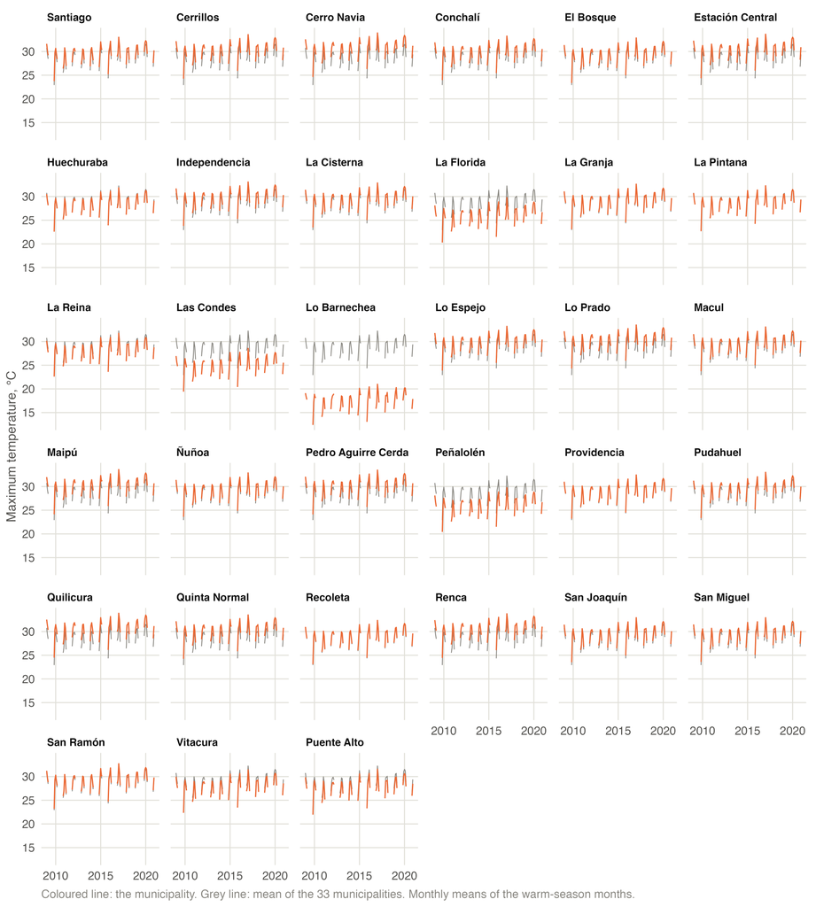

Figure 22: Maximum temperature of each municipality, monthly means of the warm-season months. Coloured line: the municipality. Grey line: mean of the 33 municipalities. File `series_5_municipalities_temperature.png`.

```r
knitr::include_graphics(series_figure("series_5_municipalities_temperature"))
```

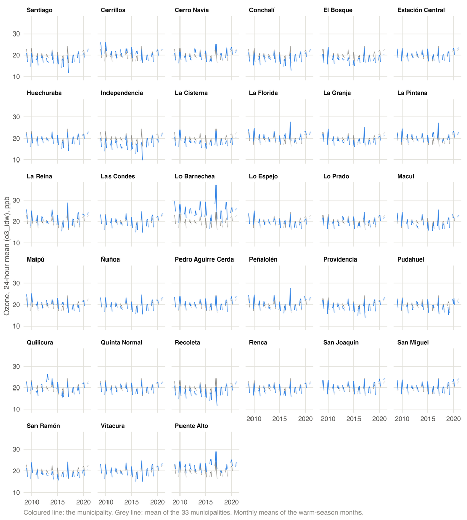

Figure 23: Ozone of each municipality (24-hour mean, delivered series), monthly means of the warm-season months. Coloured line: the municipality. Grey line: mean of the 33 municipalities. File `series_6_municipalities_ozone.png`.

```r
knitr::include_graphics(series_figure("series_6_municipalities_ozone"))
```

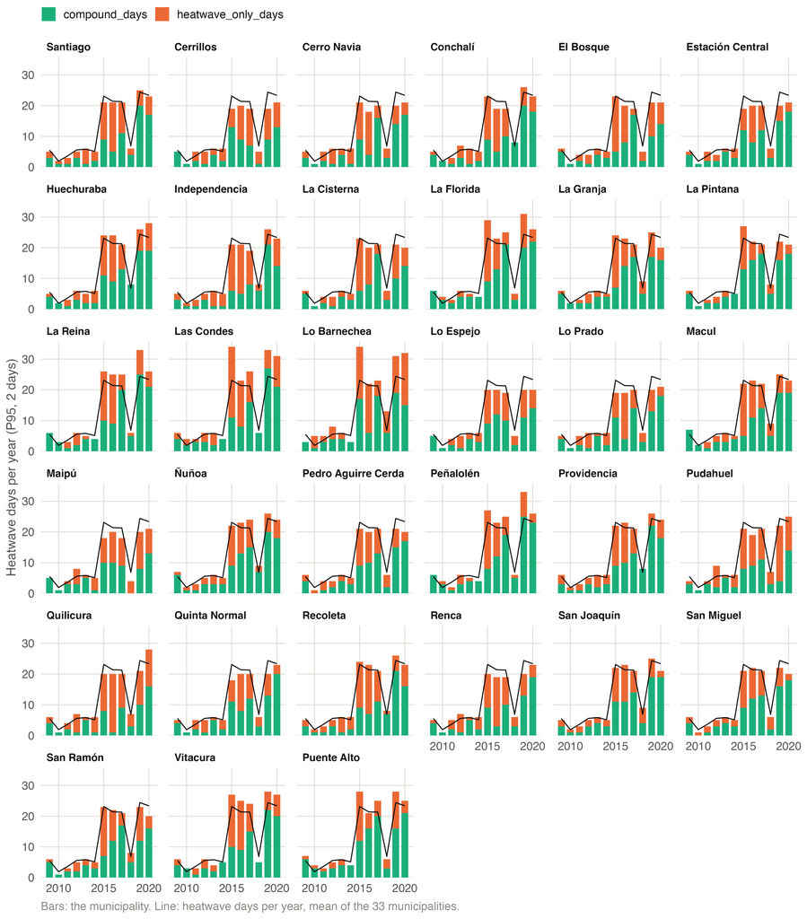

Figure 24: Heatwave days by calendar year in each municipality, split by ozone (working definitions). Bars: the municipality. Line: mean of the 33 municipalities. File `series_7_municipalities_heatwave_days.png`.

```r
knitr::include_graphics(series_figure("series_7_municipalities_heatwave_days"))
```

### 5.4.5 What the series show

- **Heatwave days are concentrated in 5 years.** In 2015, 2016, 2017, 2019, 2020 the municipalities have between 21 and 24 heatwave days on average, against 2 to 7 days in the other years: those 5 years hold 77% of the heatwave days of the period. The threshold comes from a reference period that ends in 2020, and the days above it are more frequent at the end of that period (Heatwave definitions).
- **How many municipalities at once.** 256 of the 1,815 days have a heatwave in at least one municipality; on 146 of them in more than half of the municipalities, and on 77 in all 33. A heatwave with high ozone reaches at least one municipality on 186 days, and all of them on 11.
- **Temperature moves together, ozone less.** Month by month, the temperature of every municipality follows the mean of the 33: the lowest correlation is 0.966 (Lo Barnechea, whose series is also 11.1 °C colder than the mean). For the delivered ozone the correlation goes from 0.65 (Quilicura) to 0.97 (Ñuñoa): the ozone of a municipality depends on the few monitors near it.
- **One series to look at.** Quilicura has 97 high-ozone days in 2013, against 54 at most in its other years; its mean ozone of that year is 24.2 ppb, against 17.8 to 21.5 ppb in the others. The delivered series of that municipality and year should be checked against the station records before it is used.

# 6 Points to settle

1. **29 February.** CR2MET has no leap days. They are filled by interpolation and flagged; the alternative is to leave them empty.
2. **Season of the percentiles.** All days of the year (reference code) or warm-season days only. The thresholds differ by about one degree.
3. **Heatwave indicators of the reference repository.** Its script counts consecutive days across stacked municipalities. This project counts them within each municipality.
4. **Fixed threshold of 30 °C.** With area-mean temperatures it is exceeded on 65% of the warm-season days in Quilicura and on 0% in Lo Barnechea.
5. **Ozone metric and inputs.** The delivered series is a 24-hour mean built on trimmed and imputed station series; the plan names the MDA8. See the validation of the ozone exposure.
6. **Negative kriging values.** Set to missing and counted in the tables above.
7. **Three buffer days of December 2008.** The monitoring network of PM2.5 and NO2 was smaller before 2009; those days only feed the lags of the first deaths of January 2009.
8. **Temperature of the municipalities that reach into the Andes.** The CR2MET series of a municipality describes its whole territory. In Lo Barnechea it is 11.8 °C colder than in the median municipality and gives the most heatwave days of the 33: 185, against 130 to 183 in the others (why). The options: keep the series as it is; compute the temperature over the populated area, which needs the gridded CR2MET files; or repeat the models without that municipality as a sensitivity analysis.
9. **How the municipal CR2MET series were built.** The files do not say with which rule the grid was summarised over each territory (Temperature). It should be confirmed with the team that produced them.
10. **One ozone series to check.** In the delivered series Quilicura has 97 high-ozone days in 2013, against 54 at most in its other years (What the series show).

# 7 R scripts

The scripts are in [`Code/`](https://github.com/AmaruSimonAgueroJimenez/Heatwave-ozone-mortality-Chile/tree/main/Code) of the repository. They are not executed when this page is rendered: `Code/run_all.R` runs them in order and this page reads their outputs. The code of each one is folded below.

| Script | Purpose |
| --- | --- |
| `Code/10_exposure_temperature.R` | The 15 heatwave indicators by municipality and day, from CR2MET. |
| `Code/11_exposure_air_pollution.R` | Daily ozone, PM2.5, NO2 and humidity by municipality, from the delivered interpolated SINCA series. |
| `Code/12_ozone_station_series.R` | Ozone rebuilt from the hourly SINCA records: 24-hour mean and MDA8 by station, interpolated to the municipalities. |
| `Code/13_exposure_merge_qc.R` | Exposure dataset 2009-2020, alignment checks, ozone categories, compound exposure frequencies. |
| `Code/14_interpolation_validation.R` | Leave-one-station-out cross-validation of IDW and ordinary kriging. |
| `Code/15_export_geodata.R` | Polygons, target points and station coordinates in open formats, for script 16 and for the pages in Python. |
| `Code/16_reanalysis_comparison.R` | Ozone series against the CAMS EAC4 reanalysis. |
| `Code/17_validation_summary.R` | Tables of the ozone validation: station inputs, cross-validation, delivered against rebuilt series. |
| `Code/18_exposure_time_series.R` | Time series of every municipality and of their mean over the whole study period: three tables and seven figures. |
| `Code/00_setup.R` | Packages, folders, parameters and checks of the inputs, shared by the scripts. |
| `Code/01_functions.R` | Functions shared by the scripts. |
| `Code/02_plot_style.R` | Style of the figures and the function that writes figure files. |

What each script reads and writes is in Workflow and scripts.

**Code/10_exposure_temperature.R**

```r
# 10_exposure_temperature.R
# Heatwave indicators for the 33 study municipalities from CR2MET v2.5.
#
# Inputs
#   inputs$cr2met_tmax, inputs$cr2met_tmin   daily series by municipality, 1980-2021
# Outputs
#   Data/Derived/exposure_temperature.csv    one row per municipality and day
#   Output/Tables/temperature_thresholds.csv thresholds by municipality
#
# Definitions (analysis plan): a day is a heatwave day when it is at least the
# n-th consecutive day (n = 2, 3, 4) with maximum temperature above the 90th,
# 95th or 99th percentile of the municipality (reference period 1990-2020) or
# above 30 C, plus the excess heat factor (EHF) for the same three durations:
# 15 indicators in total.
#
# Consecutive days are counted within each municipality on a complete calendar.

source(here::here("Code", "00_setup.R"))
source(here::here("Code", "01_functions.R"))

municipalities <- study_municipalities()
ref_years <- get_param("temperature", "percentile_reference_years")
percentiles <- get_param("temperature", "percentile_thresholds")
absolute_c <- get_param("temperature", "absolute_threshold_celsius")
durations <- get_param("temperature", "min_consecutive_days")
season_rule <- get_param("temperature", "percentile_season")
warm_months <- get_param("study", "warm_season_months")
stopifnot(season_rule %in% c("all_year", "warm_season"))

# ---- 1. Read and put on a complete calendar ---------------------------------

temp <- merge(
  read_cr2met(input_path("cr2met_tmax"), "tmax", municipalities$code),
  read_cr2met(input_path("cr2met_tmin"), "tmin", municipalities$code),
  by = c("com", "date")
)
stopifnot(nrow(temp) == nrow(municipalities) * uniqueN(temp$date))

temp <- fill_calendar(temp, c("tmax", "tmin"),
                      handling = get_param("temperature", "leap_day_handling"))
temp[, year := year(date)]
temp[, warm_season := is_warm_season(date, warm_months)]

# ---- 2. Thresholds by municipality ------------------------------------------

# Days used for the percentiles: reference years, original records only (the
# filled 29 February days are left out). Both season rules are tabulated; the
# indicators use the one set in the configuration.
temp[, in_reference := year >= ref_years[1] & year <= ref_years[2] & !temp_filled]

percentile_table <- function(rule) {
  days <- if (rule == "warm_season") temp[in_reference & warm_season] else temp[in_reference == TRUE]
  out <- days[, as.list(stats::quantile(tmax, percentiles / 100, type = 7, names = FALSE)), by = com]
  setnames(out, c("com", paste0("p", percentiles)))
  out[, season_rule := rule]
  out
}
thresholds_all <- rbind(percentile_table("all_year"), percentile_table("warm_season"))
thresholds_all <- merge(municipalities, thresholds_all, by.x = "code", by.y = "com")
setnames(thresholds_all, c("code", "name"), c("com", "municipality"))
fwrite(thresholds_all, file.path(dir_tables, "temperature_thresholds.csv"))

thresholds <- thresholds_all[season_rule == get_param("temperature", "percentile_season"),
                             c("com", paste0("p", percentiles)), with = FALSE]
temp <- merge(temp, thresholds, by = "com")
setorder(temp, com, date)

# ---- 3. Heatwave indicators -------------------------------------------------

# Single hot days: maximum temperature strictly above the threshold
for (p in percentiles) {
  temp[, (paste0("hot_p", p)) := as.integer(tmax > get(paste0("p", p)))]
}
temp[, (paste0("hot_", absolute_c, "c")) := as.integer(tmax > absolute_c)]

hot_columns <- c(paste0("hot_p", percentiles), paste0("hot_", absolute_c, "c"))
for (hot in hot_columns) {
  for (n in durations) {
    indicator <- paste0(sub("^hot_", "hw_", hot), "_", n, "d")
    temp[, (indicator) := consecutive_flag(get(hot), n), by = com]
  }
}

# Excess heat factor, one indicator per duration (EHF > 0)
if (isTRUE(get_param("temperature", "include_ehf"))) {
  for (n in durations) {
    temp[, c("tad", paste0("ehf_", n, "d")) := excess_heat_factor(
      tmax, tmin, in_reference, n_days = n,
      accl_days = get_param("temperature", "ehf_acclimatisation_days"),
      prob = get_param("temperature", "ehf_reference_percentile") / 100
    ), by = com]
    temp[, (paste0("hw_ehf_", n, "d")) := as.integer(get(paste0("ehf_", n, "d")) > 0)]
  }
}

# With leap_day_handling = "missing" the indicators are empty wherever their
# window includes 29 February; nothing is filled in here.

# ---- 4. Keep the study days and save ----------------------------------------

lag_buffer <- max(unlist(get_param("design", "lags_days")))
keep_dates <- study_dates(buffer_days = lag_buffer)
exposure_temperature <- temp[date %in% keep_dates]
exposure_temperature <- merge(municipalities, exposure_temperature, by.x = "code", by.y = "com")
setnames(exposure_temperature, c("code", "name"), c("com", "municipality"))
exposure_temperature[, c("in_reference", paste0("p", percentiles)) := NULL]
setorder(exposure_temperature, com, date)

stopifnot(
  nrow(exposure_temperature) == nrow(municipalities) * length(keep_dates),
  anyDuplicated(exposure_temperature[, .(com, date)]) == 0
)

hw_columns <- grep("^hw_", names(exposure_temperature), value = TRUE)
n_expected <- length(durations) *
  (length(percentiles) + 1 + isTRUE(get_param("temperature", "include_ehf")))
stopifnot(length(hw_columns) == n_expected)

fwrite(exposure_temperature, file.path(dir_derived, "exposure_temperature.csv"))

message("exposure_temperature.csv: ", nrow(exposure_temperature), " rows, ",
        length(hw_columns), " heatwave indicators, ",
        sum(exposure_temperature$temp_filled), " municipality-days filled (29 February)")
```

**Code/11_exposure_air_pollution.R**

```r
# 11_exposure_air_pollution.R
# Municipal daily air pollution from the interpolated SINCA series.
#
# Inputs
#   inputs$sinca_opr   interpolated series, operational period (main analysis)
#   inputs$sinca_all   interpolated series, all modelled values (sensitivity)
# Outputs
#   Data/Derived/exposure_air_pollution.csv       main version
#   Data/Derived/exposure_air_pollution_all.csv   sensitivity version
#   Output/Tables/air_pollution_qc.csv            counts behind every QC rule
#
# For each variable the file keeps the IDW value, the ordinary kriging value
# with its variance, and the number of stations. Units as delivered: ozone
# and nitrogen dioxide in ppb, PM2.5 in ug/m3, relative humidity in percent.
# The ozone value is a 24-hour mean.

source(here::here("Code", "00_setup.R"))
source(here::here("Code", "01_functions.R"))

municipalities <- study_municipalities()
variables <- c(get_param("air_pollution", "primary_pollutant"),
               unlist(get_param("air_pollution", "adjustment_pollutants")),
               unlist(get_param("air_pollution", "other_variables")))
methods <- unlist(get_param("air_pollution", "interpolation_methods"))
min_stations <- get_param("air_pollution", "min_stations")
negative_rule <- get_param("air_pollution", "negative_values")
stopifnot(negative_rule == "set_missing")

lag_buffer <- max(unlist(get_param("design", "lags_days")))
keep_dates <- study_dates(buffer_days = lag_buffer)

clean_version <- function(version) {
  dt <- read_sinca_interpolated(
    input_path(paste0("sinca_", version)), municipalities, variables,
    date_from = min(keep_dates), date_to = max(keep_dates)
  )
  # Complete municipality-by-day grid, no repeated rows
  stopifnot(
    nrow(dt) == nrow(municipalities) * length(keep_dates),
    anyDuplicated(dt[, .(com, date)]) == 0
  )
  qc <- list()
  for (v in variables) {
    n_col <- paste0(v, "_n_stations")
    for (m in methods) {
      col <- paste0(v, "_", m)
      negative <- !is.na(dt[[col]]) & dt[[col]] < 0
      few <- !is.na(dt[[col]]) & dt[[n_col]] < min_stations
      qc[[length(qc) + 1]] <- data.table(
        version = version, variable = v, method = m,
        rows = nrow(dt), missing_delivered = sum(is.na(dt[[col]])),
        negative_set_missing = sum(negative),
        below_min_stations_set_missing = sum(few & !negative)
      )
      set(dt, which(negative | few), col, NA_real_)
      if (m == "ok") set(dt, which(negative | few), paste0(v, "_ok_var"), NA_real_)
    }
  }
  list(data = dt, qc = rbindlist(qc))
}

main <- clean_version(get_param("air_pollution", "series_version_main"))
sensitivity <- clean_version(get_param("air_pollution", "series_version_sensitivity"))

fwrite(main$data, file.path(dir_derived, "exposure_air_pollution.csv"))
fwrite(sensitivity$data, file.path(dir_derived, "exposure_air_pollution_all.csv"))
fwrite(rbind(main$qc, sensitivity$qc), file.path(dir_tables, "air_pollution_qc.csv"))

message("exposure_air_pollution.csv: ", nrow(main$data), " rows, variables: ",
        paste(variables, collapse = ", "))
print(main$qc)
```

**Code/12_ozone_station_series.R**

```r
# 12_ozone_station_series.R
# Ozone at the monitoring stations from the hourly SINCA records, and a
# municipal series rebuilt from them with the data author's interpolation.
#
# Why: the delivered municipal series (script 11) is a 24-hour mean computed
# after trimming the hourly values at their 1st and 99th percentiles and
# filling gaps by imputation. The analysis plan names the daily maximum 8-hour
# mean (MDA8). This script rebuilds both metrics from the hourly records as
# published by SINCA, with no trimming and no imputation, and interpolates
# them with the same model and parameters. Only the hourly records with the
# statuses accepted in the configuration are used.
#
# Inputs
#   inputs$sinca_hourly_dir          hourly ozone by station (ppb)
#   inputs$station_series            station coordinates used by the data author
#   inputs$interpolation_locations   one target point per municipality
# Outputs
#   Data/Derived/ozone_station_daily.csv       station-day: mean24, mda8, valid hours
#   Data/Derived/ozone_rebuilt_municipal.csv   municipality-day: o3obs_* (24-hour
#                                              mean) and o3mda8_* (MDA8)
#   Output/Tables/ozone_station_hourly_status.csv
#   Output/Tables/ozone_rebuilt_qc.csv

suppressPackageStartupMessages({
  library(sf)
  library(sp)
  library(gstat)
  library(automap)
})
source(here::here("Code", "00_setup.R"))
source(here::here("Code", "01_functions.R"))

municipalities <- study_municipalities()
params <- get_param("interpolation")
series_rules <- get_param("station_series")
stopifnot(get_param("air_pollution", "negative_values") == "set_missing")
lag_buffer <- max(unlist(get_param("design", "lags_days")))
keep_dates <- study_dates(buffer_days = lag_buffer)

# ---- 1. Stations and target points ------------------------------------------

station_codes <- fread(here::here(series_rules$stations_file), encoding = "UTF-8")
author <- new.env()
load(input_path("station_series"), envir = author)
load(input_path("interpolation_locations"), envir = author)

station_points <- author$imputed_series[!duplicated(author$imputed_series$station), "station"]
station_points <- merge(station_points, station_codes, by = "station")
stopifnot(nrow(station_points) == nrow(station_codes),
          sf::st_crs(station_points)$epsg == params$crs_epsg)

targets <- author$interpol
stopifnot(setequal(targets$comuna, municipalities$name),
          sf::st_crs(targets)$epsg == params$crs_epsg)

# ---- 2. Daily series by station ---------------------------------------------

read_station <- function(i) {
  file <- file.path(input_path("sinca_hourly_dir"),
                    sprintf(series_rules$hourly_file_pattern, station_codes$sinca_id[i]))
  if (!file.exists(file)) stop("Hourly file not found: ", file, call. = FALSE)
  hourly <- read_sinca_hourly(file, accepted_status = unlist(series_rules$accepted_status))
  daily <- daily_from_hourly(
    hourly,
    min_hours = series_rules$min_valid_hours_day,
    mda8_min_hours = series_rules$mda8_min_hours_window,
    mda8_min_windows = series_rules$mda8_min_windows_day
  )
  status <- hourly[date %in% keep_dates, .(hours = .N), by = status]
  list(
    daily = cbind(station_codes[i], daily[date %in% keep_dates]),
    status = cbind(station_codes[i], status)
  )
}
stations <- lapply(seq_len(nrow(station_codes)), read_station)
station_daily <- rbindlist(lapply(stations, `[[`, "daily"))
hourly_status <- rbindlist(lapply(stations, `[[`, "status"))
hourly_status[is.na(status), status := "no_record"]

setorder(station_daily, station, date)
fwrite(station_daily, file.path(dir_derived, "ozone_station_daily.csv"))
fwrite(dcast(hourly_status, sinca_id + station ~ status, value.var = "hours", fill = 0),
       file.path(dir_tables, "ozone_station_hourly_status.csv"))

# ---- 3. Municipal series rebuilt with the same interpolation ----------------

setkey(station_daily, date)
metric_prefix <- c(mean24 = "o3obs", mda8 = "o3mda8")

rebuild_day <- function(day) {
  out <- data.table(municipality = targets$comuna, date = day)
  for (metric in names(metric_prefix)) {
    prefix <- metric_prefix[[metric]]
    values <- station_daily[.(day)][!is.na(get(metric)), .(station, value = get(metric))]
    out[, (paste0(prefix, "_n_stations")) := nrow(values)]
    if (nrow(values) >= params$ok_min_stations) {
      day_stations <- merge(station_points, values, by = "station")
      result <- with_warnings(interpolate_day(day_stations, targets, "value", params))
      out[, (paste0(prefix, c("_idw", "_ok", "_ok_var"))) := result$value[, .(idw, ok, ok_var)]]
      out[, (paste0(prefix, "_ok_warning")) := length(result$warnings) > 0]
      out[, (paste0(prefix, "_ok_failed")) := !is.na(result$value$ok_error[1])]
    } else {
      out[, (paste0(prefix, c("_idw", "_ok", "_ok_var"))) := NA_real_]
      out[, (paste0(prefix, "_ok_warning")) := NA]
      out[, (paste0(prefix, "_ok_failed")) := NA]
    }
  }
  out
}
rebuilt_days <- run_parallel(as.list(keep_dates), rebuild_day, "Interpolation")
rebuilt <- rbindlist(rebuilt_days)
stopifnot(nrow(rebuilt) == nrow(municipalities) * length(keep_dates))

# Same rule as the delivered series for kriging values below zero
qc <- list()
for (prefix in metric_prefix) {
  for (m in c("idw", "ok")) {
    col <- paste0(prefix, "_", m)
    negative <- !is.na(rebuilt[[col]]) & rebuilt[[col]] < 0
    qc[[length(qc) + 1]] <- data.table(
      series = prefix, method = m, rows = nrow(rebuilt),
      missing = sum(is.na(rebuilt[[col]])), negative_set_missing = sum(negative),
      days_below_min_stations = rebuilt[get(paste0(prefix, "_n_stations")) < params$ok_min_stations,
                                        uniqueN(date)],
      days_with_kriging_warning = rebuilt[get(paste0(prefix, "_ok_warning")) == TRUE, uniqueN(date)],
      days_variogram_not_fitted = rebuilt[get(paste0(prefix, "_ok_failed")) == TRUE, uniqueN(date)]
    )
    set(rebuilt, which(negative), col, NA_real_)
    if (m == "ok") set(rebuilt, which(negative), paste0(prefix, "_ok_var"), NA_real_)
  }
}
fwrite(rbindlist(qc), file.path(dir_tables, "ozone_rebuilt_qc.csv"))

rebuilt <- merge(municipalities, rebuilt, by.x = "name", by.y = "municipality")
setnames(rebuilt, c("code", "name"), c("com", "municipality"))
setcolorder(rebuilt, c("com", "municipality", "date"))
setorder(rebuilt, com, date)
fwrite(rebuilt, file.path(dir_derived, "ozone_rebuilt_municipal.csv"))

message("ozone_station_daily.csv: ", nrow(station_daily), " station-days; ",
        "ozone_rebuilt_municipal.csv: ", nrow(rebuilt), " rows")
print(rbindlist(qc))
```

**Code/13_exposure_merge_qc.R**

```r
# 13_exposure_merge_qc.R
# Exposure dataset 2009-2020: temperature, heatwaves, ozone and co-pollutants
# by municipality and day, with the checks of temporal alignment.
#
# Inputs
#   Data/Derived/exposure_temperature.csv      (script 10)
#   Data/Derived/exposure_air_pollution.csv    (script 11)
#   Data/Derived/ozone_rebuilt_municipal.csv   (script 12)
#   inputs$sinca_opr                           station temperature, alignment check only
# Outputs
#   Data/Derived/exposure_2009_2020.csv            the exposure dataset
#   Output/Tables/exposure_alignment.csv           coverage of each source
#   Output/Tables/temporal_alignment_lags.csv      CR2MET against SINCA temperature
#   Output/Tables/ozone_cutoffs.csv                percentile cut-offs by municipality
#   Output/Tables/compound_frequency_by_municipality.csv
#   Output/Tables/compound_frequency_by_year.csv
#   Output/Tables/exposure_codebook.csv
#
# The dataset holds every day of the study years plus the days before the
# first one that the lagged exposures need. `in_study_period` and
# `warm_season` mark the days of analysis (1 November to 31 March).

source(here::here("Code", "00_setup.R"))
source(here::here("Code", "01_functions.R"))

municipalities <- study_municipalities()
study_years <- get_param("study", "years")
cutoffs <- unlist(get_param("air_pollution", "ozone_percentile_cutoffs"))
scope <- get_param("air_pollution", "ozone_percentile_scope")
stopifnot(scope == "municipality")
lag_buffer <- max(unlist(get_param("design", "lags_days")))
keep_dates <- study_dates(buffer_days = lag_buffer)

read_derived <- function(file) {
  dt <- fread(derived_path(file), encoding = "UTF-8")
  dt[, date := as.Date(date)]
  dt
}
temperature <- read_derived("exposure_temperature.csv")
pollution <- read_derived("exposure_air_pollution.csv")
rebuilt <- read_derived("ozone_rebuilt_municipal.csv")

# ---- 1. Alignment: every source covers the same municipality-day grid -------

grid <- CJ(com = municipalities$code, date = keep_dates)
coverage <- function(dt, source) {
  keys <- dt[, .(com, date)]
  data.table(
    source = source, rows = nrow(dt), municipalities = uniqueN(dt$com),
    first_date = min(dt$date), last_date = max(dt$date), days = uniqueN(dt$date),
    repeated_keys = sum(duplicated(keys)),
    keys_missing_from_grid = nrow(fsetdiff(grid, keys)),
    keys_outside_grid = nrow(fsetdiff(keys, grid))
  )
}
alignment <- rbind(
  coverage(temperature, "temperature (CR2MET)"),
  coverage(pollution, "air pollution (SINCA, delivered)"),
  coverage(rebuilt, "ozone rebuilt from hourly records")
)
fwrite(alignment, file.path(dir_tables, "exposure_alignment.csv"))
stopifnot(all(alignment$repeated_keys == 0), all(alignment$keys_missing_from_grid == 0),
          all(alignment$keys_outside_grid == 0))

# ---- 2. Alignment of the calendars: CR2MET against SINCA temperature --------

# Day-to-day changes of the CR2MET maximum temperature are correlated with the
# day-to-day changes of the SINCA station temperature shifted by -2 to +2
# days. Aligned calendars give the highest correlation at shift 0. Leap years
# are looked at separately after 29 February, the day absent from CR2MET.
sinca_temp <- read_sinca_interpolated(
  input_path(paste0("sinca_", get_param("air_pollution", "series_version_main"))),
  municipalities, "temp", date_from = min(keep_dates), date_to = max(keep_dates)
)
check <- merge(temperature[, .(com, date, tmax, temp_filled)],
               sinca_temp[, .(com, date, sinca_temp = temp_idw)], by = c("com", "date"))
setorder(check, com, date)
check[, d_tmax := tmax - shift(tmax), by = com]
# Changes that involve a filled 29 February are left out
check[, original_pair := !temp_filled & !shift(temp_filled), by = com]
check[, leap_year_after_feb := (year(date) %% 4 == 0) & month(date) >= 3]
lag_table <- rbindlist(lapply(-2:2, function(k) {
  check[, d_sinca := shift(sinca_temp, n = -k) - shift(sinca_temp, n = -k + 1), by = com]
  check[original_pair == TRUE & !is.na(d_sinca),
        .(shift_days = k, n = .N, correlation = cor(d_tmax, d_sinca)),
        by = .(period = fifelse(leap_year_after_feb, "leap years, March to December",
                                "all other days"))]
}))
setorder(lag_table, period, shift_days)
fwrite(lag_table, file.path(dir_tables, "temporal_alignment_lags.csv"))
best <- lag_table[, .SD[which.max(correlation)], by = period]
if (!all(best$shift_days == 0)) {
  stop("CR2MET and SINCA calendars are not aligned: see temporal_alignment_lags.csv",
       call. = FALSE)
}

# ---- 3. Merge ---------------------------------------------------------------

exposure <- merge(temperature, pollution[, !"municipality"], by = c("com", "date"))
exposure <- merge(exposure, rebuilt[, !"municipality"], by = c("com", "date"))
stopifnot(nrow(exposure) == nrow(grid))
exposure[, in_study_period := year >= study_years[1] & year <= study_years[2]]

# ---- 4. Ozone categories by municipality-specific percentiles ---------------

# Six ozone series: delivered (o3), rebuilt 24-hour mean (o3obs) and rebuilt
# MDA8 (o3mda8), each by IDW and by ordinary kriging. Cut-offs are the
# percentiles of the warm-season days of the study years in each municipality.
ozone_series <- as.vector(outer(c("o3", "o3obs", "o3mda8"), c("idw", "ok"), paste, sep = "_"))
cutoff_tables <- list()
for (series in ozone_series) {
  cut <- exposure[in_study_period & warm_season & !is.na(get(series)),
                  as.list(stats::quantile(get(series), cutoffs / 100, type = 7, names = FALSE)),
                  by = com]
  setnames(cut, c("com", paste0("p", cutoffs)))
  cutoff_tables[[series]] <- cbind(series = series, cut)
  exposure <- merge(exposure, cut, by = "com")
  for (p in cutoffs) {
    exposure[, (paste0(series, "_gt_p", p)) := as.integer(get(series) > get(paste0("p", p)))]
  }
  exposure[, (paste0("p", cutoffs)) := NULL]
}
ozone_cutoffs <- merge(municipalities, rbindlist(cutoff_tables), by.x = "code", by.y = "com")
setnames(ozone_cutoffs, c("code", "name"), c("com", "municipality"))
setorder(ozone_cutoffs, series, com)
fwrite(ozone_cutoffs, file.path(dir_tables, "ozone_cutoffs.csv"))

# ---- 5. Frequency of compound exposure over the definition grid -------------

heatwaves <- grep("^hw_", names(exposure), value = TRUE)
ozone_flags <- grep("_gt_p[0-9]+$", names(exposure), value = TRUE)
days <- exposure[in_study_period & warm_season]
compound_counts <- function(by_column) {
  rbindlist(lapply(heatwaves, function(hw) rbindlist(lapply(ozone_flags, function(oz) {
    days[, category := compound_category(get(hw), get(oz))]
    out <- days[, .(
      days = .N, e00 = sum(category == "E00", na.rm = TRUE),
      e10 = sum(category == "E10", na.rm = TRUE), e01 = sum(category == "E01", na.rm = TRUE),
      e11 = sum(category == "E11", na.rm = TRUE), not_classified = sum(is.na(category))
    ), by = by_column]
    cbind(heatwave = hw, ozone = oz, out)
  }))))
}
by_municipality <- merge(municipalities, compound_counts("com"), by.x = "code", by.y = "com")
setnames(by_municipality, c("code", "name"), c("com", "municipality"))
fwrite(by_municipality, file.path(dir_tables, "compound_frequency_by_municipality.csv"))
fwrite(compound_counts("year"), file.path(dir_tables, "compound_frequency_by_year.csv"))

# ---- 6. Save the dataset and its codebook -----------------------------------

setcolorder(exposure, c("com", "municipality", "date", "year", "in_study_period", "warm_season"))
setorder(exposure, com, date)
fwrite(exposure, file.path(dir_derived, "exposure_2009_2020.csv"))

describe <- function(name) {
  rules <- list(
    "^com$" = "Municipality code (INE)",
    "^municipality$" = "Municipality name",
    "^date$" = "Calendar day",
    "^year$" = "Calendar year",
    "^in_study_period$" = "Day inside the study years (FALSE for the lag buffer days)",
    "^warm_season$" = "Day between 1 November and 31 March",
    "^tmax$" = "Daily maximum temperature, CR2MET v2.5 (degrees C)",
    "^tmin$" = "Daily minimum temperature, CR2MET v2.5 (degrees C)",
    "^temp_filled$" = "Temperature absent from CR2MET (29 February), filled as configured",
    "^tad$" = "Daily mean temperature: (tmax + next-day tmin) / 2 (degrees C)",
    "^hot_" = "Maximum temperature above the threshold in the name (1/0)",
    "^hw_ehf_" = "Heatwave day: excess heat factor above zero, window in the name (1/0)",
    "^hw_" = "Heatwave day: at least the n-th consecutive day above the threshold (1/0)",
    "^ehf_" = "Excess heat factor, window in the name (degrees C squared)",
    "_gt_p[0-9]+$" = "Ozone above the municipality percentile in the name, warm-season days of the study years (1/0)",
    "_ok_warning$" = "Variogram fit raised a warning that day",
    "_ok_failed$" = "Variogram could not be fitted that day (too few stations); kriging value missing",
    "_n_stations$" = "Stations with a value that day",
    "_ok_var$" = "Ordinary kriging variance",
    "^o3obs_" = "Ozone, 24-hour mean rebuilt from hourly records without trimming or imputation (ppb)",
    "^o3mda8_" = "Ozone, daily maximum 8-hour mean rebuilt from hourly records (ppb)",
    "^o3_" = "Ozone, 24-hour mean, delivered interpolated series (ppb)",
    "^pm25_" = "PM2.5, delivered interpolated series (ug/m3)",
    "^no2_" = "Nitrogen dioxide, delivered interpolated series (ppb)",
    "^hum_" = "Relative humidity, delivered interpolated series (percent)"
  )
  for (pattern in names(rules)) if (grepl(pattern, name)) return(rules[[pattern]])
  stop("No codebook entry for column: ", name, call. = FALSE)
}
codebook <- data.table(
  variable = names(exposure),
  description = vapply(names(exposure), describe, character(1)),
  missing = vapply(exposure, function(x) sum(is.na(x)), integer(1))
)
fwrite(codebook, file.path(dir_tables, "exposure_codebook.csv"))

message("exposure_2009_2020.csv: ", nrow(exposure), " rows, ", ncol(exposure), " columns; ",
        exposure[in_study_period & warm_season, .N],
        " municipality-days in the warm seasons of the study years")
```

**Code/14_interpolation_validation.R**

```r
# 14_interpolation_validation.R
# Leave-one-station-out cross-validation of the ozone interpolation.
#
# For every warm-season day of the study years each station is removed in
# turn, the data author's model (IDW and ordinary kriging, same parameters)
# is fitted to the remaining stations, and the removed station is predicted.
# The observed values are the validated 24-hour mean and MDA8 of script 12.
#
# This is the slow step of the pipeline (one variogram fit per day, station
# and metric: about 75 minutes on two cores). It only writes the predictions;
# script 17 turns them into tables.
#
# Inputs
#   Data/Derived/ozone_station_daily.csv   (script 12)
#   inputs$station_series                  station coordinates
# Output
#   Data/Derived/validation_loso_predictions.csv   one row per day, metric and
#                                                  station left out

suppressPackageStartupMessages({
  library(sf)
  library(sp)
  library(gstat)
  library(automap)
})
source(here::here("Code", "00_setup.R"))
source(here::here("Code", "01_functions.R"))

params <- get_param("interpolation")
study_years <- get_param("study", "years")
warm_months <- get_param("study", "warm_season_months")

station_daily <- fread(derived_path("ozone_station_daily.csv"), encoding = "UTF-8")
station_daily[, date := as.Date(date)]
station_daily <- station_daily[year(date) >= study_years[1] & year(date) <= study_years[2]]
station_daily[, warm_season := is_warm_season(date, warm_months)]

author <- new.env()
load(input_path("station_series"), envir = author)
station_points <- author$imputed_series[!duplicated(author$imputed_series$station), "station"]
station_points <- station_points[station_points$station %in% station_daily$station, ]

cv_days <- sort(unique(station_daily[warm_season == TRUE, date]))
setkey(station_daily, date)

loso_day <- function(day) {
  results <- list()
  for (metric in c("mean24", "mda8")) {
    values <- station_daily[.(day)][!is.na(get(metric)), .(station, value = get(metric))]
    # The fit needs ok_min_stations after one station is removed
    if (nrow(values) - 1 < params$ok_min_stations) next
    points <- merge(station_points, values, by = "station")
    for (i in seq_len(nrow(points))) {
      fit <- with_warnings(interpolate_day(points[-i, ], points[i, ], "value", params))
      results[[length(results) + 1]] <- data.table(
        date = day, metric = metric, station = points$station[i],
        observed = points$value[i], n_fit_stations = nrow(points) - 1,
        fit$value, ok_warning = length(fit$warnings) > 0
      )
    }
  }
  rbindlist(results)
}
loso_days <- run_parallel(as.list(cv_days), loso_day, "Cross-validation")
loso <- rbindlist(loso_days)
stopifnot(nrow(loso) > 0)
fwrite(loso, file.path(dir_derived, "validation_loso_predictions.csv"))

message("validation_loso_predictions.csv: ", nrow(loso), " predictions on ", length(cv_days), " days")
```

**Code/15_export_geodata.R**

```r
# 15_export_geodata.R
# Geometries in open formats, for the Python reports and for any other
# software: the R inputs hold them as sf objects inside .RData files.
#
# Inputs
#   inputs$municipality_shapes       polygons of the 33 municipalities
#   inputs$interpolation_locations   one target point per municipality
#   inputs$station_series            coordinates of the ozone stations
# Outputs
#   Data/Derived/municipality_polygons.geojson   WGS 84, with the INE code
#   Data/Derived/interpolation_points.csv        target points, UTM 19S (metres)
#   Data/Derived/ozone_station_points.csv        stations, UTM 19S (metres)

suppressPackageStartupMessages(library(sf))
source(here::here("Code", "00_setup.R"))

municipalities <- study_municipalities()
epsg <- get_param("interpolation", "crs_epsg")
author <- new.env()
load(input_path("municipality_shapes"), envir = author)
load(input_path("interpolation_locations"), envir = author)
load(input_path("station_series"), envir = author)

polygons <- author$comunas_santiago[, c("cod_comuna", "comuna")]
names(polygons)[1:2] <- c("com", "municipality")
polygons$com <- as.integer(polygons$com)
stopifnot(setequal(polygons$com, municipalities$code), sf::st_crs(polygons)$epsg == 4326)
geojson <- file.path(dir_derived, "municipality_polygons.geojson")
if (file.exists(geojson)) file.remove(geojson)
sf::st_write(polygons, geojson, quiet = TRUE)

stopifnot(sf::st_crs(author$interpol)$epsg == epsg, sf::st_crs(author$imputed_series)$epsg == epsg)
targets <- data.table(municipality = author$interpol$comuna, sf::st_coordinates(author$interpol))
targets <- merge(municipalities, targets, by.x = "name", by.y = "municipality")
setnames(targets, c("name", "code", "X", "Y"), c("municipality", "com", "x", "y"))
fwrite(targets[order(com), .(com, municipality, x, y)],
       file.path(dir_derived, "interpolation_points.csv"))

station_codes <- fread(here::here(get_param("station_series", "stations_file")), encoding = "UTF-8")
first <- author$imputed_series[!duplicated(author$imputed_series$station), "station"]
stations <- data.table(station = first$station, sf::st_coordinates(first))
stations <- merge(station_codes, stations, by = "station")
setnames(stations, c("X", "Y"), c("x", "y"))
stopifnot(nrow(stations) == nrow(station_codes))
fwrite(stations, file.path(dir_derived, "ozone_station_points.csv"))

message("Geometries written to Data/Derived")
```

**Code/16_reanalysis_comparison.R**

```r
# 16_reanalysis_comparison.R
# Ozone of the municipal series against the CAMS global reanalysis (EAC4).
#
# CAMS EAC4 assimilates satellite retrievals of ozone into a global chemistry
# model. Its cells measure 0.75 degrees (about 70 by 83 km here), so the whole
# study area falls in two cells: the reanalysis cannot say anything about
# differences between municipalities. It is an independent source for the
# day-to-day course of ozone over the city, which is what this script uses.
#
# Inputs
#   inputs$cams_eac4_dir                    monthly files of 3-hourly values by cell;
#                                           the months read are those of cams_month_files()
#   Data/Derived/interpolation_points.csv   (script 15)
#   Data/Derived/exposure_2009_2020.csv     (script 13)
# Outputs
#   Data/Derived/cams_ozone_daily.csv            cell-day: daily mean and afternoon value (ppb)
#   Output/Tables/validation_cams_cells.csv      cells used and municipalities in each
#   Output/Tables/validation_cams_correlation.csv
#
# Correlations are computed for the city-wide daily mean (the mean of the 33
# municipalities), on the warm-season days of the study years, in two forms:
# on the daily values, and on the anomalies from the mean of each calendar
# month, which removes the seasonal cycle shared by any two ozone series.

suppressPackageStartupMessages({
  library(sf)
  library(ncdf4)
})
source(here::here("Code", "00_setup.R"))
source(here::here("Code", "01_functions.R"))

rules <- get_param("reanalysis")
study_years <- get_param("study", "years")
warm_months <- get_param("study", "warm_season_months")
# Mass mixing ratio (kg/kg) to volume mixing ratio (ppb): molar masses of dry
# air (28.9644 g/mol) and ozone (47.9982 g/mol)
kgkg_to_ppb <- 28.9644 / 47.9982 * 1e9

# ---- 1. Cells that contain the municipal target points ----------------------

targets <- fread(derived_path("interpolation_points.csv"), encoding = "UTF-8")
lonlat <- sf::st_coordinates(sf::st_transform(
  sf::st_as_sf(targets, coords = c("x", "y"), crs = get_param("interpolation", "crs_epsg")), 4326
))
targets[, `:=`(lon = lonlat[, 1], lat = lonlat[, 2])]

# The months that hold every record of the local days of the study years,
# whatever else the folder contains
files <- file.path(input_path("cams_eac4_dir"), cams_month_files())
stopifnot(length(files) > 0, all(file.exists(files)))
first <- ncdf4::nc_open(files[1])
cells <- data.table(pixel = seq_along(ncdf4::ncvar_get(first, "pixel_id")),
                    pixel_id = as.vector(ncdf4::ncvar_get(first, "pixel_id")),
                    cell_lat = as.vector(ncdf4::ncvar_get(first, "latitude")),
                    cell_lon = as.vector(ncdf4::ncvar_get(first, "longitude")))
stopifnot(ncdf4::ncatt_get(first, "o3", "units")$value == "kg kg**-1")
ncdf4::nc_close(first)

half <- rules$cell_size_degrees / 2
targets[, pixel_id := vapply(seq_len(.N), function(i) {
  hit <- cells[abs(cell_lat - lat[i]) <= half & abs(cell_lon - lon[i]) <= half]
  stopifnot(nrow(hit) == 1)
  hit$pixel_id
}, numeric(1))]
used <- cells[pixel_id %in% targets$pixel_id]
fwrite(merge(used[, .(pixel_id, cell_lat, cell_lon)],
             targets[, .(municipalities = .N, names = paste(municipality, collapse = "; ")), by = pixel_id],
             by = "pixel_id"),
       file.path(dir_tables, "validation_cams_cells.csv"))

# ---- 2. Daily values by cell, in local time ---------------------------------

read_month <- function(file) {
  nc <- ncdf4::nc_open(file)
  on.exit(ncdf4::nc_close(nc))
  ids <- as.vector(ncdf4::ncvar_get(nc, "pixel_id"))
  stopifnot(identical(ids, cells$pixel_id))
  time_units <- ncdf4::ncatt_get(nc, "time", "units")$value
  origin <- as.POSIXct(sub("^[a-z]+ since ", "", time_units), tz = "UTC")
  step <- switch(sub(" since.*$", "", time_units), hours = 3600, seconds = 1, days = 86400)
  stopifnot(!is.null(step))
  utc <- origin + ncdf4::ncvar_get(nc, "time") * step
  ozone <- ncdf4::ncvar_get(nc, "o3")                    # pixel x time
  stopifnot(identical(dim(ozone), c(length(ids), length(utc))))
  rbindlist(lapply(used$pixel, function(p) {
    data.table(pixel_id = ids[p], utc = utc, o3_ppb = ozone[p, ] * kgkg_to_ppb)
  }))
}
cams <- rbindlist(lapply(files, read_month))
stopifnot(anyDuplicated(cams[, .(pixel_id, utc)]) == 0, !anyNA(cams$o3_ppb))
cams[, local := utc + rules$utc_offset_hours * 3600]
cams[, `:=`(date = as.Date(format(local, "%Y-%m-%d", tz = "UTC")),
            hour = as.integer(format(local, "%H", tz = "UTC")))]
afternoon <- unlist(rules$afternoon_local_hours)
stopifnot(all(afternoon %in% unique(cams$hour)))
cams_daily <- cams[, .(
  records = .N,
  cams_mean24 = mean(o3_ppb),
  cams_afternoon = mean(o3_ppb[hour %in% afternoon])
), by = .(pixel_id, date)]
# Local days of the study years: each needs its eight 3-hourly records, so
# that no day drops out of the comparison unnoticed
cams_daily <- cams_daily[date %in% study_dates()]
setorder(cams_daily, pixel_id, date)
stopifnot(nrow(cams_daily) == nrow(used) * length(study_dates()),
          all(cams_daily$records == 8))
fwrite(cams_daily, file.path(dir_derived, "cams_ozone_daily.csv"))

# ---- 3. City-wide daily series and correlations -----------------------------

exposure <- fread(derived_path("exposure_2009_2020.csv"), encoding = "UTF-8")
exposure[, date := as.Date(date)]
exposure <- exposure[in_study_period == TRUE & warm_season == TRUE]
exposure <- merge(exposure, targets[, .(com, pixel_id)], by = "com")
exposure <- merge(exposure, cams_daily, by = c("pixel_id", "date"))
stopifnot(uniqueN(exposure$date) == uniqueN(cams_daily[
  year(date) >= study_years[1] & year(date) <= study_years[2] & month(date) %in% warm_months, date]))

pairs <- data.table(
  series = c("o3_idw", "o3_ok", "o3obs_idw", "o3obs_ok", "o3mda8_idw", "o3mda8_ok"),
  cams = c(rep("cams_mean24", 4), rep("cams_afternoon", 2))
)
city <- exposure[, c(lapply(.SD, mean, na.rm = TRUE)), by = date,
                 .SDcols = c(pairs$series, "cams_mean24", "cams_afternoon")]
city[, month_id := format(date, "%Y-%m")]
correlations <- rbindlist(lapply(seq_len(nrow(pairs)), function(i) {
  d <- city[, .(date, month_id, x = get(pairs$series[i]), y = get(pairs$cams[i]))][!is.na(x)]
  d[, `:=`(x_anomaly = x - mean(x), y_anomaly = y - mean(y)), by = month_id]
  data.table(series = pairs$series[i], cams = pairs$cams[i], days = nrow(d),
             mean_series = mean(d$x), mean_cams = mean(d$y),
             correlation_daily = cor(d$x, d$y),
             correlation_anomalies = cor(d$x_anomaly, d$y_anomaly))
}))
fwrite(correlations, file.path(dir_tables, "validation_cams_correlation.csv"))
fwrite(city[, !"month_id"], file.path(dir_derived, "cams_city_daily.csv"))
print(correlations)
```

**Code/17_validation_summary.R**

```r
# 17_validation_summary.R
# Validation of the ozone exposure: tables.
#
# Three questions
#   A. Station inputs: how do the station series used by the data author
#      compare with the daily means computed from the validated hourly SINCA
#      records?
#   B. Interpolation model: how well do IDW and ordinary kriging predict a
#      station left out of the fit (predictions of script 14)?
#   C. Municipal series: how does the delivered series compare with the one
#      rebuilt from the validated records with the same model?
#
# Inputs
#   Data/Derived/ozone_station_daily.csv            (script 12)
#   Data/Derived/exposure_2009_2020.csv             (script 13)
#   Data/Derived/validation_loso_predictions.csv    (script 14)
#   inputs$station_series                           the data author's station series
# Outputs, all in Output/Tables
#   validation_inputs_by_station.csv   validation_inputs_by_level.csv
#   validation_loso_overall.csv        validation_loso_common.csv
#   validation_loso_by_station.csv     validation_loso_high_ozone.csv
#   validation_reproduction.csv        validation_municipal_by_level.csv
#   validation_municipal_flags.csv

source(here::here("Code", "00_setup.R"))
source(here::here("Code", "01_functions.R"))

params <- get_param("interpolation")
study_years <- get_param("study", "years")
warm_months <- get_param("study", "warm_season_months")
cutoffs <- unlist(get_param("air_pollution", "ozone_percentile_cutoffs"))
z <- stats::qnorm(1 - (1 - params$conf_level) / 2)

station_daily <- fread(derived_path("ozone_station_daily.csv"), encoding = "UTF-8")
station_daily[, date := as.Date(date)]
station_daily <- station_daily[year(date) >= study_years[1] & year(date) <= study_years[2]]

author <- new.env()
load(input_path("station_series"), envir = author)

# ---- A. Station inputs ------------------------------------------------------

author_series <- as.data.table(sf::st_drop_geometry(author$imputed_series))[
  , .(station, date, author_o3 = daily_o3)]
inputs <- merge(station_daily, author_series, by = c("station", "date"), all = TRUE)
inputs <- inputs[!is.na(author_o3) | !is.na(mean24)]
inputs[, warm_season := is_warm_season(date, warm_months)]
inputs[, status := fcase(
  !is.na(author_o3) & is.na(mean24), "no validated daily mean",
  is.na(author_o3) & !is.na(mean24), "observed, absent from the author's series",
  abs(author_o3 - mean24) < 0.005, "identical",
  default = "modified"
)]

inputs_summary <- function(dt) {
  dt[, .(
    station_days = .N,
    identical_pct = 100 * mean(status == "identical"),
    modified_pct = 100 * mean(status == "modified"),
    no_validated_mean_pct = 100 * mean(status == "no validated daily mean"),
    absent_pct = 100 * mean(status == "observed, absent from the author's series"),
    mean_observed = mean(mean24[status %in% c("identical", "modified")]),
    mean_author_same_days = mean(author_o3[status %in% c("identical", "modified")]),
    mean_change_when_modified = mean((author_o3 - mean24)[status == "modified"])
  ), by = station]
}
by_station <- rbind(
  cbind(period = "all days", inputs_summary(inputs)),
  cbind(period = "warm season", inputs_summary(inputs[warm_season == TRUE]))
)
total <- rbind(
  cbind(period = "all days", inputs_summary(copy(inputs)[, station := "All stations"])),
  cbind(period = "warm season",
        inputs_summary(copy(inputs[warm_season == TRUE])[, station := "All stations"]))
)
fwrite(rbind(by_station, total), file.path(dir_tables, "validation_inputs_by_station.csv"))

# Difference by ozone level: warm-season station-days with both values,
# grouped by tenths of the observed 24-hour mean
both <- inputs[warm_season == TRUE & status %in% c("identical", "modified")]
both[, level := cut(mean24, stats::quantile(mean24, 0:10 / 10), include.lowest = TRUE,
                    labels = paste0("D", 1:10))]
by_level <- both[, .(
  station_days = .N, observed_mean24 = mean(mean24), observed_mda8 = mean(mda8, na.rm = TRUE),
  author_mean = mean(author_o3), difference = mean(author_o3 - mean24),
  modified_pct = 100 * mean(status == "modified")
), keyby = level]
fwrite(by_level, file.path(dir_tables, "validation_inputs_by_level.csv"))

# ---- B. Leave-one-station-out cross-validation ------------------------------

loso <- fread(derived_path("validation_loso_predictions.csv"), encoding = "UTF-8")
loso[, date := as.Date(date)]

loso_long <- melt(loso, id.vars = c("date", "metric", "station", "observed", "ok_var"),
                  measure.vars = c("idw", "ok"), variable.name = "method",
                  value.name = "predicted")
# All station-days that each method could predict
overall <- loso_long[, validation_metrics(observed, predicted), by = .(metric, method)]
# Share of station-days with no prediction (IDW: no station within the search radius)
overall <- merge(overall, loso_long[, .(not_predicted_pct = 100 * mean(is.na(predicted))),
                                    by = .(metric, method)], by = c("metric", "method"))
# Share of observed values inside the nominal kriging interval
below_zero <- loso[!is.na(ok) & ok_var < 0, .N]
if (below_zero > 0) {
  message(below_zero, " kriging variance(s) below zero within rounding (lowest ",
          format(min(loso$ok_var, na.rm = TRUE)), "), counted as zero")
}
coverage <- loso[!is.na(ok), .(method = "ok", interval_coverage_pct =
  100 * mean(abs(observed - ok) <= z * kriging_sd(ok_var, params$variance_rounding))), by = metric]
stopifnot(!anyNA(coverage$interval_coverage_pct))
overall <- merge(overall, coverage, by = c("metric", "method"), all.x = TRUE)
fwrite(overall, file.path(dir_tables, "validation_loso_overall.csv"))

# The two methods on the same station-days: IDW gives no value when no station
# lies within its search radius, kriging always does, so the sets above differ
common <- loso[!is.na(idw) & !is.na(ok)]
common_long <- melt(common, id.vars = c("date", "metric", "station", "observed"),
                    measure.vars = c("idw", "ok"), variable.name = "method",
                    value.name = "predicted")
fwrite(common_long[, validation_metrics(observed, predicted), by = .(metric, method)],
       file.path(dir_tables, "validation_loso_common.csv"))

by_station_cv <- loso_long[, validation_metrics(observed, predicted),
                           by = .(metric, method, station)]
fwrite(by_station_cv, file.path(dir_tables, "validation_loso_by_station.csv"))

# High-ozone days: observed and predicted values are each classified against
# their own station percentile, as the exposure categories are built
high <- rbindlist(lapply(cutoffs, function(p) {
  d <- loso_long[!is.na(predicted)]
  d[, `:=`(observed_high = as.integer(observed > stats::quantile(observed, p / 100)),
           predicted_high = as.integer(predicted > stats::quantile(predicted, p / 100))),
    by = .(metric, method, station)]
  cbind(percentile = p,
        d[, classification_agreement(observed_high, predicted_high), by = .(metric, method)])
}))
fwrite(high, file.path(dir_tables, "validation_loso_high_ozone.csv"))

# ---- C. Delivered against rebuilt municipal series --------------------------

exposure <- fread(derived_path("exposure_2009_2020.csv"), encoding = "UTF-8")
exposure[, date := as.Date(date)]
exposure <- exposure[in_study_period == TRUE & warm_season == TRUE]

# Reproduction: on the days when every station value of the author's series
# equals the validated 24-hour mean, the rebuilt municipal series should equal
# the delivered one if this project runs the same interpolation.
day_status <- inputs[, .(all_identical = all(status == "identical")), by = date]
same_input_days <- day_status[all_identical == TRUE, date]
same <- exposure[date %in% same_input_days]
reproduction <- rbindlist(lapply(c("idw", "ok"), function(m) {
  difference <- abs(same[[paste0("o3_", m)]] - same[[paste0("o3obs_", m)]])
  data.table(method = m, days = uniqueN(same$date), municipality_days = sum(!is.na(difference)),
             within_0.001_ppb_pct = 100 * mean(difference < 1e-3, na.rm = TRUE),
             median_abs_difference = stats::median(difference, na.rm = TRUE),
             max_abs_difference = max(difference, na.rm = TRUE))
}))
fwrite(reproduction, file.path(dir_tables, "validation_reproduction.csv"))

municipal_level <- rbindlist(lapply(c("idw", "ok"), function(m) {
  d <- exposure[, .(com, delivered = get(paste0("o3_", m)), rebuilt = get(paste0("o3obs_", m)),
                    mda8 = get(paste0("o3mda8_", m)))]
  d <- d[!is.na(delivered) & !is.na(rebuilt)]
  d[, level := cut(rebuilt, stats::quantile(rebuilt, 0:10 / 10), include.lowest = TRUE,
                   labels = paste0("D", 1:10))]
  cbind(method = m, d[, .(
    municipality_days = .N, rebuilt_mean24 = mean(rebuilt), delivered_mean24 = mean(delivered),
    difference = mean(delivered - rebuilt), rebuilt_mda8 = mean(mda8, na.rm = TRUE)
  ), keyby = level])
}))
fwrite(municipal_level, file.path(dir_tables, "validation_municipal_by_level.csv"))

# Agreement of the high-ozone flags between series (reference: rebuilt)
flag_pairs <- list(c("o3obs", "o3"), c("o3mda8", "o3"), c("o3mda8", "o3obs"))
municipal_flags <- rbindlist(lapply(flag_pairs, function(pair) {
  rbindlist(lapply(c("idw", "ok"), function(m) rbindlist(lapply(cutoffs, function(p) {
    reference <- exposure[[paste0(pair[1], "_", m, "_gt_p", p)]]
    test <- exposure[[paste0(pair[2], "_", m, "_gt_p", p)]]
    values <- exposure[, .(a = get(paste0(pair[1], "_", m)), b = get(paste0(pair[2], "_", m)))]
    cbind(reference = pair[1], compared = pair[2], method = m, percentile = p,
          classification_agreement(reference, test),
          pearson_r = values[!is.na(a) & !is.na(b), cor(a, b)])
  }))))
}))
fwrite(municipal_flags, file.path(dir_tables, "validation_municipal_flags.csv"))

print(overall)
```

**Code/18_exposure_time_series.R**

```r
# 18_exposure_time_series.R
# Time series of the exposures over the whole study period, for every
# municipality and for the mean of the 33 municipalities: tables and figures.
#
# Input
#   Data/Derived/exposure_2009_2020.csv   (script 13)
# Outputs, tables in Output/Tables
#   series_daily_all_municipalities.csv   one row per day: mean, lowest and highest
#                                         municipality, and municipalities with each exposure
#   series_monthly_by_municipality.csv    one row per municipality and month, and the
#                                         mean of the 33 municipalities
#   series_annual_by_municipality.csv     the same by calendar year
# Outputs, figures in Output/Figures (PDF and PNG)
#   series_1_daily_temperature_ozone      daily mean of the municipalities and range between them
#   series_2_daily_compound_exposure      municipalities by exposure category, day by day
#   series_3_monthly_by_municipality      monthly means: every municipality and their mean
#   series_4_annual_by_municipality       annual means and days of exposure: the same
#   series_5_municipalities_temperature   one panel per municipality: maximum temperature
#   series_6_municipalities_ozone         one panel per municipality: ozone
#   series_7_municipalities_heatwave_days one panel per municipality: heatwave days by year
#
# The series cover the days of analysis: 1 November to 31 March of the calendar
# years 2009 to 2020. Heatwave, ozone series and ozone cut-off are the working
# definitions of config/config.yml (models: heatwave_main, ozone_cutoff_main;
# air_pollution: ozone_series_main, interpolation_method_main).
#
# "Mean of the municipalities" is the plain mean of the 33 municipal values:
# every municipality counts the same, whatever its population or area.
#
# Every figure is drawn from one of the three tables written here.

source(here::here("Code", "00_setup.R"))
source(here::here("Code", "01_functions.R"))
source(here::here("Code", "02_plot_style.R"))

municipalities <- study_municipalities()
heatwave_main <- get_param("models", "heatwave_main")
method_main <- get_param("air_pollution", "interpolation_method_main")
ozone_main <- paste0(get_param("air_pollution", "ozone_series_main"), "_", method_main)
ozone_mda8 <- paste0("o3mda8_", method_main)
ozone_flag_main <- paste0(ozone_main, "_gt_p", get_param("models", "ozone_cutoff_main"))
png_dpi <- get_param("figures", "png_dpi")
width_mm <- get_param("figures", "width_double_mm")
mean_label <- "Mean of the 33 municipalities"
stopifnot(nrow(municipalities) == 33)

# ---- 1. Days of analysis ----------------------------------------------------

exposure <- fread(derived_path("exposure_2009_2020.csv"), encoding = "UTF-8")
exposure[, date := as.Date(date)]
needed <- c("com", "municipality", "date", "year", "tmax", ozone_main, ozone_mda8,
            heatwave_main, ozone_flag_main)
stopifnot(all(needed %in% names(exposure)))
days <- exposure[in_study_period == TRUE & warm_season == TRUE, ..needed]
setnames(days, c(ozone_main, ozone_mda8, heatwave_main, ozone_flag_main),
         c("o3", "mda8", "heatwave", "ozone_high"))
days[, category := compound_category(heatwave, ozone_high)]
days[, month := month(date)]
# Warm season of each day: November and December belong to the season that
# starts that year, January to March to the one that started the year before
days[, season_start := year - as.integer(month <= 3)]
days[, season := sprintf("%d/%02d", season_start, (season_start + 1L) %% 100L)]
n_days <- uniqueN(days$date)
stopifnot(
  nrow(days) == nrow(municipalities) * n_days,
  anyDuplicated(days[, .(com, date)]) == 0,
  !anyNA(days$tmax), !anyNA(days$heatwave)
)

# ---- 2. Tables --------------------------------------------------------------

# Daily: the municipal values of each day. Some municipality-days have no ozone
# value (too few stations with valid records): the columns *_municipalities
# count the municipalities behind each mean, and a day on which none has a
# value is left empty.
across_municipalities <- function(x) {
  x <- x[!is.na(x)]
  if (length(x) == 0) return(list(NA_real_, NA_real_, NA_real_, 0L))
  list(mean(x), min(x), max(x), length(x))
}
daily <- days[, .(
  municipalities = .N,
  # Municipalities with each single exposure, then by category of the compound exposure
  with_heatwave = sum(heatwave),
  with_high_ozone = sum(ozone_high, na.rm = TRUE),
  neither = sum(category == "E00", na.rm = TRUE),
  heatwave_only = sum(category == "E10", na.rm = TRUE),
  high_ozone_only = sum(category == "E01", na.rm = TRUE),
  heatwave_and_high_ozone = sum(category == "E11", na.rm = TRUE),
  not_classified = sum(is.na(category))
), keyby = .(date, season)]
for (v in c("tmax", "o3", "mda8")) {
  across <- days[, across_municipalities(get(v)), keyby = date]
  setnames(across, c("date", paste0(v, c("_mean", "_lowest", "_highest", "_municipalities"))))
  daily <- merge(daily, across, by = "date")
}
category_counts <- c("with_heatwave", "with_high_ozone", "neither", "heatwave_only",
                     "high_ozone_only", "heatwave_and_high_ozone", "not_classified")
setcolorder(daily, c("date", "season", "municipalities",
                     setdiff(names(daily), c("date", "season", "municipalities", category_counts))))
stopifnot(
  nrow(daily) == n_days,
  all(daily$tmax_municipalities == nrow(municipalities)),
  daily[, all(neither + heatwave_only + high_ozone_only + heatwave_and_high_ozone +
                not_classified == municipalities)],
  # A municipality with a heatwave is in one of the two heatwave categories,
  # or has no ozone value that day
  daily[, all(with_heatwave >= heatwave_only + heatwave_and_high_ozone &
                with_heatwave <= heatwave_only + heatwave_and_high_ozone + not_classified)]
)
fwrite(daily, file.path(dir_tables, "series_daily_all_municipalities.csv"))

# Monthly and annual: one row per municipality and period, then the mean of
# the municipalities for each period
summarise_period <- function(by_columns) {
  by_municipality <- days[, .(
    days = .N,
    # Means over the days with a value; o3_days and mda8_days count them
    tmax = mean(tmax), o3 = mean(o3, na.rm = TRUE), mda8 = mean(mda8, na.rm = TRUE),
    o3_days = sum(!is.na(o3)), mda8_days = sum(!is.na(mda8)),
    heatwave_days = sum(heatwave),
    high_ozone_days = sum(ozone_high, na.rm = TRUE),
    heatwave_only_days = sum(category == "E10", na.rm = TRUE),
    compound_days = sum(category == "E11", na.rm = TRUE),
    not_classified_days = sum(is.na(category))
  ), by = c("com", "municipality", by_columns)]
  # The means below need at least one day with ozone in every municipality and period
  if (any(by_municipality$o3_days == 0) || any(by_municipality$mda8_days == 0)) {
    stop("A municipality has no ozone value in a whole period: the means of the ",
         "municipalities need a rule for that case.", call. = FALSE)
  }
  value_columns <- setdiff(names(by_municipality), c("com", "municipality", by_columns))
  all_municipalities <- by_municipality[, lapply(.SD, mean), by = by_columns,
                                        .SDcols = value_columns]
  all_municipalities[, `:=`(com = NA_integer_, municipality = mean_label)]
  out <- rbind(by_municipality, all_municipalities, use.names = TRUE)
  setorderv(out, c(by_columns, "com"), na.last = TRUE)
  out[]
}
monthly <- summarise_period(c("year", "month", "season"))
monthly[, month_start := as.Date(sprintf("%04d-%02d-01", year, month))]
setcolorder(monthly, c("com", "municipality", "year", "month", "month_start", "season"))
annual <- summarise_period("year")
n_months <- uniqueN(days[, .(year, month)])
stopifnot(
  nrow(monthly) == (nrow(municipalities) + 1) * n_months,
  nrow(annual) == (nrow(municipalities) + 1) * uniqueN(days$year),
  # The days of the periods add up to the days of analysis, in every municipality
  monthly[!is.na(com), sum(days), by = com][, all(V1 == n_days)],
  annual[!is.na(com), sum(days), by = com][, all(V1 == n_days)],
  # Days with a heatwave are heatwave-only days, compound days or days without ozone
  annual[!is.na(com), all(heatwave_days >= heatwave_only_days + compound_days)]
)
fwrite(monthly, file.path(dir_tables, "series_monthly_by_municipality.csv"))
fwrite(annual, file.path(dir_tables, "series_annual_by_municipality.csv"))
```

```r
# ---- 3. Figures -------------------------------------------------------------

pdf_device <- pdf_figure_device()
message("PDF figures: ", pdf_device$name, " device")
save_figure <- function(plot, name, height_mm) {
  write_figure(plot, name, width_mm, height_mm, png_dpi = png_dpi, pdf_device = pdf_device,
               folder = dir_figures)
}
theme_set(theme_publication(base_size = 9))
colour_mean <- ink$primary
colour_municipality <- ink$neutral
label_o3 <- sprintf("Ozone, 24-hour mean (%s), ppb", ozone_main)
label_mda8 <- sprintf("Ozone, MDA8 (%s), ppb", ozone_mda8)
label_tmax <- "Maximum temperature, °C"
variable_labels <- c(tmax = label_tmax, o3 = label_o3, mda8 = label_mda8)
year_breaks <- as.Date(sprintf("%d-01-01", seq(2009, 2021, by = 2)))
note_lines <- "Grey lines: each municipality. Dark line: mean of the 33 municipalities."
january_only <- function(dates) ifelse(format(dates, "%m") == "01", "Jan", "")

# Figure 1. Daily series: mean of the municipalities and range between them,
# one column per warm season so that the months without data take no room
# Table: series_daily_all_municipalities.csv
daily_long <- rbindlist(lapply(names(variable_labels), function(v) {
  daily[, .(date, season, variable = variable_labels[[v]], mean = get(paste0(v, "_mean")),
            lowest = get(paste0(v, "_lowest")), highest = get(paste0(v, "_highest")))]
}))
daily_long[, variable := factor(variable, levels = variable_labels)]
figure_1 <- ggplot(daily_long, aes(date)) +
  geom_ribbon(aes(ymin = lowest, ymax = highest), fill = ramp_blue[2]) +
  geom_line(aes(y = mean), colour = ramp_blue[6], linewidth = 0.25) +
  facet_grid(variable ~ season, scales = "free", space = "free_x", switch = "y",
             labeller = labeller(variable = label_wrap_gen(28))) +
  scale_x_date(date_breaks = "1 month", labels = january_only, expand = expansion(add = 0.5)) +
  labs(x = NULL, y = NULL,
       caption = paste0("Line: mean of the 33 municipalities. Band: lowest and highest municipality of the day.\n",
                        "One column per warm season (1 November to 31 March); 2008/09 and 2020/21 are covered in part.")) +
  theme(strip.placement = "outside", strip.text.y.left = element_text(angle = 90, hjust = 0.5),
        strip.text.x = element_text(size = rel(0.7), hjust = 0.5), strip.clip = "off",
        axis.text.x = element_text(size = rel(0.75)), panel.spacing.x = grid::unit(1, "mm"))
save_figure(figure_1, "series_1_daily_temperature_ozone", 160)

# Figure 2. Municipalities by exposure category, day by day, one panel per warm season
# Table: series_daily_all_municipalities.csv
category_columns <- c(heatwave_and_high_ozone = "Heatwave and high ozone",
                      heatwave_only = "Heatwave only", high_ozone_only = "High ozone only")
compound_daily <- melt(daily, id.vars = c("date", "season"), measure.vars = names(category_columns),
                       variable.name = "category", value.name = "municipalities_in_category")
compound_daily[, category := factor(category_columns[as.character(category)],
                                    levels = rev(category_columns))]
# Position of the day inside its season, on a calendar that runs from 1 November
# to 31 March (2000 is a leap year, so every 29 February has its place)
compound_daily[, season_day := as.Date(sprintf("%d-%s", ifelse(month(date) >= 11, 1999L, 2000L),
                                               format(date, "%m-%d")))]
figure_2 <- ggplot(compound_daily, aes(season_day, municipalities_in_category, fill = category)) +
  geom_col(width = 1) +
  facet_wrap(~season, ncol = 3) +
  scale_fill_manual(values = colour_compound[category_columns], breaks = category_columns) +
  # Month names are written here: date formats follow the language of the computer
  scale_x_date(breaks = as.Date(c("1999-11-01", "1999-12-01", "2000-01-01", "2000-02-01", "2000-03-01")),
               labels = c("Nov", "Dec", "Jan", "Feb", "Mar"),
               limits = as.Date(c("1999-10-31", "2000-04-01")), expand = expansion(mult = 0.01)) +
  scale_y_continuous(limits = c(0, nrow(municipalities)), breaks = c(0, 11, 22, 33),
                     expand = expansion(mult = c(0, 0.02))) +
  labs(x = NULL, y = "Municipalities (of 33)", fill = NULL,
       caption = sprintf("Heatwave: %s. High ozone: %s above the %sth percentile of the municipality.\n%s",
                         heatwave_label(heatwave_main), ozone_main,
                         get_param("models", "ozone_cutoff_main"),
                         "One panel per warm season; 2008/09 and 2020/21 are covered in part."))
save_figure(figure_2, "series_2_daily_compound_exposure", 210)

# Figure 3. Monthly means: every municipality and the mean of all
# Table: series_monthly_by_municipality.csv
monthly_long <- melt(monthly, id.vars = c("com", "municipality", "month_start", "season"),
                     measure.vars = names(variable_labels))
monthly_long[, variable := factor(variable_labels[as.character(variable)], levels = variable_labels)]
figure_3 <- ggplot(monthly_long[!is.na(com)], aes(month_start, value)) +
  geom_line(aes(group = interaction(com, season)), colour = colour_municipality, linewidth = 0.2) +
  geom_line(data = monthly_long[is.na(com)], aes(group = season), colour = colour_mean,
            linewidth = 0.6) +
  geom_point(data = monthly_long[is.na(com)], colour = colour_mean, size = 0.5) +
  facet_wrap(~variable, ncol = 1, scales = "free_y") +
  scale_x_date(breaks = year_breaks, date_labels = "%Y", expand = expansion(mult = 0.01)) +
  labs(x = NULL, y = NULL,
       caption = paste(note_lines, "Monthly means of the warm-season months (November to March)."))
save_figure(figure_3, "series_3_monthly_by_municipality", 170)

# Figure 4. Annual values: every municipality and the mean of all
# Table: series_annual_by_municipality.csv
annual_labels <- c(tmax = label_tmax, o3 = label_o3, mda8 = label_mda8,
                   heatwave_days = sprintf("Heatwave days (%s)", heatwave_label(heatwave_main)),
                   high_ozone_days = "High-ozone days",
                   compound_days = "Days with heatwave and high ozone")
annual_long <- melt(annual, id.vars = c("com", "municipality", "year"),
                    measure.vars = names(annual_labels))
annual_long[, variable := factor(annual_labels[as.character(variable)], levels = annual_labels)]
figure_4 <- ggplot(annual_long[!is.na(com)], aes(year, value)) +
  geom_line(aes(group = com), colour = colour_municipality, linewidth = 0.2) +
  geom_line(data = annual_long[is.na(com)], colour = colour_mean, linewidth = 0.6) +
  geom_point(data = annual_long[is.na(com)], colour = colour_mean, size = 0.6) +
  facet_wrap(~variable, ncol = 3, scales = "free") +
  scale_x_continuous(breaks = seq(2009, 2020, by = 3)) +
  labs(x = NULL, y = NULL,
       caption = paste0(note_lines, "\nCalendar years: January to March and November to December of each year."))
save_figure(figure_4, "series_4_annual_by_municipality", 125)
```